# Report COVID study SE 103

Thijs de Boer

2021

**HELLO WORLD**

Last update: 2021-03-11 16:02:10

```r
load("C:/Users/Thijs/surfdrive/COVID vaccine/git/SE/.RData")

set_theme(
  base=theme_blank(),
  geom.outline.size = 0.01,
  geom.outline.color = "white",
  geom.label.size = 3,
  geom.label.color = "grey50")
```

# 1 Population

Total number of participants:

```r
df.total %>% nrow()
```

```
## [1] 1431
```

Number of participants that failed the attention test:

```r
df.total %>% nrow() - df.total %>% filter(IMC=="1") %>% nrow()
```

```
## [1] 347
```

Participants between 0-17:

```r
df.total %>% filter(age < 18 & IMC=="1") %>% nrow()
```

```
## [1] 0
```

Percentage of participants who are at least 18 years old and did not fail the IMC:

```r
percent((df.def %>% nrow() / df.total %>% nrow()))
```

```
## [1] "76%"
```

Number of participants in this analysis:

```r
df.def %>% nrow()
```

```
## [1] 1082
```

Number of participants in the final dataset that failed the manipulation check:

```r
df.def %>% nrow() - df.def %>% filter(manipulation.check=="1") %>% nrow()
```

```
## [1] 353
```

Which is:

```r
percent(df.def %>% filter(manipulation.check!="1") %>% nrow() / df.def %>% nrow(), accuracy = 0.01)
```

```
## [1] "32.62%"
```

# 2 Experiment: Perceived independence of EMA

## 2.1 Randomisation check

This table shows how many respondents are assigned to each experimental group.

```r
df.def %>%
  group_by(experimental.group) %>%
  tally()
```

```
## # A tibble: 2 x 2
##   experimental.group     n
## * <chr>              <int>
## 1 control              571
## 2 treatment            511
```

## 2.2 Description

```r
df.def %>%
sjmisc::descr(perceived.independence.reversed, show = c("n", "NA.prc", "mean", "sd", "md", "iqr", "trimmed", "range", "skew")) %>%
  kbl(digits= 2) %>%
 kable_paper()
```

| var | n | NA.prc | mean | sd | md | trimmed | range | iqr | skew |
| --- | --- | --- | --- | --- | --- | --- | --- | --- | --- |
| perceived.independence.reversed | 1082 | 0 | 3.22 | 1.37 | 3 | 3.17 | 6 (1-7) | 2 | 0.37 |

## 2.3 Histogram

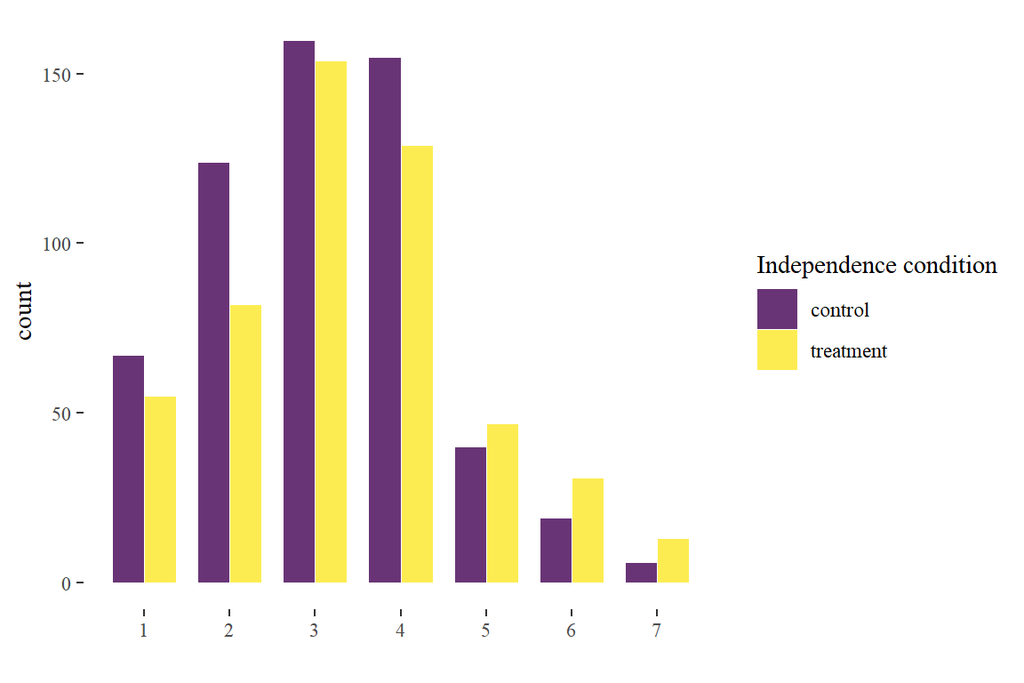

```r
df.def %>%
  ggplot(aes(x = perceived.independence.reversed, fill = experimental.group)) +
  geom_bar(width = 0.75,alpha = 0.8, position = position_dodge()) +
  scale_x_continuous(name="", breaks = 1:7) + scale_fill_manual(name = "Independence condition") +  scale_fill_viridis_d(name = "Independence condition") +
  theme_tufte()
```

## 2.4 T-test

### 2.4.1 With complete dataset

```r
tadaa_t.test(data = df.def, response = perceived.independence.reversed, group = experimental.group, print = "markdown")
```

Table 1: **Welch Two Sample t-test** with alternative hypothesis: $\mu_1 \neq \mu_2$

| Diff | $\mu_1$ control | $\mu_2$ treatment | t | SE | df | $CI_{95\%}$ | p | Cohen's d |
| --- | --- | --- | --- | --- | --- | --- | --- | --- |
| -0.24 | 3.1 | 3.34 | -2.91 | 0.08 | 1036.73 | (-0.41 - -0.08) | < .01 | -0.18 |

### 2.4.2 With those who failed the manipulation check filtered out

```r
tadaa_t.test(data = df.check, response = perceived.independence.reversed, group = experimental.group, print = "markdown")
```

Table 2: **Welch Two Sample t-test** with alternative hypothesis: $\mu_1 \neq \mu_2$

| Diff | $\mu_1$ control | $\mu_2$ treatment | t | SE | df | $CI_{95\%}$ | p | Cohen's d |
| --- | --- | --- | --- | --- | --- | --- | --- | --- |
| -0.39 | 3.09 | 3.49 | -3.53 | 0.11 | 549.67 | (-0.61 - -0.17) | < .001 | -0.28 |

# 3 Time

## 3.1 Survey duration

### 3.1.1 Histogram

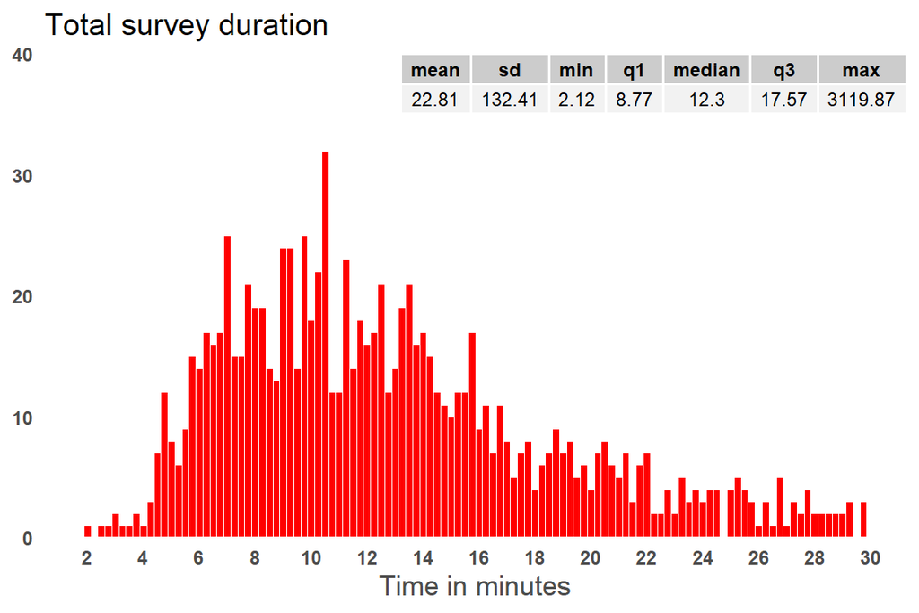

```r
df.def %>% filter(duration < 30) %>%
plot_frq((duration),
        geom.colors = alpha("red",0.8),
        type = "hist",
        geom.size = 0.25) +
  theme(axis.text = element_text(face = "bold",  size= 9)) + labs(title = "Total survey duration") +  scale_x_continuous(name="Time in minutes", breaks = seq(0,30, 2)) +  scale_y_continuous(expand = expansion(c(0, 0.25))) + annotate(geom = "table", x = Inf, y = Inf, label = list(table.duration))
```

### 3.1.2 Relationship between perceived independence and total survey duration

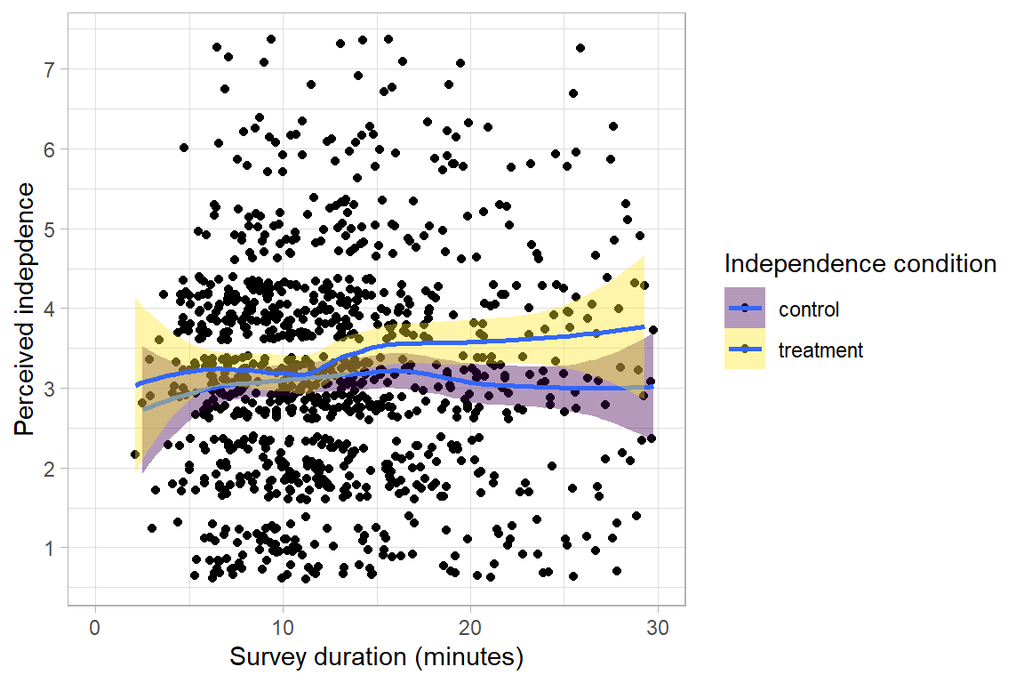

```r
df.def %>% filter(duration < 30) %>% ggplot(aes(duration, perceived.independence.reversed, fill = experimental.group)) + geom_jitter() + geom_smooth() + scale_x_continuous("Survey duration (minutes)", limits = c(0,30)) + scale_y_continuous("Perceived indepdence", breaks = 1:7) + scale_fill_viridis_d(name = "Independence condition") + theme_light()
```

## 3.2 Do participants read the information about the case?

### 3.2.1 Page submission - introduction of case

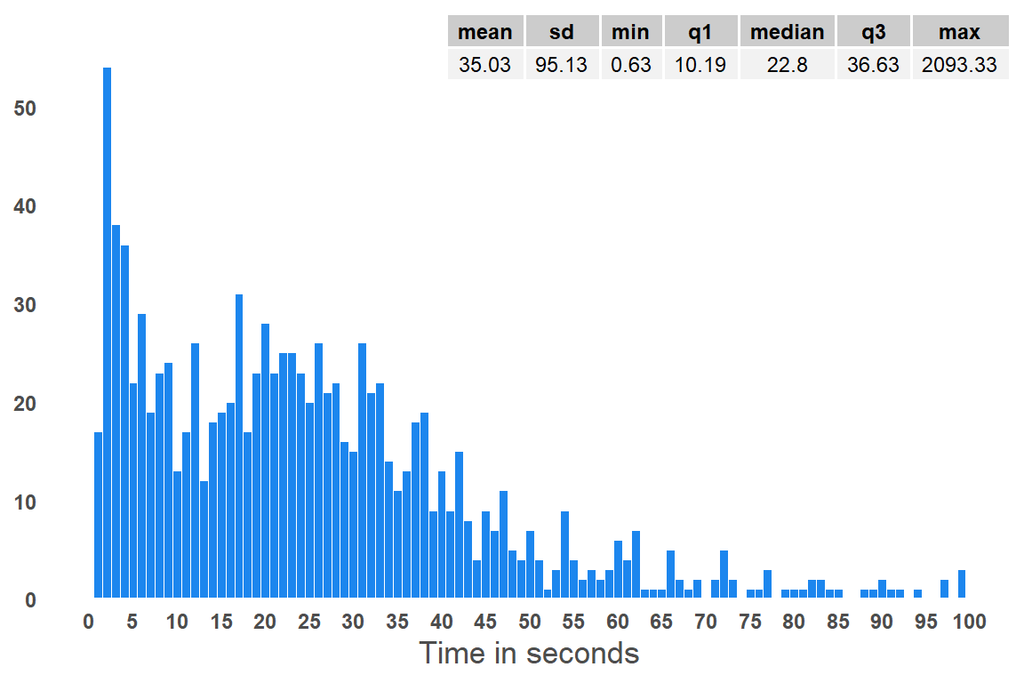

```r
df.def %>% filter(intro.submit < 100) %>%
plot_frq((intro.submit),
        geom.colors = alpha("dodgerblue2",0.8),
        type = "hist",
        geom.size = 1) +
  theme(axis.text = element_text(face = "bold",  size= 9)) +
  scale_x_continuous(name="Time in seconds",breaks = seq(0,100,5)) +   scale_y_continuous(expand = expansion(c(0, 0.1))) + annotate(geom = "table", x = Inf, y = Inf, label = list(table.intro.submit))
```

### 3.2.2 Page submission - manipulation

*Histogram*

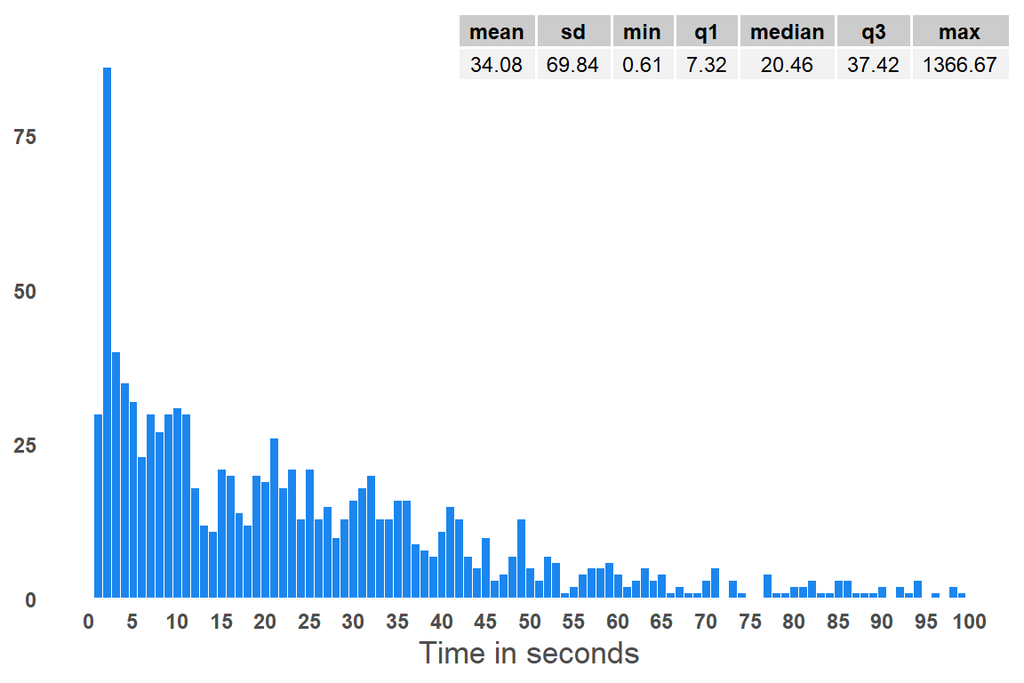

```r
df.def %>% filter(manipulation.submit < 100) %>%
plot_frq((manipulation.submit),
        geom.colors = alpha("dodgerblue2",0.8),
        type = "hist",
        geom.size = 1) +
  theme(axis.text = element_text(face = "bold",  size= 9)) +
  scale_x_continuous(name="Time in seconds",breaks = seq(0,100,5)) +   scale_y_continuous(expand = expansion(c(0, 0.1))) + annotate(geom = "table", x = Inf, y = Inf, label = list(table.manipulation.submit))
```

*Relationship between perceived independence and time spent on the page with the manipulation*

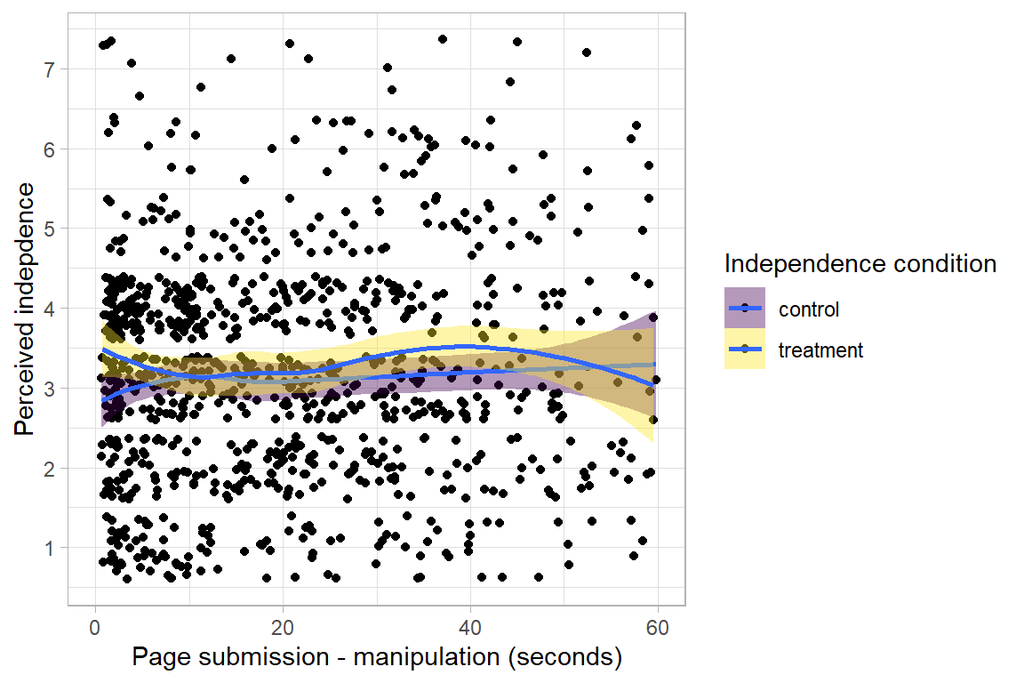

```r
df.def %>% filter(manipulation.submit < 60) %>% ggplot(aes(manipulation.submit, perceived.independence.reversed, fill = experimental.group)) + geom_jitter() + geom_smooth() + scale_x_continuous("Page submission - manipulation (seconds)", limits = c(0,60)) + scale_y_continuous("Perceived indepdence", breaks = 1:7) + scale_fill_viridis_d(name = "Independence condition") + theme_light()
```

*Broken down in quartiles (+ group size and CI)*

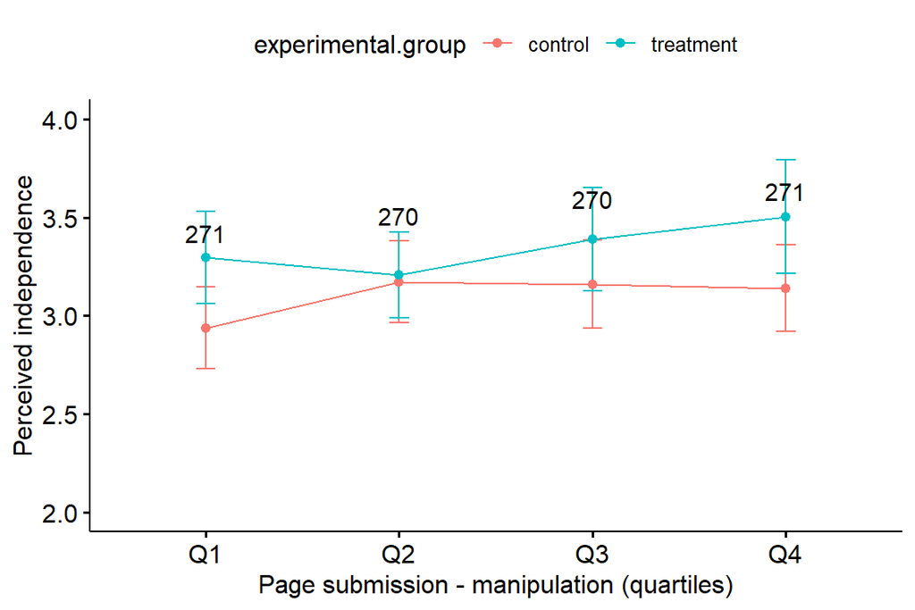

```r
give.n <- function(x){
  return(c(y = mean(x)*1.1, label = length(x)))
}

ggline(df.def, x = "manipulation.submit.quartile", y = "perceived.independence.reversed", color = "experimental.group", ylab = "Perceived independence", xlab = "Page submission - manipulation (quartiles)",  add = "mean_ci", ylim = c(2, 4), yticks.by = 0.5) +
  stat_summary(fun.data = give.n, geom = "text", fun = median, size = 4, col = "black")
```

*Split dataset with 30 seconds as cut-off point (+ group size and CI)*

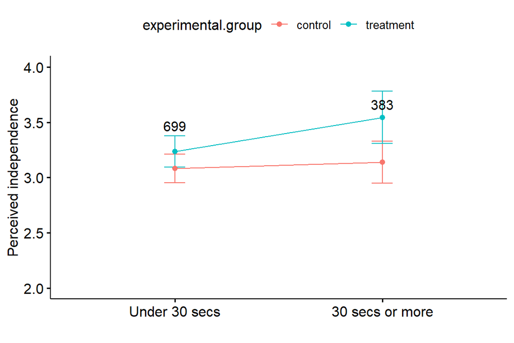

```r
ggline(df.def, x = "manipulation.submit.30", y = "perceived.independence.reversed", color = "experimental.group", ylab = "Perceived independence", xlab = "",  add = "mean_ci", ylim = c(2, 4), yticks.by = 0.5) +
  stat_summary(fun.data = give.n, geom = "text", fun = median, size = 4, col = "black")
```

### 3.2.3 Page submission - EMA’s decision

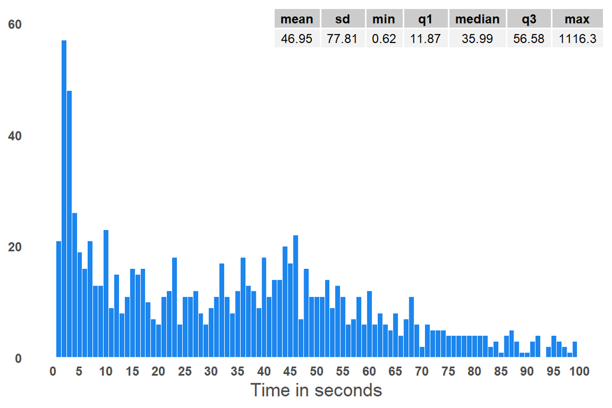

```r
df.def %>% filter(decision.submit < 100) %>%
plot_frq((decision.submit),
        geom.colors = alpha("dodgerblue2",0.8),
        type = "hist",
        geom.size = 1) +
  theme(axis.text = element_text(face = "bold",  size= 9)) +
  scale_x_continuous(name= "Time in seconds", breaks = seq(0,100,5)) +   scale_y_continuous(expand = expansion(c(0, 0.1))) + annotate(geom = "table", x = Inf, y = Inf, label = list(table.decision.submit))
```

### 3.2.4 Time and …

*…Failing the manipulation check*

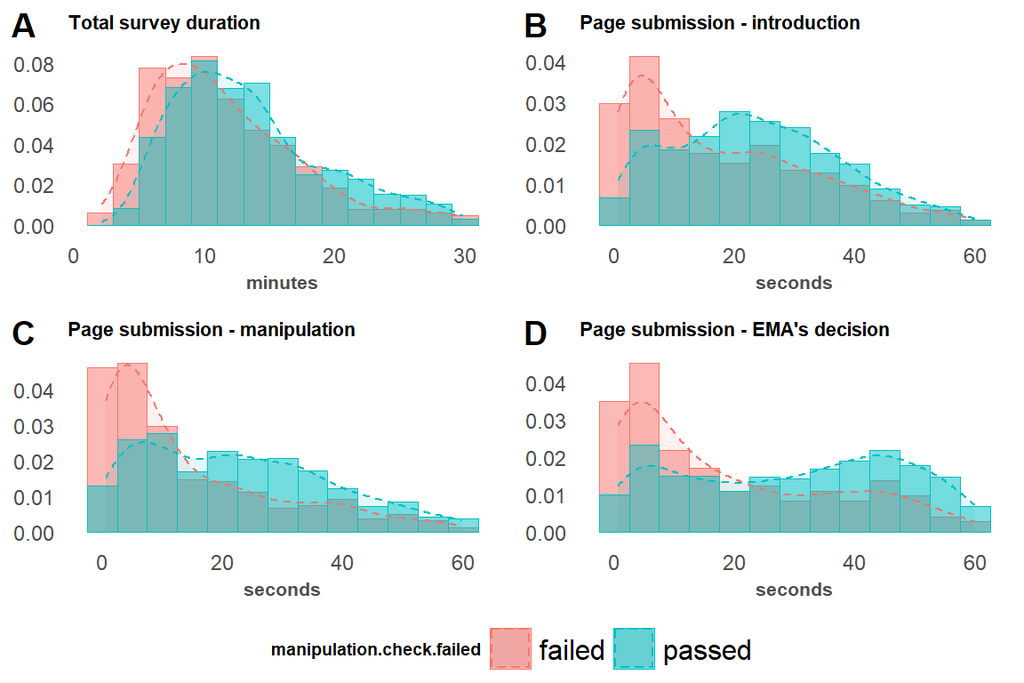

```r
p1 <- df.def %>% filter(duration < 30) %>% ggplot(aes(x= duration, color = manipulation.check.failed, fill = manipulation.check.failed)) + geom_histogram(aes(y=..density..), alpha=0.5, position="identity", binwidth = 2) +
 geom_density(alpha= .1, linetype= "dashed") + labs(title = "Total survey duration", x = "minutes") + theme(axis.title.y = element_blank(), title = element_text(size = 7, face = "bold"),  axis.text = element_text(size = 9))

p2  <- df.def %>% filter(intro.submit < 60) %>% ggplot(aes(x= intro.submit, color = manipulation.check.failed, fill = manipulation.check.failed)) + geom_histogram(aes(y=..density..), alpha=0.5, position="identity", binwidth = 5) +
 geom_density(alpha= .1, linetype= "dashed") + labs(title = "Page submission - introduction", x = "seconds") + theme(axis.title.y = element_blank(), title = element_text(size = 7, face = "bold"),  axis.text = element_text(size = 9))

p3 <- df.def %>% filter(manipulation.submit < 60) %>% ggplot(aes(x=manipulation.submit, color = manipulation.check.failed, fill = manipulation.check.failed)) + geom_histogram(aes(y=..density..), alpha=0.5, position="identity", binwidth = 5) + geom_density(alpha= .1, linetype= "dashed") + labs(title = "Page submission - manipulation", x = "seconds") + theme(axis.title.y = element_blank(), title = element_text(size = 7, face = "bold"),  axis.text = element_text(size = 9))

p4 <- df.def %>% filter(decision.submit < 60) %>% ggplot(aes(x=decision.submit, color =manipulation.check.failed, fill = manipulation.check.failed)) +
 geom_histogram(aes(y=..density..), alpha=0.5, position="identity", binwidth = 5) +
 geom_density(alpha= .1, linetype= "dashed") + labs(title = "Page submission - EMA's decision", x = "seconds", color = "Manipulation Check") + theme(axis.title.y = element_blank(), title = element_text(size = 7, face = "bold"),  axis.text = element_text(size = 9))

ggarrange(p1, p2, p3, p4, nrow = 2, ncol = 2, labels="AUTO", legend = "bottom", common.legend = TRUE)
```

*…experimental groups*

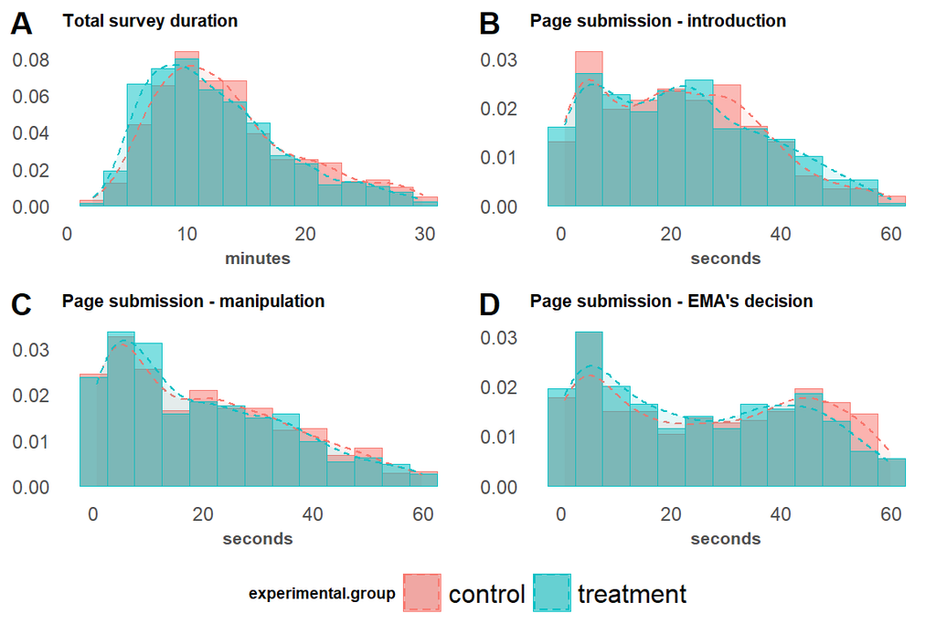

```r
p5 <- df.def %>% filter(duration < 30) %>% ggplot(aes(x= duration, color = experimental.group, fill = experimental.group)) + geom_histogram(aes(y=..density..), alpha=0.5, position="identity", binwidth = 2) +
 geom_density(alpha= .1, linetype= "dashed") + labs(title = "Total survey duration", x = "minutes") + theme(axis.title.y = element_blank(), title = element_text(size = 7, face = "bold"),  axis.text = element_text(size = 9))

p6  <- df.def %>% filter(intro.submit < 60) %>% ggplot(aes(x= intro.submit, color = experimental.group, fill = experimental.group)) + geom_histogram(aes(y=..density..), alpha=0.5, position="identity", binwidth = 5) +
 geom_density(alpha= .1, linetype= "dashed") + labs(title = "Page submission - introduction", x = "seconds") + theme(axis.title.y = element_blank(), title = element_text(size = 7, face = "bold"),  axis.text = element_text(size = 9))

p7 <- df.def %>% filter(manipulation.submit < 60) %>% ggplot(aes(x=manipulation.submit, color = experimental.group, fill = experimental.group)) + geom_histogram(aes(y=..density..), alpha=0.5, position="identity", binwidth = 5) + geom_density(alpha= .1, linetype= "dashed") + labs(title = "Page submission - manipulation", x = "seconds") + theme(axis.title.y = element_blank(), title = element_text(size = 7, face = "bold"),  axis.text = element_text(size = 9))

p8 <- df.def %>% filter(decision.submit < 60) %>% ggplot(aes(x=decision.submit, color = experimental.group, fill = experimental.group)) +
 geom_histogram(aes(y=..density..), alpha=0.5, position="identity", binwidth = 5) +
 geom_density(alpha= .1, linetype= "dashed") + labs(title = "Page submission - EMA's decision", x = "seconds", color = "Manipulation Check") + theme(axis.title.y = element_blank(), title = element_text(size = 7, face = "bold"),  axis.text = element_text(size = 9))

ggarrange(p5, p6, p7, p8, nrow = 2, ncol = 2, labels="AUTO", legend = "bottom", common.legend = TRUE)
```

T-tests (outliers removed - i.e., cases outside 1.5 times the interquartile range):

*Survey duration*

```r
tadaa_t.test(data = out.duration, response = duration, group = experimental.group, print = "markdown")
```

Table 3: **Welch Two Sample t-test** with alternative hypothesis: $\mu_1 \neq \mu_2$

| Diff | $\mu_1$ control | $\mu_2$ treatment | t | SE | df | $CI_{95\%}$ | p | Cohen's d |
| --- | --- | --- | --- | --- | --- | --- | --- | --- |
| 0.94 | 13.37 | 12.43 | 2.55 | 0.37 | 1008.26 | (0.22 - 1.65) | < .05 | 0.16 |

*Page submission - Introduction*

```r
tadaa_t.test(data = out.intro.submit, response = intro.submit, group = experimental.group, print = "markdown")
```

Table 4: **Welch Two Sample t-test** with alternative hypothesis: $\mu_1 \neq \mu_2$

| Diff | $\mu_1$ control | $\mu_2$ treatment | t | SE | df | $CI_{95\%}$ | p | Cohen's d |
| --- | --- | --- | --- | --- | --- | --- | --- | --- |
| -0.26 | 23.21 | 23.47 | -0.25 | 1.04 | 997.62 | (-2.29 - 1.78) | .804 | -0.02 |

*Page submission - manipulation*

```r
tadaa_t.test(data = out.manipulation.submit, response = manipulation.submit, group = experimental.group, print = "markdown")
```

Table 5: **Welch Two Sample t-test** with alternative hypothesis: $\mu_1 \neq \mu_2$

| Diff | $\mu_1$ control | $\mu_2$ treatment | t | SE | df | $CI_{95\%}$ | p | Cohen's d |
| --- | --- | --- | --- | --- | --- | --- | --- | --- |
| -0.16 | 22.24 | 22.4 | -0.14 | 1.18 | 988.6 | (-2.47 - 2.14) | .89 | -0.01 |

*Page submission - decision*

```r
tadaa_t.test(data = out.decision.submit, response = decision.submit, group = experimental.group, print = "markdown")
```

Table 6: **Welch Two Sample t-test** with alternative hypothesis: $\mu_1 \neq \mu_2$

| Diff | $\mu_1$ control | $\mu_2$ treatment | t | SE | df | $CI_{95\%}$ | p | Cohen's d |
| --- | --- | --- | --- | --- | --- | --- | --- | --- |
| 2.87 | 37.76 | 34.89 | 1.64 | 1.75 | 1027.07 | (-0.56 - 6.31) | .101 | 0.1 |

*…interface (pc/mobile)*

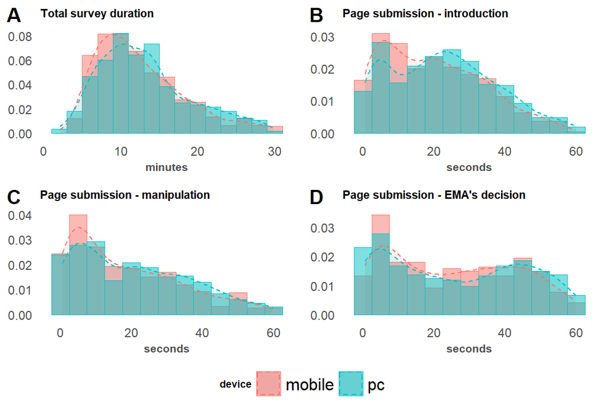

```r
p9 <- df.def %>% filter(duration < 30) %>% ggplot(aes(x= duration, color = device, fill = device)) + geom_histogram(aes(y=..density..), alpha=0.5, position="identity", binwidth = 2) +
 geom_density(alpha= .1, linetype= "dashed") + labs(title = "Total survey duration", x = "minutes") + theme(axis.title.y = element_blank(), title = element_text(size = 7, face = "bold"),  axis.text = element_text(size = 9))

p10 <- df.def %>% filter(intro.submit < 60) %>% ggplot(aes(x= intro.submit, color = device, fill = device)) + geom_histogram(aes(y=..density..), alpha=0.5, position="identity", binwidth = 5) +
 geom_density(alpha= .1, linetype= "dashed") + labs(title = "Page submission - introduction", x = "seconds") + theme(axis.title.y = element_blank(), title = element_text(size = 7, face = "bold"),  axis.text = element_text(size = 9))

p11 <- df.def %>% filter(manipulation.submit < 60) %>% ggplot(aes(x=manipulation.submit, color = device, fill = device)) + geom_histogram(aes(y=..density..), alpha=0.5, position="identity", binwidth = 5) + geom_density(alpha= .1, linetype= "dashed") + labs(title = "Page submission - manipulation", x = "seconds") + theme(axis.title.y = element_blank(), title = element_text(size = 7, face = "bold"),  axis.text = element_text(size = 9))

p12 <- df.def %>% filter(decision.submit < 60) %>% ggplot(aes(x=decision.submit, color = device, fill = device)) +
 geom_histogram(aes(y=..density..), alpha=0.5, position="identity", binwidth = 5) +
 geom_density(alpha= .1, linetype= "dashed") + labs(title = "Page submission - EMA's decision", x = "seconds", color = "Manipulation Check") + theme(axis.title.y = element_blank(), title = element_text(size = 7, face = "bold"),  axis.text = element_text(size = 9))

ggarrange(p9, p10, p11, p12, nrow = 2, ncol = 2, labels="AUTO", legend = "bottom", common.legend = TRUE)
```

# 4 Vaccination intention

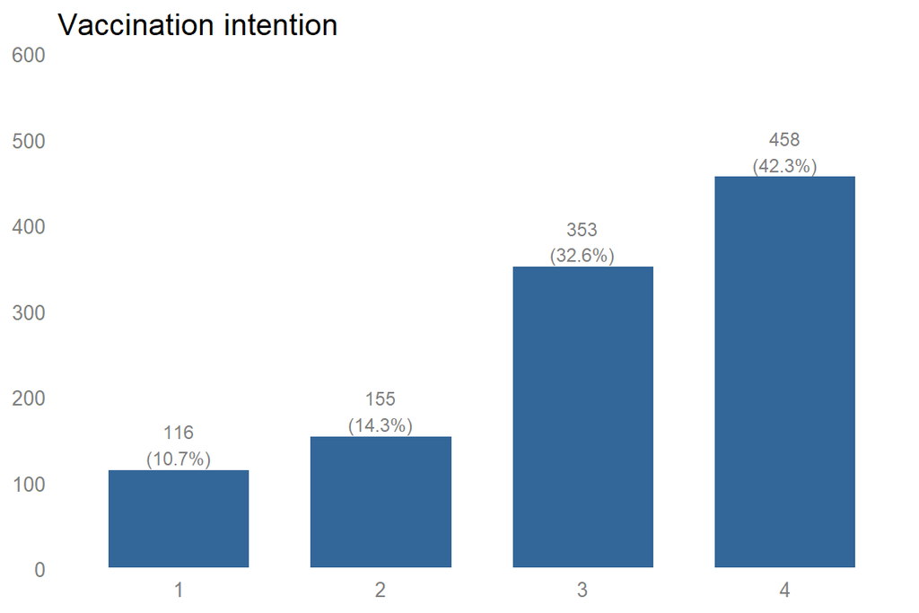

```r
df.def %>%
plot_frq(intent.vaccine,
        title = "Vaccination intention") +
  theme_blank() +
  theme(axis.title  = element_blank())
```

## 4.1 Open question

```r
df.def %>%
  filter(nchar(Q16.3)>1) %>%
  select(Q16.3) %>%
  kable() %>%
  kable_styling(bootstrap_options = "striped", full_width = F) %>%    scroll_box(height = "400px")
```

Q16.3

Vet för lite om vaccinets biverkningar rädd att få bestående men i livet

Alla sanvsar att ta vaccin för att pandemin ska försvinna. Vilken vaccin jag blir erbjuden vet jag ju inte.

Biverkningarna är lite vaga. Skulle vara bra med lite mer forskning

Jag är på en och bra att jag har du har tid att jag

Vet ej vad vaccinet innehåller

för att det är väldigt viktigt. myndigheterna har gjort det tillgängligt för oss för en anledning och vi måste hjälpas åt

Det är en självklarhet att alla ska vaccinera sig tycker jag då det är enda sättet att stoppa viruset

Tycker att alla ska ta vaccin

Det är så jag ser det

Vet inte

Jag vill vara skyddad mot covid 19

Jag anser att det är viktigt

Vaccinet är till för att skydda

Jag kommer vilja ta vaccinet för att skydda mig själv mot viruset men även för att skydda alla människor runt omkring. Bara för att jag inte blir allvarligt sjuk av COVID-19 betyder det inte att folk i min närhet inte blir det. Om man kan så tycker jag man ska ta vaccinet, för allas skull. Annars bidrar man till mer smittspridning anser jag.

Jag har följt media, jag känner ingen oro inför vaccination

Jag tror att det är mycket lögner och saker som sker som undanhålls från oss vanliga människor. Jag litar inte på att det som sägs om biverkningar mm. Jag tror även att det är lögner om covid 19 som skrämmer upp folk att ta vaccin så att läkemedelstillverkarna kan tjäna miljarder.

Jag vill vara frisk och minska risken att få eller smitta någon med covid-19. Jag har fullt förtroende i vaccin och tycker att alla ska vaccineras.

Har allergi och har överreagerat på antibiotika tidigare.

Är multisjuk

Tror och litar på instanser som massvaccinerar, litar på att det är nödvändigt och tror det är för det bästa för allmänheten. Det finns en anledning till varför vi vaccinerar. Vill dock inte vara först att ta vaccin då jag vill vara säker på att biverkningarna är acceptabla för mig och mina sjukdomar.

Vill se eventuella biverkningar

Vill inte ta vaccin alls mot corona

Jag vet att det är säkert. Jag har ingen brådska att få det. Om det blir tillgängligt för mig kommer jag att ta det, främst för att förhindra smitta till andra.

Jag letar på

För att jag tror inte att jag behöver det här vaccinet.

Självklar att ta vaccinet för att slippa denna vedervärdiga sjukdom

Jag tror starkt på vaccinering mot sjukdomar

Jag vill kunna arbeta som vanligt, kunna umgås med familj och vänner igen. Har inte träffat mina föräldrar eller morföräldrar på över 1 år. Om livet ska kunna återgå till något sånär normalläge så kommer vi att behöva vaccinera merparten av befolkningen

Vill ha ett skydd mot Corona

Jag tror att vaccinet skyddar mig från att drabbas av Coronaviruset.

när jag får tillgång så är corona inte så allvarligt

Jag litar på dem

Det är viktigt att minska smittspridningen, även fast jag är osäker på vaccinet fortfarande så kan jag inte säga att det finns ett annat val. Om det är nått vaccin jag förmodligen skulle ta så skulle det vara den kinesiska. Sägs vara mildare och att tom. barn kan ta dem. Men vill inte ta Astra Zeneca om jag kan undvika det. Helst de ovannämnda.

Det beror på vilket vaccin som finns tillgängliga

Vet ej

Jag tycker inte att den är säker

Litat på vaccinet.

Vill kunna resa utomlands

P.g.a. nästkommande yrke, vilket är inom vård och omsorg

Det ger viss skydd mot corona tro jag

Betroende på vad det bekämpar, för att få bort virus skulle jag gjort det för min egna och min samhällets riskgrupps skull

Vet inte om biverkningarna förän efteråt. Känns som vaccinet har stressat fram.

Jag vill skydda mig och andra från smittan.

Jag kommer att ta det vaccin som erbjuds mig vid allmän vaccinering.

Jag anser att vid ett utvecklat vaccin så har de med ändå rätt bra marginaler inte bara kastat ut ett vaccin i förhoppning att det kanske blir godkänt. Jag har svårt att tänka mig att detta vaccin skulle godkännas i eu om det inte fanns misstankar om ett “hopp” för mänskligheten att få corona ur världen. Sedan kan man fundera hur britterna tänker att påbörja vaccinering innan till exempel eu har godkänt vaccinet….?

Viktigt att man vaccinera sig och tar gärna det

Jämfört med svininfluensan så har det här visat sig vara ett reellt hot.

Jag vill börja LEVA igen. Träffa mitt senaste, snart ett gamla barnbarn. Kinna gå ut och äta, resa, träffa vänner

Det känns inte säkert.

Jag vaccinerar mig för att stoppa smittan

Har redan tagit dwt

Litar på att vaccinet är noga testat

Därför jag är mycket känsligt mot många saker och jag ska vara försiktigt att använda nya saker.

Jag kommer att ta det vaccin jag erbjuds.

Jag litar för dem for att dem vet vad gör

Jag litar på att det ger ett bra skydd med få biverkningar. Det är alltså bättre att ta vaccinet än att inte göra det

Vi behöver hjälpas åt att bli av med sjukdomen

Beroende på vad myndigheter i landet går ut med för angående vaccinet. Kommer ta vaccin om myndighet anser det lämpligt

Vill både skydda mig själv o andra genom att vaccinera mig

Om jag är i risk-gruppen då så kan jag ta det. Har astma sen 10 år tillbaks men är för ung för att vara i risk-grupp,sägs der

Det känns mer säkert än osäkert att skydda sig med detta

Man har inte långtidseffekten av vaccinet eftersom den är ny, så tex neurologiska skador kan synas efter några år

Varför inte?

95% sannolikt skydd, känns tryggare än inget vaccin alls.

Osäker på om jag vill vaccinera mig

Fortfarande osäker på biverkningarna

Litar ej på vaccin.

Alla behöver vaccineras för att kunna stoppa pandemin och för att vi ska kunna leva så normalt som det går igen

Därför det är utvärderat o godkänt och känns säkert

Jag är rädd att bli sjuk i covid 19. Jag vill ha ett skydd.

Vaccin gör mer framtida skada än nytta. Jag tvingade min dotter ta vaccin mot svininfluensan och hon drabbades av nån sömnsjukdom. 3 år av hennes liv sov hon mer än hon var vaken och än idag har hon stora svårigheter.

Litar på forskning.

För att skydda mig mot covid 19

Har förmodligen ingen möjlighet att välja vaccin. Får den man får.

Många som tagit vaccinet och fått stora bi effekter eller ändå blivit drabbade av covid trots de tagit vaccin

Jag tror att det är säkert och att biverkningarna är milda

Det känns som en plikt gämtimot mina medmänniskor

Solidaritet och samhällsansvar

Jag kommer att ta vaccinet för att skydda mig och andra.

För att riskerna med att spruta in ny teknologi i min friska kropp är större än riskerna med COVID.

Jag vill inte vaccinera mig.

Jag är inte i riskzon och är i själv karantän så jag vill att vaccin prioriteras för människor som fortfarande måste leva socialt/människor i riskzon.

Vill bli vaccinerad så snart som möjligt. Litar på att rdna vaccin är säkert och ger få allvarliga biverkningar.

Jag är skeptiskt till vaccin i överlag och det känns framstressat när det är ett vaccin som verkligen måste bli klart på så kort tid som möjligt

Vill ha ett skydd.

Om inga biverkningar dyker upp

Inget eller ingen kan bevisa att den är helt igenom tänkt

Än så länge verkar det vara ett säkert vaccin att ta

Efter vad man kunnat se hittills har detta vaccin få och huvudsakligen lindriga biverkningar och tycks vara effektivt åtminstone i det korta perspektivet.

Eftersom jag är i riskgruppen 70+ så vill jag inte sitt i karantän länge till. Livet är för kort för att sitta inom fyra väggar. Vara rädd så fort man möter folk på gatan och handla mat klockan 6 på morgonen.

Fortfarande rädd för biverkningar längre fram i tiden

Rädd för biverkningar, så som vid svininfluensan

Självklart

Jag litar fullständigt på läkemedlet både vad gäller att det är verksamt och att biverkningarna är mycket måttliga

För att skydda mig själv och andra i min närhet

Jag tror att vaccinet är testat o godkänts på säkra grunder

Jag arbetar som personlig assistent och med vaccinering minskar jag risken att smitta min brukare radikalt. Utöver det vill jag göra vad jag kan för att vi ska bli kvitt pandemin.

Jag vet inte vad som kommer hända efter sprutan.

Mår bra

Det finns andra som behöver det ner än jag. När alla riskgrupper är vaccinerade är jag villig att ta det själv

Är ännu osäker på om jag ska ta det eller inte

Vaccinen tagits fram väldigt snabbt. Osäkert om den ge skydd. Och möjliga biverkningar

Vill inte bli smittad igen

Jag vill ta mitt ansvar som medborgare och skydda mig själv och andra.

Viltigt att ta vaccin

Det är vad jag tror.

Kanske blir tvungen.

Jag är orolig för biverkningar.

Jag vill ha det första tillgängliga vaccinet som erbjuds mig, oavsett vilket företag som levererat det.

Jag tror på vaccinet och vill bli skyddad från covid-19

Jag är positiv till vaccinet

Man vill ta vaccinera sig så fot det går för då kan man möta sina nära och kära

Var på provtagning imorse. Då pratade jag med sköterskan. Hon sa att Astra zenica att deras vaccin kanske inte skulle funka på 65 +are. Då behöver ju Sverige “titta efter” andra vaccintillverkare.

För kort tid för forskning, vill inte vara någon försökskanin

Viktigt

Jag vill avstå från vaccin

Vill inte ha inkonstigheter o mrna i min kropp

Vill nog inte bli vaccinerad

Pga den helt nya teknologin o formulan som aldrig prövats förut där man går in på protein/cell nivå och förändrar i kroppen känner jag mig inte säker och vill inte stå först i kön som försökskanin. Med tanke på hur tidigare vaccin förändrat folks liv med narkolepsi och andra hemska bieffekter så sitter jag hellre isolerad och fullt frisk än låter mig sprutas med ett oprövat vaccin. Med det menar jag att vi har ingen aning om de långsiktiga bieffekterna. Därför vill jag inte vara först. På filmade videor där läkare öppet får vaccinet ser man att det är en show och att inget medel sprutas in i läkarens kropp. Det får en att undra varför.

Jag vill ha mindre chans att dö i sjukdom

Troligtvis måste man ta det som erbjuds när den dagen kommer. Jag tror inte man får välja

allergisk pencelin

Vill ha ett bra skydd för covid 19

Känner att det är pålitligt och jag vill snabbt bli skyddad

Vill ha min frihet tillbaka

Ingen som vet biverkningarna än… det framkallades för fort

Detta för att jag jobba inom vården och önskar att varken smitta patienter eller mig själv. Vill dessutom kunna vistas utomhus alltmer utan att känna skräck för Corona.

Lite osäker men antar det är bäst, avvaktar dock gärna lite

För att inte kunna sprida viruset vidare och få ett slut på denna pandemi

Trygghet för mig och de jag jobbar med. Jobbar på demensboende. Det är mycket jobbigt att använda både visir och munskydd på jobbet de gamla här inte vad man säger, de vill gärna kramas men svårt med alla skydd

För att jag tänker att resa i december så jag måste tar vaccin innan.

Behöver jag den ja det gör jag för att jag måste ha den vill inte få corona

Jag är inte säkert om konsistens och de vet inte vad det ska hända för värjer person som ska vaccinera sig

Det är viktigt att ta ansvar för sig själv och göra vad man kan som individ för att stoppa pandemin

Litar inte på vaccinet

För att risken finns att jag kommer få bistående men som kommer sitta kvar resten av livet och jag sitter inte i riskgruppen som viruset anses farligt för

Svarat ärligt.. fast mycket om EU hade jag aldrig hört talas om.

Om vi någonsin ska kunna gå tillbaka till det normala, åtminstone till så stor del som möjligt är det viktigt att alla följer folkhälsomyndigheternas restriktioner och tar covid-vaccinet för att kunna uppnå en slags folkimunitet. Så länge vaccinet visar sig ha en positiv effekt och det inte finns något annat alternativ, kommer jag att ta vaccinet.

För jag litar på forskarna och tycker att det är väldigt viktigt att vara skyddad. Främst för många i min familj är i riskgrupper men även för jag vill kunna röra mig fritt igen.

Litar inte på det, för mycket biverkningar

Jag har aldrig tagit vaccin mot någon typ av virus så jag är inte säker på detta heller

Rädd för biverkningar

Är relativt kritisk till nya vaccin och är inte själv i någon riskgrupp.

Jag vill slippa få Covid-19 samt minimera riskerna för ökad smittspridning.

Jag tar det vaccin som finns tillgängligt när det bli aktuellt

Vet ej

Jag är i riskzonen, därför riskerar jag också ev biverkningar

Jag känner att jag har ett ansvar att göra vad jag kan för att skydda mig och andra

För att ett eventuellt måste för ett sk vaccinpass

Vågar inte lita på de långsiktiga följderna. Det förekommer ingen som helst debatt mellan vaccinförespråkare och vaccintvivlare, vilket är mycket olyckligt. Varför?

Rädd för biverkningar

Har tillräckligt förtroende för framtagning av vaccinet och behöver det

Litar inte på vaccinet

Om det kommer fram allvarliga biverkningar när fler o fler vaccineras kommer jag att avstå.

Det är ett godkänt vaccin och det är viktigt att vaccinera sig.

För att det är viktigt då jag är i en riskgrupp.

För att jag vill heldre ha dessa milda biverkningar än Covid-19.

För att vaccin generellt är säkra, för att skydda mig själv och för att bidra till att pandemin försvinner

Innehåller inget jag är emot

Jag vill se först om de i min omgivning får några svåra biverkningar

För att jag vet inte riktigt

Jag tänker vänta och se på eventuella biverkningar innan jag gör det! Så i framtiden kanske.

Jag tror på forskningen, det är bättre att ta ett vaccin än att inte göra det

Det lanserades alldeles för snabbt och jag tror att det inte är tillräckligt bra

Jag är över 18 år, bor i Sverige, har astma och den informationen jag fått är att alla över 18 troligen kommer fått möjlighet att vaccinera sig till sommaren. Jag vet att jag är i en av dem sista grupperna. Det viktigaste med ett vaccin är att det kan rädda andra och ibtr vara mig själv men en god effekt får vi först när många har tagit det. Det är Pfizer, moderna och troligen Astra zenecas vaccin som kommer till oss vad jag vet

Jag litar på att myndigheten har gjort ett bra jobb

Är osäker på att det kommer att skydda

nytta för samhället

Jag vill ta vaccin från Pfizers och/eller BioNTechs vaccin för att samhällets säkerhet såhär som min säkerhet skulle förbättra läget

Viktigt

Inte tillräckligt testat. Det kan ge mig allvarliga kroppskador.

Tror det kan föra med sig enbart, positiva resultat.

känner inte till

Jag är orolig för att ta vaccinet, på grund av eventuella följder av det, men jag förstår också att det nog krävs att hela vår befolkning ska ta det om vi alla ska bli immuna

Om jag har ett val skulle jag välja modena eftersom det bevisades att de är effektiva för alla Covid former

Jag vet faktiskt inte jag är osäker på vaccinet men vågar ändå inte INTE vaccinera mig. Har

för att jag vet inte vilka biverknibgar eller framtida skafor den kan göra. När tillräckligt många har vaccineras utan risk då kan man fundera på det. Man måste vara försiktig med vad man tar och hur säkert ät det egentligen

Försiktig

För att minska risken för dom sjuka och utsatta

Fördelarna större än nackdelarna

Jag vill skydda mig själv och andra från coronavirus.

För att skydda mig mot covid 19

Jag är osäker

För att kunna skydda mig från covid

Det är ju tvunget att vaccinera sig om man vill ha ett normalt liv. Diskussionerna om en gräddfil för resande som är vaccinerade inom eu är ju avgörande. Detta är givetvis helt emot principen om fri rörlighet och inkräktar på individens frihet. Med tanke på den utbredda korruptionen inom euländerna är detta så klart frampressat av giriga eu-politiker och storföretag inom farmaindustrin.

Även om den inte är effektiv till 95 % så är den iallafall bromsande för pandemin. Känns som man måste lita på vaccinen även fast det gick otroligt fort att ta fram. Vad har man för alternativ? Sitta hemma och vara orolig?

Jag kommer ta vaccinet men bland de sista. Vill se om det finns komplikationer. Då det gick nästan för fort att ta fram vaccinet.

I respekt till mina anhöriga och andra med lågt immunförsvar.

Jag har tagit många vacciner i mitt liv. För mig är det självklart med tanke på min och mina medmänniskors hälsa.

Är lite rädd för vaccin som är så nya, när jag inte vet långsiktigta biverkningar.

I dagsläget känns det obefogat.

Är emot vaccin överhuvudtaget! Så jag kommer inte att ta det!

Jag har redan fått första dosen

För att biverkningar

Vill vara skyddad

Verkar ha bra motstånd

Jag vill ha vaccin så fort som möjligt oberoende av vilket av de godkända erbjuds

Vi måste få stopp på smittan och komma tillbaka till ett normalt liv.

Förmodligen kommer jag inte att ha något val. Man kommer bli begränsad i det man kan göra om man inte tar vaccin.

Tillhör ej någon riskgrupp. Vilket innebär att Covid inte är farligate än vanlig influensa för mig.

Känner mig för osäker på biverkningar

Det är bäst

Jag är 76 år och vill skydda mig.

För att jag tycker det är var persons ansvar att ta vaccin inte bara för att skydda sig själv utan andra

Jag tror på vetenskap och vill skydda mig från sjukdomen

För att jag är trött på pandemin och alla restriktioner som den medför. Jag vill leva ett normalt liv utan social distansiering.

Jag vill så snart som möjligt gå tillbaka till ett normalt liv.

Vet för lite om bieffekter än

Jag har tyvärr ingen möjlighet att åka till Ryssland för att ta Sputnik V, så i bästa fall måste jag vaccineras här, trots att ryska vaccinet gjort på den mänskliga adenovirus och Europas vaccin på apans.

För att om möjligt minska spridningen av covid

Fördelar överväger nackdelar

Ett vaccin att lita på

Jag är ingen vaccinmotståndare. Det känns mer säkert än osäkert. Jag tillhör dock ingen riskgrupp och det känns inte akut/brådskande för mig att ta det.

De stämde mest med mina svar

Vad finns det för val

Jag vet inget om biverkningar

För om jag får möjligheten kommer jag ta det

Jag tycker att det är allas skyldighet att vaccinera sig mot Corona så länge man kan och får

Jag har haft covid och är inte i någon riskgrupp så det är inte någon brådska för mig att variera mig än, men så småningom

Självklart ska jag ta vaccinet så fort det finns tillgängligt för mig eftersom att det är det enda sättet att stoppa denna pandemi och rädda liv.

Tar alltid vaccin när det behövs

Det endavaccin som finns i större mängd

Jag kommer att få vaccinet bland dom sista, hinner se om biverkningar utöver milda rapporteras in med tiden… Men om vaccinet ska göra nytta behöver dom flesta som kan vaccineras tänker jag…

Kommer förmodligen inte att ha ork för att fixa det

Jag vill inte ha den

Gravid

För att öka chanserna till ett normalt samhälle

Ogillar vaccination

Är där för sprutor och vacciner

För äldre släktingas säkerhet

Vill veta mer om ev biverkningar

För att stoppa spridningen så alla nära och kära blir säkra. Och att rädda liv.

Vaccin bidrar till minskad smittspridningen vilket jag tycler är viktigt

Pga forskningen och de grunder som de har.

Jag vill bli skyddad från covidsmittan

Jag vill vaccinera mig

…

Vet inte vilket vaccin som kommer dit jag bor

Jag tycker att det är viktigt att ta upp den saken

Jag tänker vaccinera mig för att skydda både mig själv och andra mot covid-19.

Jag är 69 år och vill skydda mig mot covid19

Jag ska göra min bättre .

Är osäker på vad jag får i mig

Självklart

Har inte mycket förtroende för myndigheter och politiker när det handlar om pengar. Man får inte tjäna pengar på människor

Osäker på att överhuvudtaget ta vaccin

Litar inte på det.

Hellre vara skyddad än oskydda.

Jag hade en pers med svininfluensan, när den gick. Det var hemskt. Covid 19, är ju avsevärt värre. Jag gör allt, för att undvika Covid.

Är rädd för att vaccinera mug

Längtar efter vaccinet! Ser fram emot ett annat liv…

Det vaccin sverige erbjuder mig så tar jag det. Jag litar på svenska myndigheter

Jag tror inte på massprodicerat panik vaccin. De gamla hederliga vaccinet som man tar enligt vaccinprogrammet tror jag mycket mer på. Detta nya är inte tillräckligt testat för att veta vad som händer om ex 2år

Jag har redan tagit vaccinet. Arbetar inom vård och omsorg. Vill skydda både mig själv och brukare från att smittas

Jag tror på vetenskaplig forskning

Vill ej vaccinera mig

För o skydda min omkrets familj som är i riskzon inklusive jag o 2 barn

Alla måste ta

Jag känner att allt händer lite för fort och lite inte så mycket på vaccinet

Tror på detta.

Man måste hjälpa varandra i samhället

Jag tycker det är viktigt att alla som har möjlighet vaccinerar sig. Dels för att skydda de som inte kan ta vaccinet och dels för att vi ska kunna återgå till ett vanligt liv

Det är ett internationellt och välkänt företag som många litar på. De använder den senaste teknologin.

Är ej säker på biverkningar

Viktigt att överväga ta det

Rädd för att bli smittad och svårt sjuk om jag inte tar vaccinet.

Osäker på vaccinet,det är alltid en risk att ta vaccin. Speciellt efter vaccinet mot svininfluensa.

Pålitligt

När det är min tur så är det ganska många människor som har fått det före mig, så man har mer kunskap om biverkningar.

Jag vill inte ta vaccinet förrän jag vet om biverkningar och dessutom är det inte ens säkert att jag får ta vaccinet

Jag vill inte ta vaccin. Hoppas jag får vara frisk.

Jag litar på att vaccinet är framtaget på ett vetenskapligt korrekt sätt även om det varit kort om tid

Jag vill inte vaccinera mig oavsett vaccin

På grund hur illa behandlad jag blivit hela mitt liv. Fick inte ens åka på min egen kära mammas begravning år 2020

Jag vill ha mer faktabaserad information om utfallet av hittills gjorda vaccinationer. Jag är dock mer positivt än negativt inställd till vaccinationerna

Krävs mer forskning om vaccinet

Vaccin är bra

Känns osäkert med ett vaccin som är så nytt och obeprövat.

Pga negativa konsekvenser för andra vaccin så vågar jag inte vara en av de första med att ta nya vaccin. Jag vill se eventuella biverkningar först

Om jag blir erbjuden att vaccinera mig så är det sannolikt att jag gör f a.

För oprövat

vaccin räddar liv

Innehåller aluminium bla, vaccinet framtaget alldeles för fort

Tvivlar på effekt samt osäker angående biverkningar

Jag litar inte på test produkter

Jag tycker att det är viktigt att vaccinera mig. Både för mig själv min familj och mina medmänniskor. Jag tror att vi behöver detta vaccin för att kunna fortsätta att leva normalt igen.

Jag vill ta vaccin oavsett vilken som har tillverkat det bara jag vet att det inte är för många biverkningar

Passar min åldersgrupp

Jag måste för jag jobbar med covidpatienter.

Eftersom jag tillhör den sk riskgruppen. Om jag skulle insjukna i covid 19 så skulle jag förmodligen bli mycket svårt sjuk pga mitt hälsotillstånd. Dessutom så litar jag på att vaccinets godkännande är taget efter lämplig research.

Bra skydd

Vad är alternativet när man är 70+

Har tagit vaccinet idag, för att få stopp på pandemin

Arbetar inom vården och har ju nu specialuppdraget som Egentestansvarig på kommunens drive-inverksamhet för kommunanställda. Jag har hittills klarar mig från covid och vill göra det jag kan för att inte få det då jag är immunsuprimerad reumatiker som behandlas med biologiska läkemedel.

Detta är osannolikt då det kan finnas många biverkningar som kan vara värre än det man vaccinerar sig mot som inte framkommit

Jag vill vara skyddad mod corona, och jag vill vara säker på att inte smitta vidare

Jag har inte tagit något mer än de vaccin man fick som barn. Inget svin- eller ”vanligt” influensavaccin. Jag anser att vi människor har oss själva att skylla för att dessa virus över huvud taget sprida bland oss. Vi lär oss tydligen aldrig av våra misstag!

Är inte helt säker

Så många beslur av människor med makt visar sig i efterhand ha drivits av olika intressen. Makt korrumperar.

Jag tror att vaccin är bra och gör nytta om alla tar de

Det verkar väl utprovat

Förhoppningsvis kommer vaccinet hjälpa och därmed kommer smittan sluta spridas.

Vill inte bli sjuk

Är ett vaccin som jag behöver ta

Orolig för biverkningar

Pandemin som måste stoppas oavsett vad

Känner inte att mitt personliga behov av vaccin är tillräckligt dtort

Chans

Bra rykten

Jobbar inom vården, för att skydda mej och mina medmänniskor

Bra fråga

Vet inte

Viktigt att vaccineras så är det godkänt litar jag på det

Deras vaccin må vara effektivt, men det är ju trots allt EU som godkänt. Jag har ju stora förhoppningar’

Alla måste ta vaccinet

Inte bestämt än huruvida jag ska ta det eller ej.

Kommer att ta vaccinet enbart för andras skulle.. Om det endast gällde mig själv så skulle jag avstå..

För att få slut någon gång på viruset,så tror jag att det är lämpligast att vaccinera sig, Men väntar på att det inte är några besvärliga biverkningar.Eftersom vaccinen tillverkades så snabbt så tror jag inte på 100%..

Pga att jag haft många allergiska reaktioner mot läkemedel och pga att jag tycker vacccinet tagits fram för snabbt. Jag litar inte på att det inte kan finnas biverkningr som kan vara allvarliga.

Ser inget skäl till det. Jag ger hellre bort den möjligheten till folk som det bättre.

Ja eventuellt

Vill skydda min hälsa

För att få stopp på spridningen

Jag har inget annat val eftersom jag tillhör riskgruppen.

Jag tycker alla ska vaccinera sig så även jag

Är rädd

Tycker det verkar vara ett bra vaccin

Jag litar på att vaccinet fungerar

Det är viktigt att bli vaccinerad.

Har väldigt lågt förtroende för ett vaccin som så snabbt kommit ut på marknaden, det är alldeles för mycket pengar inblandade. Dessutom litar jag inte på att medierna i Sverige kommer informera om biverkningar.

Osäkerhet

Jag är i riskgrupp och 70+ och känner mig desperat i min isolering. Dock bekymrad över allt negativt som vissa medier skriver om vad som en del har råkat ut för i och med vaccineringen

Alla ska väl helst ta vaccinet.lika bra att göra det.

tycker det är så viktigt att ta pga att sänka smittspridning och skydda varandra

Jag tror det är det bästa alternativet. Absolut inget vaccin från Ryssland eller Kina

Jag tror att de inte är pålitliga. Du suite dum behöver jag ingen vaccin

Vill inte pga biverkningar man kanske blir sjuk man vet ju ingeting om detta vaccin

Vaccin är bra men jag är inte i riskgrupp

Är för och är emot. Biverkningarna är olika för olika människor

Det har genomförts grundläggande tester

Jag vet ej

Om det inte finns något annat att välja på så vill man ju vaccineras

Redan fått första sprutan

Känns inte säkert för tillfälligt

Behöver inte

Trovärdighet säkerhet och minskning av spridning

Vill inte riskera min hälsa med vaccin som ej testats förut pga risken gör allvarliga biverkningar.

Jag behöver det.

Om jag behöver ta vaccinet för samhällets säkerhet är det mycket sannolikt att jag gör det men risk grupper går först

På grund av mentala problem har jag svårt för folk och jag känner inte behovet av att ta vaccinet då jag pluggar hemifrån och träffar sällan andra.

Jag tar vaccin för att inte bli sjuk i covid. Andra vaccin jag tagit har fungerat och därför tror jag att det här vaccinet också fungerar.

Vill söka egen information först

För att jag litar på deras vaccin

Trots ett stort antal spekulanter och spridning av ”källor” som säger att vaccinet inte är pålitligt, väljer jag att svara sannolikt på frågan eftersom de stora studier som genomförts på vaccinet inte visat på någon direkt fara.

Att skydda mig så jag slipper bli sjuk i coronan

Jag har tagit alla vacciner som ingår i ens ungdom, jag är även vaccinerad mot TBE och har inget problem med vaccin och litar på att det funkar så som de kunniga säger och vill vara skyddad.

Vet ej

Om säkerheten är så stor finns inget annat alternativ tror att det är säkert

För att skydda mig mot corona

Har inte bestämt mig än det vet jag om 6 månader

För att jag tycker att det är viktigt att inte smitta andra även om jag som ung inte kommer bli svårt sjuk

Biverkningar

Kanske kommer att ta den om det är säkert

Jag har vaccinerat mig själv och mina barn med de vacciner som är länge beprövade och bevisade. Jag tycker covid vaccinet är allt förhastat.

Påskyndat vaccin, vill se om det rapporteras vi effekter

Jag litar fullständigt på detta vaccin.

Tycker det är allas plikt att vaccinera sig för att stoppa spridningen.

Jag hoppas verkligen på att vaccinet kan rädda många människor och om det händer att vissa dör av det så kan det fortfarande vara bättre än om vi inte skulle ha vaccinet då mycket fler skulle dö.

Jag har svarat utifrån vad jag skälv tycker och tänker

Kan inte lita

Båda är börsnoterade företag.

Fungerar det som alla andra vaccin så tar jag gärna något som är gjort i Europa.

Jag vill minska smittan i samhället

Eventuellt biverkningar

Det kommer förenkla min vardag och släppa all stress

Jag vill väntar till många tar vaccinet och vad som händer med de

Jag tror inte jag kommer att ta något vaccin mot covid-19 till att börja med. Jag vill vänta och se vad som händer med de som tagit det

Ingen specifik anledning

Är räd för alvariga biverkningar

Känns inte säkert, snabbt framtaget

Egentligen kvittar det vem som framställt vaccinet, så länge det är godkäntska vaccinera mig mot covid så fort det är möjligt

Hög effektivitet, det är självklart intressant när det blir dags att få vaccin

De har inte gjort tillräckligt studier

Pga bieffekter av tidigare vaccin

I Sverige är det så vitt jag Astra-seneca som anlitas.

Vill att coronan tar slut någon gång o då bör alla ta vaccinet men förstår att alla inte kommer att göra det o då kommer det ta längre tid ,har ej vart alltför positiv till vacciner förr men ändrat mig en hel del

Är alldeles för nytt. Är rädd för biverkningar. Anser att om jag inte fått Covid -19 än så när jag klara mig. Jag är inte i nån riskgrupp.

Det känns som det har studerats noga och känns som ett säkert vaccin. Bra att det sägs skydda så mycket som 95 %

Jag jobbar inom vården och har redan hade Covid-19 i våras. Var sjukskriven i fem(!) veckor. En kollega till mig har precis blivit sjuk en andra gång i Covid trots att hen hade antikroppar.

Alla måste hjälpas åt för att sätta stopp för pandemin

Känns ändå som en trygghet. Det är många som får vaccinet före mig så det ger en viss trygghet hur det fungerar.

Jag är emot att spruta in okända preparat i min kropp, dessutom har jag haft covid-19 två gånger på ett år.

Anser att det är viktigt att vaccinera sig för att bromsa pandemin, men känner en osäkerhet kring risk för biverkningar

Viktigt att alla som får erbjudande att ta det gör det!

Det är viktigt att vaccinera sig

Jag har redan fått den första dosen och jag ville ha vaccinet för att jag vill få slut på pandemin

Det enda riktiga sättet att få bukt med en pandemi är att bekämpa den med vaccinering av befolkningen

Dåligt påverkan

Jobbar son undersköterska och ganska utsatt och jobbar med äldre

Jag är öppen för vaccinationer. Jag är tacksam att duktiga företag kan rädda mänskligheten.

Litar inte helt på det

Jag litar på myndigheterna och vetenskapen

Vi vet inte de långsiktiga biverkningarna.

Av solidaritet med medmänniskor.

Hastigt framtaget. Mycket som vi “vanliga” människor inte vet om vad som händer “bakom kulisserna”. Tror att det är osäkert vilka bi-effekter vaccinet har. Vill inte vara en försökskanin. Håller mig hellre isolerad.

För ja tycker de är viktigt att skydda sig själv och andra

Jag ligger i riskzonen +70 plus underliggande sjukdomar

Vill kunna göra saker som man kunde före covid-19, litar på att det är kontrollerat, inte bara för mig utan för att alla i riskgrupp och de som inte kan ta vaccin ska minska risken att smittas då andra tar vaccin

Jag har haft covid , i slutet av mars va sjuk i 3 veckor men inget allvarligt , jag anser att jag inte hade vunnit så mycket på att ta vaccinet, men hade jag varit i en risk grupp hade jag haft en annan åsikt

Vaccin verkar vara det enda sätt att stoppa viruset. Alla restriktioner har inte haft någon större verkan.

För osäkert

Jobbar inom äldre imsorgen

En självklarhet och ett samhällsansvar

Det är det vaccinet som verkar mest uträtt och pålitligast. Enligt min åsikt.

Jag tror mer på ett bra immunförsvar mot covid 19, jag tycker det ligger för mycket pengar bakom vaccinet och att det förespråkas av jävliga personer, jag tror inte covid 19 är så farligt som vissa vill få det att verka. Vi har ingen överdödlighet nånstans i världen och de som dött med (inte AV!) Covid är till största del gamla och hade dött ändå, av influensa eller annat. Problemet vi haft med covid i Sverige ligger i att vi sjukvård inte fungerar. Det är ett problem som funnits i många många år, och det är ett politiskt problem. Att skylla på covid för att vår sjukvård går på knäna är orimligt.

Jag känner att mitt ansvar för medborgare och samhället är att ta vaccin.

Alternativet till att ta vaccinet är en möjlig svår sjukdom som kan leda till en förtidig död.

Jag litar INTE ALLS på läkemedelsindustrin. Att tjäna pengar är deras ENDA stora intresse.

Jag litar på myndigheterna

Jag har inte provat en, men jag hörde mycket från media… så jag är inte så säkert…

Vil ha skydd

Inga tecken på att det skulle vara dåligt för mittsektionen av befolkningen.

Vill inte bli sjuk

Är osäker fortfarande

Det är sannolikt att jag tar det. Om inget händer med vaccinet som ger biverkningar.

Vaccines are the only way to remain safe

Vad har jag för val?

Vill inte sprida smitta

Alla behöver ta det r att stoppa smitta

Det har genomgått dom tester man kan begära i detta läge, så det känns tryggt.

Känns självklart om inte annat för alla andra i samhället

För att det är för oprövat för många biverkningar.och tydligen inte bra om man har för högt blodtryck. Och för att jag helt enkelt inte vill ta vaccinet.

Det har gått för fort att ta fram vaccinet så jag är orolig för eventuella biverkningar.

För att jag litar på forskning o h vetenskap.

Tror inte på att trycka in något i kroppen som inte fanns när jag föddes.

Finns det vaccin till mig och jag blir erbjuden det så kommer jag nog att ta sprutan

Väntar och ser hur mycke nya biverkningar som kommer

Jag är inte rädd för snuva

Man är korkad om man inte vaccinerar sig.

Sannolikt…men inte helt säker. Tycker nog att man ska vaccinera sig för sin egen skull men oxå för andras skull.

jag anser att kroppen min har ett bra immunförsvar jag är sällan och aldrig sjuk då dom övriga i familjen var det sen har jag sånt bra arbete att jag behöver inte träffa andra människor om jag inte vill. Mitt arbete är maskin körning så jag sitter för mig själv alla timmar jag jobbar.

Vill ha vaccin

Alla måste hjälpas åt för att minska smittan, då kanske vi blir av med spridningen

Bygger på mRNA-teknik

Kommer att ta något vaccin mot Covid, fast jag tror inte att man själv kan välja vilket det blir.

Tänker på tidigare vaccin har gjort mycket för människor tex polio smittkoppor röda hund har nästan utrotats

Jag gör det mer för andras skull så att jag med tiden kan träffa mina föräldrar.

Att solidariskt utrota Covid 19

Det känns säkrare att vaccinera sig än att riskera att bli sjuk i corona

För att skydda mej själv och andra från smitta

Tycker vaccin är viktigt och har fullt förtroende för forskningen omkring vaccinet

Massvaccination är enda sättet att stoppa smitta

Jag tror att jag kommersat det förutsatt att min läkare säger att det är ok

Har fortfarande inte bestämt mig om jag ska vaccinera mig eller inte

Jag vill inte få Corona, eller smitta andra.

En viss oro finns då vaccinet inte är beprövat på längre tid

Vill bli vaccinerad snarast möjligt

Finns det chans att bli bättre skyddad så tänker jag göra det

Med en sån här utspridd epedemi så måste alla dra sitt strå till stacken, vare sig man vill eller inte.

Vill ser en långsiktig utvärdering först.

Litar på att det är bra

Av det jag hört låter allt mycket förtroendeingivande.

Kommet troligtvis att vaccinera mig, känner att jag måste bara solidarisk.

Vill kunna besöka släktingar i andra delar av landet. Törs nog inte utan vaccinering.

Vill bli vaccinerad så fort som möjligt, litar på att vaccinet fungerar

Många närstående i högriskgrupo

It’s not up to the people to choise whitch vaccin we get!

Jag är sjuksköterska och barnmorska, har läst på om vaccinet. Allt som kan motverka en så farlig pandemi är viktigt att ta. Är positiv till all vaccination som finns, tillgängligt på BBC och via skolsjukvården. Följdsjukdomar är alltid ”farligare”. Har själv vaccinerat mej varje år mot ” årets” influensa via mitt arbete.

Bättre än inget

Risken för bieffekter vid vaccination är mindre än risken att bli sjuk utan vaccin

Jag vill inte bli sjuk om det kan undvikas av ett vaccin är det bra!

Jag vill få möjlighet att resa utomlands och jag tror att många länder kommer att kräva vaccin bevis

Beror på biverkningarna,det visar sig allt eftersom folk tar det,har läst om att folk dött efter sprutan

Vad jag tycker om frågorna är en sak men min övertygelse om att tacka nej är en helt annan

Självklart att alla ska ta vaccinet. Så fick vi bort smittkoppor m fl sjukdomar.

Jag anser att eftersom de inte vet vilka eventuella biverkningar som kan bli om 5-10 år så väntar jag

Jag vill återgå till ett normalt samhälle

Finns inte så många alternativ. Måste våga lita på myndigheter.

man måste hoppas på att det hjälper och skyddar, även om myndigheter tjänar mest på att bara ge ut bluffvaccin.

det är viktigt att vaccinera sig

därför att det inte är ett vaccin och hjälper inte heller. och att trycka in nano teknik och rna i roppen pverar så mycket som tillverkarren håller tyst om

Biverkningar

Man ska vaccinera sig mot smittor som orsakar pandemier

Eftersom dessa vaccintyper/fabrikat forskats fram under strikt vetenskapliga förhållanden måste man nog lita på vaccinet. Vad är alternativet, chansa på att man klarar sig från Covid-19 utan vaccination eller att “hoppa på vaccintåget” och hoppas på att skyddsfaktorn är så stor man hävdar!?

jag är överviktig och har högt blodtryck därav ser jag mig själv lite i rsikzonen

Vet inte vad vaccinet innehållet. Har läkemedelsallergi och därför vill veta innehållet innan jag tar vaccinet.

För att man inte vet konsekvenserna av det än

Jag tror fördelarna uppväger eventuella risker. Som alltid med vaccin.

Bästa sättet att undvika att smittas och smitta andra, som inte inte tagit vaccinet.

ser inget skäl att inte göra det om inga nya biverkningar upptäcks

Det känns att den nya tekniken för framtagande av vaccin är bättre än den gamla metoden

På det stora hela så litar jag på att vaccinet är bra och att det har kontrollerats noga.

Jag kommer sannolikt att ta vaccinet men bara efter en tids avvaktan för att se vad för ny information som man kan samla in från de vaccinerade.

jag vill ut och resa igen och jag känne ratt jag vill ta accinet om det nu ebjuds

jag kommer att ta det

Jag litar inte pa pfizer, foretag som har coruptions historia.

Hjälpa samhället komma över pandemin

Sannoliketen att drabbas av allvarliga biverkningar av vaccinet är lägre än sannolikheten att dö av corona.

Man ska vaccineras

Vi behöver vaccineras i stor utsträckning för att hjälpa sjukvården

Jag tror de gör mer skada än nytta.

eftersom det känns viktigt för mig

Avvaktar tills jag ser att det verkligen fungerar som det ska.

Mycket positivt för mig, mina närmaste och samhället att vaccinering sker av så många som möjligt

Eftersom eventuella biverkningar är så små, litar jag på denna medicin. Jag är 72 år gammal och vill ha skydd mot Corona så snart som möjligt för att kunna leva ett normalt liv.

Det är sannolikt att jag kommer ta vaccin, men om det är Pfizers/BioNTechs vet jag inte.

Jag är övertygad om att det är farligt och jag är livrädd för biverkningarna.

tänker inte vaccinera mig överhuvudtaget, jag tror att det är bättre att bli sjuk

Eftersom jag lider av en svår neurologisk/immunologisk sjukdom som utplånat immunförsvaret är jag hyperkänslig för alla typer av inflammatorisk påverkan, vilket detta vaccin ger, befarar jag att min sjukdom kan förvärras av vaccin och även förvärras permanent.

Jag har inte bestämt mig ännu, ingår inte i någon riskgrupp, och själv har jag inte påverkats av pandemin nämnvärt ännu, och inga i min närhet heller.

är mycket allergisk, läkare får bedöma

Jag bryr mig inte så mycket om vilket vaccin jag får. Huvudsaken är att jag blir vaccinerad.

jag litar på forskarna och är trött på karantän

Vaccinerna är skit. Vem står bakom denna pandemi? Pfizers vinstintresse.. Rootchild.

jag tror inte att det finns någon möjlighet att själv välja vaccin, utan man får ta det som landet erbjuder.

Vaccinet verkar ok.något alternativ finns inte

eftersom jag definitivt vill vaccinera mej litar jag på alla tillverkare

Jag känner inte ett behov för detta om jag är försiktig och följa folkhälsomyndighetens rekommendationer

Vill ta det för att ge skydd, främst för andra. Jag själv är inte speciellt orolig att bli smittad, men om jag kan förhindra att andra bli smittade är det anledning nog att ta vaccinet.

beror på vad för biverkningar det har

Är väldigt känslig för läkemedel,får alltid biverkningar o är därför lite tveksam o rädd

jag får ju ta det vaccin som erbjuds mig.

Jag är ju i riskzonen 69 år med kärlkramp diabetes 2

Mycket viktigt att så många som möjligt vaccineras så snabbt som möjligt och jag litar på att vaccinen är säkra

Om det inte dyker upp flera biverkningar så kommer jag att ta vaccinet.

är 70+ med underliggande sjukdomar vill slippa covid så snart som möjligt. måste,vill och tror på att detta caccin är det bästa just nu.

Jag har blivit mycket sjuk av andra vacciner så jag litar inte på denna cov19 senast jag vaccinera mig va före 2000 därefter har mina influencer varit milda.

Om jag var yngre, under 40 år, så skulle jag INTE vaccinera mej. Jag anser att vaccinets biverkningar är farligare än infektionen, normalt så tar det 8-10 år att ta fram ett vaccin med tillförlitliga tester, detta vaccin har stressats fram! Dessutom litar jag inte på genmanipuleringen som dessa vacciner innehåller, jag ska inte skaffa barn, men om jag skulle det så skulle jag definitivt inte inte låta någon att spruta in saker som riskerar ändra arvsmassan.

Jag anser att de är allas skyldighet att ta vaccinet.

för att försöka dra mitt strå till stacken så vi alla kan skyddas

jag är liten tveksam .kan man lita att vaccin är ok

jag tycker först ska alla som är i riskzon mer än jag gör ska vaccineras och sen resten av befolkningen

farligt

Jag tycker att andra som behöver det bättre ska få det före mej, eftersom jag inte är i nå’n riskgrupp och inte heller riskbeteende. Dessutom väntar jag helst tills man sett ev fler biverkningar eller ett bättre/säkrare vaccin tagits fram.

Jag skall på en nödvändig resa till ett annat land och skulle vara väldigt intresserad att få vaccin så snart som möjligt.

vet ej

Jag tycker inte det känns säkert och hela processen har gått så fort.

känns mest stabilt

Jag är sjukissköteska och jobbar inom Covid, jag litar på att man gör en korrekt bedömning när det gäller människoliv

för att få stopp på smittspridningen

Jag ser det som en räddning.

Ja skulle vilja veta mer om vaccinet innan jag ta den i kroppen. Om jag hade mer kunskap om den och visste exakt vilka konsekvenser eller “side effects” då skulle jag blir mer öppet till det.

Jag är orolig för smittan och sjukdomen för mig själv och samhället i allmänhet men jag är också rädd för biverkningar av vaccinet .Jag är dessutom allergiker.

jag litar på dem och tror det är ett fungerande vaccin

Det finns inget annat alternativ för mig, då jag tillhör högriskgrupp och viill kunna gå ut igen, efter ett års isolering!

Jag är hyperallergisk mot många olika mediciner och vill inte utsätta mig för ännu fler livsfarliga risker som biverkningarna ställer till med.

Ser det som en självklarhet att ta vaccinet

vaccin = bra- epidemic = inte bra. skydd = bra sjukdom= inte bra. det är bus enkelt-

Vill att det ska forskas mer kring vaccinet och se hur det påverkar människan efter en längre tid.

självklart vill skydda mej

Av både själviska och osjälviska skäl. Jag skulle gärna slippa att bli väldigt sjuk och möjliga bestående men efter att jag tillfrisknats, och vill ta ansvar för att se till att smittspridning minskar.

Som jag förstår det så tar det många år att ta fram ett säkert vaccin. De här vaccinen skapades ganska snabbt så därför är jag avvaktande.

för osäkert

tillhör riskgrupp 2 dvs 70+ , ser ingen anledning att INTE ta vaccin

för att det är dåligt

Det är utprovat på likasinnade bla europeer

Det verkar bra eftersom proverna visar 95%

Klart man ska ta vaccin, kanske inte blir det märket dock. Man ska skydda sig själv och andra

för att jag litar på Pfizers och BioNTechs, och för att vi måstevaccinera oss för att bekämpa pandemin

För att ta ansvar för att inte få och sedan sprida smittan vidare anser jag att det är min skyldighet som samhällsmedborgare att göra vad jag kan.

Vaccinerar mig inte mot något som, för mig, inte är värre än en säsongsinfluensa. Har tidigare vaccinerat mig på anmodan men efter diagnostiserats med ME/CFS som sannolikt kommer från tidigare vaccinationer. Samt. litar inte ett dugg på detta “Bill Gates”-vaccin.

Om det flyter på utan större biverkningar och smitospridningen förblir hög.

Det är viktigt att alla som kan ta vaccinet gör eftersom vissa grupper inte kan göra det. På så vis får vi ett bättre globalt skydd mot Covid-19

mRNA vaccin har inte testats innan. 23 döda i Norge efter att ha fått vaccinet. Framtaget på mindre än 1 år (vilket är väldigt kort tid för ett läkemedel). Oklart ifall det har långsiktiga biverkningar.

Jag tror att alla beslut som tas, på EU-nivå eller nationellt påverkas av allmän diskussion bland medborgare, politiker, specialister, och ekonomi då det föreligger en extrem press på ett godkännande av vaccin snabbt. Det finns INGEN organisation, politiker eller företag som INTE påverkas av yttre starka faktorer. Så även forskning där den som beställt forskningen och kanske även betalat styr resultatet. Man sätter frågeställningar utefter det man vill att svaret ska bli.

Kommer inte ta vaccin mot covid

jag vill se om det blir mer biverkni9ngar

För att jag som e lite yngre känner att jag kan vara som en “test kanin” för dom som är lite värre utsatta

Jag vill skydda mej själv mod covid 19

Mitt beslut grundas av både personliga hälsoskäl men också av solidaritetsskäl mot andra människor. Jag tycker dock att skyddet mot vaccinationsskador ekonomiskt skall garanteras fullt ut, livet ut utan ekonomiskt tak för de individer som drabbas av vaccinationsskador.

Risken att inte ta ett vaccin är nog större än att ta det.

är nästan säker på att det som kommer att bjudas

Människornas liv har ett värde och en vaccin som inte har studerats långt tid är inte säker med kanske massa biverkningar som kan komma och drabba oss efter ett år eller på länge sikt det är en chansning men jag förstår att det ärviktigt och komma med en spann lösning men den lösningen kan drabba oss hårdare än covid

Jag är negativt inställd till alla vacciner eftersom man inte vet vilka konsekvenser som kan komma till följd av den. Det kan bli värre biverkningar på vaccinet än vad det hade blivit för själva sjukdomen man vaccinerar för. Jag gör bara obligatoriska vaccin, som stelkramp

kommer att vaccinera mig när det är tillgängligt för min åldersgrupp. Kommer att ta det vaccin som erbjuds vid det tillfället.

Jag förstår varför många blir svårt sjuka i Covid 19. Jag vet också varför det för mig var lindrigare än en normal förkylning. Det skulle inte störa mig ett smack att få viruset igen.

Jag vill att det först testats en längre tid och även på sjuka och riskgrupper för att se att inga oväntade biverkningar uppstår., då det är ny teknologi med mRNA vaccin på området.

man vill stoppa så fort som möjligt smittspridning i samhället så att mindre personer drabbas av covid-19. man vill minska belastning av sjukvård. jag vill inte själv bli smittad. man vill ha den normala livet.

Jag vill vaccinera mig med det vaccin som blir tillgängligt när min tid kommer

Vacciner är främst en inkomstklälla för multinationella stora läkemedelsföretag. Företagen som här nämns hör till de etiskt osunda och genomkapitalistiska. Vissa människor som vågat kritisera “Big Pharma” öppet har tyvärr råkat mycket illa ut. Rena maffiametoder förekommer. Jag litar inte alls på de företag som har utvecklat vaccinet. Politiker och myndigheter låter sig påverkas otillbörligt. Det står redan klart att biverkningrna av Covid 19-vaccin är större och allvarligare än vad som som förutsatts. Riskerna med vaccinering står inte i proportion till den högst eventuella vinning som skulle kunna finnas.

kommer vaccinera mig om det finns godkända vaccin

jag har astma och är rädd för att bli sjuk

för att vi någon gång ska kunna återgå till det normala så måste alla ta vaccinet.

vill att livet återgår till det normala så snart som möjligt

Som det framkommit att vaccinet ska vara godkänt så får man väl lita på det.Är 70+ så det känns som man inte har något annat val.Och hoppas att denna pandemi snart över.

jag vill ha vaccinet

Vill inte ha Corona och har många i min omgivning som är högrisk som jag inte vill smitta ner.

för säkerhets skull

varför inte liksom

Har varit inlagd på sjukhus med covid 19. Kan jag undvika ytterligare insjuknande gör jag vad som krävs

okay

det känns bra så

Dom besvär som eventullt kan uppkomma efter en vacination må antagas vara långt mildare änn en attack av covid.

Alla borde vaccinera sig.

Det är viktigt att vi får bukt på samhällsspridningen utav Covid-19 och alla måste ta sitt ansvar med detta.

Jag känner ett ansvar att ta vaccin för att hjälpa till att etablera flockimmunitet så vi gemensamt kan skydda de av befolkningen som av olika skäl inte kan vaccinera sig.

tycker att det är viktigt att vaccinera sig för att få stopp på smittspridningen

Rädd för biverkningar Framtaget för snabbt

Jag är inte intresserad av att få covid då man inte vet resultatet av hur hårt drabbad man blir av det.

Ser fördelarna som betydligt större än eventuella nackdelar

jag kommer ta vaccinet såvida jag inte har drabbats av corona innan det blir aktuellt.

Jag svarar “sannolikt” eftersom jag inte vet vilket vaccin som just jag kommer att få när jag så småningom blir vaccinerad. Det kan bli Modernas likaväl som Pfizer/BioNTechs, eller Astra/Zenecas…

Jag litar på att det har gjorts bra studier och att det är säkert att ta vaccinet

Jag vill bli skyddad från smitta och samtidigt minska risken att smitta andra. Det tycker jag är en medborgelig skyldighet

Inte tillräckligt säkert då det framställts för snabbt.

Jag tror inte jag behöver vaccinera mig, lämnar min dos till någon som bättre behöver den.

jag arbetar inom sjukvården så jag bör ta vaccinet, om inte annat så för andras skull. Om det bara var för min egen skull så tror jag inte jag skulle låta mig vaccineras

Vet inte om det är tillräckligt pålitligt. Befarar framtida biverkningar.

Anser att alla bör göra det

jag litar inte på nya vaccin

För att alla borde ta sitt ansvar och vaccinera sig så att vi kan få bukt på covid-19 viruset.

folk har dött

jag vill vaccineras för att skida mig från covid 19

Man får ta en för laget om man vill bli av med den här pandemin.

Om jag blir kallad att ta vaccinet så ser jag det som en skyldighet mot samhället att göra det. Men jag anser själv inte att jag behöver något vaccin.

på detta sätt stoppar vi pandemin

Vill ha mer test, kontroll utvärdering ev. biverkningar innan jag tar ett vaccin över huvud taget

—

Troligtvis finns det inte så många och allvarliga biverkningar

jag vill medverka i att försöka stoppa viruset

Risken att vara lindrigt sjuk i ett par dagar är inget, jämfört med vad en covid infektion kan ställa till med.

Tror inte att ryska Sputnik samt kinesiska kovid19 mediciner är sämre samt ej lika bra som verksamma som Pfizers amerikanska eller Moderna tom Astra Zenekas sprutor.

Vaccin är det viktigaste och dyrbaraste vi har. Inte bara det att jag kan skydda mig själv från att smittas men också bidra till en folkimmunitet.

för att få stopp på spridningen

Litar på tillverkaren. Bidra till minskad smittspridning.

För kort tid för att utveckla den, för många intressen

Finne det ett vaccin mot en farsot, och som är så smittsamt, så OM det nu framkommer att det finns botemedel mot/eller att man blir mindre sjuk, och inte smittar andra, OM man blir sjuk, så skal man ta ett botemedel MOT detta.

Tillhör riskgrupp.

Av solidaritet

Vill ha

Jag tror att det är större chans att jag och min omgivning skadas ifall man inte tar vaccinet.

Väljer att avvakta då det stressats fram å man vet inte riktigt biverkningarna än eller ens effekten om de är bra

Spännande med ny teknik kring vaccin

Jag är beredd att ta det vaccin mot covid jag får.

för jag vill inte bli sjuk i corona

Karantän måste ta slut, isolation är inte bra för hälsan.

jag är 71 år med hälsoproblem. jag vill leva längre samtidigt som jag vill skydda andra i min närhet från att insjukna i Covid-19 men ändå kunna umgås.

Jag är inte säker på att det kommer att påverka mig negativt. I mitt fall skulle jag vilja ha barn och jag fruktar att det kommer att skada mig.

jag tro inte vaccinet är i närheten så farligt för folket som coviden är

Man har funnit väldigt få biverkningar, vaccinet verkar pålitligt och effektivt.

är tillräckligt gammal och rädd att ta viruset hem och smitta familjen

Jag tror att det är det skydd som kommer att finnas för mig under överskådlig framtid.

jag tar vad för vaccin som erbjuds

vill fåå stopp på alla dessa restriktioner

Jag är inte i riskzon och har bra immunförsvar. Därför tvekar jag något

Har ingen förtroende för EU institutioner då de är inte ansvariga inför medborgare (demokratiskt valda). EU myndighets chefer är inte nominerad i öppen process. Hela EU är nära särintressen och personliga ambitioner och lång ifrån medborgarna. Ser i grunden ingen skillnad gällande myndigheten som nyligen flyttade till NL.

tro på det

Jag litar på vaccinet. Tror på dess verkan. Är angelägen att få vaccin

Ja, jag kommer nog att ta vilket vaccin som godkänts som helst för Covid-19, när det erbjuds mig.

Otillräckligt forskning

press från alla håll

Anser att det är allas skyldighet att ta vaccinet för att inom rimlig tid kunna få bukt med Covid 19 pandemin.

Tillhör ej riskgrupperna, behöver ej vaccin

alla bör vaccinera sig för att stoppa smittspridningen så samhället kan återvända till tiden före covid

vid min ålder (79) bör man ta vaccinet

nej

jag är inte säker på om jag vill chansa på att klara mig från coronan iallafall..Svår fråga…

De två tillverkarna ha fått fram de effektivaste preparaten

Jag tror jag inte får möjlighet att välja vaccin. Kan bara välja ja eller nej

Jag tror att vaccinet fungerar. Hitills tror jag också att riskerna är tillräckligt låga med vaccinet. Min åsikt kan däremot komma att ändras beroende på vilken information jag får om vaccinet.

Känns inte meningsfullt med så kort skyddstid samt att de muterande viruset tar sig igenom det försvaret

rädsla

vilka andra kan vi lita på?

Jag tar det jag får. Vi kan inte i Sverige välja vilket vaccin vi får. I dagsläget iallafall. Därav så spelar det mig ingen roll men skulle inte avstå Pfizers eller bioNtechs vaccin.

Har överläggning med mig själv ty jag har aldrig tagit någon vaccintyp tidigare då jag nästan eller aldrig blir sjuk! Och ev. biverkningar?

Jag är 70+.Om jag skulle få covid så kanske den blir lite mildare symton.

Har tidigare fått kraftiga allergiska reaktioner vid t ex influensavaccinering. Läkare har avrått mig att ta influensavaccin och även detta vaccin p g a mina tidigare reaktioner. De anser det högst sannolikt att jag kommer reagera kraftigt även på detta med stora risker som följd.

Det verkar ju som om att vaccinet är det enda som kommer att hjälpa mot pandemin. Det finns alldeles för många egoistiska människor i världen som inte bryr sig om regler och restriktioner.

dsa

fast service for att bekämpa pandemin

Jag har flera autoimmuna sjukdomar och jag blev mycket sämre av svininfluensavaccinet för några år sedan, jag vågar därför i nuläget inte ta några vaccin överhuvudtaget.

Jag litar på dessa vaccin och anser det mycket osolidariskt mot andra människor att inte vaccinera sig.

Vill absolut ha vaccinet mot covid

Jag ät 78 är och tycker att jag har inget att förlora så därför väljer jag att vaccinera mig.

Verkar inte som det är genomgånget ordentligt utan att det kommit för fort. Skulle nog ha kollat biverkningar och dylikt innan man ger vaccinet.

bra

Jag tillhör risk grupp 70+ och har alltid vaccinerat mig sedan barnsben. Tänker absolut vaccinera mig även denna gången då jag anser att det är rätt och viktigt att vaccinera sig både mot sig själv och för min omgivning.

Måste ta det för att världen ska kunna återgå till ett någorlunda liv igen

jag vill känna mio trygg

Vi bidra till mindre smittspridning

Jag har Multipel Skleros och förlorar gångförmågan vid feber, en av de vanligare biverkningarna verka ju vara just feber och jag kommer därmed antagligen inte att vaccinera mig.

Det har gått för fort att ta fram det jag litar inte på dom.

Jag tar det vaccin som jag blir först erbjuden.

För att jag behöver skydd

det är bara ett vaccin

Jag har aldrig vaxximerat mej,därför är jag kluven till hur jag ska göra.

vaccinet känns ganska säkert

det är bra för hela befolkningen

Varför ta något fast en att jag nästa aldrig är sjuk och jag tror att en del av befolkningen är immun mot covid-19

Jag tror på de vacciner som erbjuds . ger en säkrare tillvaro än att inte ta vaccinet

Jag litar inte på detta vaccin eftersom det finns många saker som vem som lider av blodtryck, så är detta vaccin lämpligt för dem som har dessa sjukdomar

Det verkar vara en kvalitativ och trygg produkt

biverkningar ?

kommer förmodligen att krävas att visa upp ett bevis om man vill ut och resa att jag är vaccinerad

Har allergier

Det kommer att dröja så länge innan jag får vaccin så ev allvarliga biverkningar har redan kommit fram.

så jag kan börja leva som vanligt

Vill ha vaccinering så fort som mögligt!

vet ej

för snabbt godkännande, biverkningar uppstår efter längre tid

Klart man tar det vaccin som finns tillgängligt, man måste ta sitt ansvar och försöka lita på att det är säkert.

Jag anser att ett vaccin som inte skyddar heltoch man ändå kan bli sjuk och smitta folk,så ser jag ingen anledning till att ta vaccinet. Jag litar heller inte på vaccinets innehåll då man inte fått någon som helst information om det. Jag kommer avvakta med att ta vaccinet tills jag ser hur det har funkat i allmänheten.

jag vet inte

Detta är en lögn

så jag känner

Med 95% och alla dessa biverkningar känns vaccinet inte okej

Det finns inga alternativ

Bra

Framtagningen av vaccinet har gått för fort. Vi vet ännu inte om det blir allvarliga biverkningar på lång sikt.

har inget annat val- vill inte dö

för att skydda mig och andra runt omkring mig samt att risken för att jag smittas är väldigt liten eftersom deras läkemedel skyddar till 95 procent.

om inga större biverkningar eller studier uppstår

Vacciner generellt är säkra och detta är lika säkert som andra eftersom det genomgått samma prövning som annars brukar tillämpas. Det är framför allt för min mors och andra äldre släktingars skull som jag vill vaccinera mig mot covid-19.

Litar inte på äktheten i vaccinet Alla nuvarande vacciner har tillkommit under press och skyndats på. Bieffekter etc har inte klarlagts på så sätt att jag vill riskera att ta vaccinet.

Om det framkommer många negativa biverkningar innan jag får mitt vaccin så kommer jag att vara tveksam till att ta det.

vet ej

Vilket vaccin som helst, är bättre än inget!

jag är i riskgruppen skulle jag få covid 19 är det kört

Eftersom att vaccinet är tillgängligt litar jag på att det gör nytta för mig.

För att hjälpa till att stoppa pandemin och för att få ett personligt skydd

It can cure my disease.

jag är känslig och har allergier

Tror det är säkert utifrån vetenskap samt nödvändigt mot pandemin

Det saknas långtidsstudier och utvärderingar av dessa. Det är en ny teknik (mRNA) som jag inte vill vara försökskanin för.

Jag tror inte det är riktigt klargjort vilka bieffekter som kommer om ett, två år

Trots mina 75 år har jag aldrig varit sjuk(legat på sjukhus) i hela mitt liv. Har inga underliggande sjukdomar. Äter förnuftigt, röker inte tränar dagligen.

Ser till att få D vitamin. Har bott, varit längre perioder i Sydostasien och fört dykarliv samt varit i solen-2-3 timmar om dagen under ca 11 års tid (2008-20019). Endast om det krävs vaccin för att kunna resa globalt med flyg kommer jag att ta det eftersom jag har en son i Filippinerna och flera dambekanta som jag vill besöka. IAbsolut inte om jag stannar i Sverige.

Jag är inte värst orolig för att få Covid fast jag ser till att skydda mig med mask o dyl vid behov. Bor ensam i lägenhet och träffar sällan folk.

Covid 19 är, anser jag på goda grunder, ett led i det nya Kalla kriget menllan Västmakterna med USA i spetsen, visavi de auktoritära eurasiska makterna Ryssland och Kina. Världen genomgår en enorm global omvälvning som ändrar hela den geostrategiska spelplanen från början av 1900-talet.

Kommer att ta det första vaccin som erbjuds mig.

Det är en oerhört viktig del i att stoppa smittspridningen av COVID-19.

Jag tycker det är väldigt märkligt hur snabbt man har lyckats ta fram ett vaccin denna gången.Litar inte på globalisterna. Min kompis son fick narkolepsi av svininfluensavaccinet fö några år sedan.Plus att jag inte litar på vad vaccinet gör med mig och mina barn på sikt.Har hört trovärdiga rykten om att vaccinet förändrar vårat DNA.

bättre än att bli sjuk

Jag litar inte på läkemedelsföretagen eller EU.

Därför att jag tror att jag blir bättre skyttat om jag blir vaccinerat

tror det testats tillräckligt

Generally favourable but open to new information that may change that view

Jag vågar ej avstå från vaccinering

är ju lite orolig ändå, för biverkningar…tänker ju på vaccinet mot svin-inflensa..men troligen kommer jag ta vaccinet mot corvid-19 direkt jag får chansen(tillhör ej riskgrupp)

Viktigt att få vaccin som är trovärdigt

Det känns tillräckllgt seriöst för att våga vaccinera sig

Jag vill hjälpa samhället att bli av med coronasmittan och skydda de sårbara i samhället.

Jag är nästan säker på att jag skulle vilja ta det.

Jag litar mer på astra zeneca

anfa fasnflaf

Frågan var när det är tillgängligt. Jag kommer nog ta det men inte då utan senare. Jag kommer attt fortsätta undvika människor och evenemang över sommaren och hösten 2021. På samma sätt som jag gjort de senaste 12 månaderna, sedan ta ett beslut.

Jag är i riskgrupp

Jag tycker att det är viktigt att alla vaccinerar sig mot Covid19 och det ger också en väldigt stor trygghet att veta att man med största sannolikhet inte kan bli sjuk. Det är det absolut bästa sättet att få stopp på smittan i samhället.

det är viktigt för att skydda mig själv och andra människor

Jag anser att vaccin är det enda sättet för oss att kunna gå tillbaka till en normal vardag som vi alla längtar efter. Jag är lite orolig för biverkningar, men eftersom så många vaccineras i så hög hastighet nu så hoppas jag att eventuella mer allvarliga biverkningar ska framkomma nu under de nästkommande månaderna. Eftersom jag är under 30 år gammal och tillhör ej riskgrupp tror jag att jag kommer bli erbjuden vaccin först under sommaren.

är lite osäker på om det verkar som det skall

Det beror på hur mycket/många biverkningar man har konstaterat när det är min tur att vaccinera mig.

Det känns både som individens ansvar inför samhället att se till att Covid-19 försvinner eller minskar på ett sådant sätt att livet kan gå tillbaka till hur det en gång varit, men vill även vaccineras av själviska skäl. Vill kunna träffa vänner och familj utan att behöva oroa mig om jag har råkat smitta dem/bli smittad av dem.

Vill se vad som händer med de som fått vaccinet

Skulle sannolikt ta det eftersom det är viktigt att försöka få bukt på pandemin så att vi kan så småningom kan återgå till en mer normal vardag, även om den vardagen kanske inte är lika som vad som var normalt innan covid-19. Jag skulle dock vilja vänta ett tag tills fler i min åldersgrupp har vaccinerats.

För att bekämpa ett dödligt virus vill jag göra vad jag kan. Dels för att slippa bli sjuk, dels för att inte föra det vidare.

Om covid19-vaccin erbjuds så tar jag det oavsett märke.

för att stoppa smittan

Jag tror att det är säkert att ta och tänker göra det som måste göras

är bara intreserad av astra/seneca

riskerna att inte ta vaccinet är klart mycket högre , är oerhört glad och imponerad av dessa bolag som på så kort tid tagit fram ett fungerande vaccin. finns ingen som vet hur vi kommer påverkas om vi väl får corona samt hur vi skulle kunna få bestående problem i framtiden.

Konsekvenserna på lång sikt är inte studerade

För att jag vill skydda mej ifrån covid-19 och deras vacin verkar fungera bra med få allvarliga biverkningar

Jag följer hur eventuellt biverkningar och hur effektiva dessa är. Tyvärr så är informationen inte helt fri men med kritiskt granskande går det nog att se ett resultat

För att nå ett bättre skydd för samhället i stort så känner jag mig tvungen att ta detta vaccin trots att jag vanligtvis inte vaccinerar mig mot snuvor.

för min egen hälsa. för min familjens hälsa. för mina vänners hälsa. för min omgivnings hälsa. för landets hälsa

För mig räcker bevisen om att deras vaccin är effektivt mot covid19. Jag tror på att vaccinet kommer att hjälpa till att få bukt med viruset, även om det tar tid.

Har diabetes typ 1 sedan 12 år tillbaka och har sedan tidigare stått över att ta andra vaccin då man inte vet hur det kan påverka min diabetes. Är också både ung och frisk nu så covid skulle inte ta lika hårt på mig som kanske vaccinet skulle gjort några år framåt.

Jag är för vaccinet och tänker ta det

För mina föräldrars skull, för samhället och för min egen skull, så att ingen behöver drabbas av sjukdom eller död på grund av ett virus som går att påverka med en vaccination.

Det är ju inte klarlagt ännu vilket av vaccinerna just jag kommer att bli erbjuden. Kanske får vi erbjudande om ett annat av alla vaccin som kommer ut.

Jag är 80+ frisk och fortfarande aktiv. Vaccinet är en självklarhet för mig och jag väntar på det. Osäkerheten kring bestämmelser på EU-nivå är svårt att bedöma, men med tanke på vaccinets stora efterfrågan kan det mycket väl i olika sammanhang påverkats av både politiker och företags viljor.

Jag är mottaglig även för andra alternativ

Har inget behov av ett vaccin som ger mig biverkningar och som endast är till för att skydda mot en bluffpandemi.

Jag tänker att det är min skyldighet att vaccinera mig mot Covid-19, detta trots att jag för närvarande har antikroppar. Skyldigheten, anser jag, grundar sig i att visa hänsyn till min omgivning, äldre människor i befolkning samt att för att kunna upprätthålla samhällskritiska funktioner såsom skola, vård och annan viktig service så är det bra att vaccinera sig.

Jag tror att viruset förändras/muterar, samt finns det variationer av det. Olika individer upplever viruset på olika sätt beroende på deras hälsa och ålder. Det kan vara så att vaccinen inte är aktuellt längre och kan orsaka komplikationer.

Om vaccinet fungerar och inte ger några allvarliga bieffekter så skulle jag ta det.

Det basert på nyheter som jag läser dagligen och hur regler är fattas och genomföras.

Jag vill vaccinera mig för att få skydd mot covid-19

För samhällets skull för att minska smittspridningen. Även av personliga skäl så jag kan träffa min familj igen.

om jag skulle kunna ta idag, definitivt ja. Jag följer vad som händer med de som har fått vaccinet redan och inte läst något negativt. Skulle negativa konsekvenser framkomma kan jag komma att ändra mitt beslut men jag tror med största sannolikhet att det kommer fungera väldigt bra.

Jag kommer att ta det vaccin, som jag erbjuds oavsett märke.

Litar på att det är utan biverkningar

Jag haft covid och har antikroppar

Enligt den info som finns så har dessa högsta verkningsgraden av nu godkända vaccin.

För att kunna bli immun mot corona viruset.

Det kanske finns flera vaccin när det blir dags för mig att vaccinera mig.

good

På grund av den rådande situationen och med den information jag har kunnat skaffa mig liksom min ålder anser jag att det är viktigt att låta vaccinera mig mot Covid-19.

lite inte på vaccinet

ser inget annat alternativ

Jag tror inte att man verkligen behöver vaccinera sig

Ja

Alternativet, att inte ta något vaccin alls, utgör en större risk för både min egen och närståendes hälsa.

Jag antar, att jag inte kan välja vilket vaccin jag föredrar. Om det är Pfizers som används, så är det inget som oroar mig.

Vill veta mer om bieffekter och hållbarheten när man är vaccinerad

Jag litar inte på vad där är i vaccinet. Min kropp är min och om jag blir sjuk av biverkningar kan ingen jobba för att försörja min familj.

känns trovärdigt

Jag är inte rädd för Covid-19 men jag skulle vilja vaccinera mig så att jag sedan ska kunna åka utomlands och fortsätta leva mitt liv. Jag planerar dock att vänta ett bra tag innan jag ta vaccinet då jag fortfarande är rädd att det ska komma nya bieffekter.

Pålitliga vaccin, och dessutom det som ger bäst skydd av alla tillgängliga vaccin

Jag är 78 år gammal och behöver det skydd jag kan få.

De här produkterna har testats av många så jag lär också vaccineras.

Otroligt viktigt att alla som kan ta vaccin gör det, eftersom hela pricipen med vaccin är att uppnå flockimmunitet för att skydda de som inte kan vaccinera sig eller löper stor risk för komplikationer vid sjukdom.

Känns naturligt och respektfullt gentemot mina medmänniskor att vaccinera mig mot ett allvarligt virus. Givetvis kommer jag vaccinera mig för min egen säkerhet också då jag ej har antikroppar.

Pandemin ställer till stora problem för mänskligheten. Om jag kan bidra till att dessa problem förhoppningsvis tars slut genom att ta vaccinet, så är det självklart för mig att göra det. Det är en fråga om att vi helt enkelt behöver rädda människoliv.

Since the post outcome of vaccine is not established. I fear a bit to be vaccinated.

jag vill gärna ta vaccinet så att jag kan träffa mina föräldrar och min släckt igen.

Eng: I am not around people much and do not see myself as a priority to vaccinate since I am not much in risk of spreading the virus around.

vaccines are good

Jag är över 70 och vill kunna resa utan att vara räd för att få Covid-19. Jag vet att det är inte säker att jag inte skulle kunna sprida den efter vaccinering men ska fortsätta att använda mask.

Även om jag inte riskerar att bli sjuk ser jag det som min skyldighet mot samhället att ta ansvar och skydda riskgrupper. En annan fördel är att jag kan träffa mina föräldrar i riskgrupp.

Självklart att ta vaccin. Folk om inte gör det bör få husarrest

Andra alternativ bedömer jag som sämre.

Det är det vaccin som jag känner mig mest trygg att ta. Är lite osäker på Modernas vaccin samt Astra/Zenecas. Men i slutändan är det min myndigheter som bestämmer vilket vaccin som är tillgängligt för mig tyvärr.

Jag är inte tillräckligt övertygad

Det är bra och så många som möljigt vaccinnera sig. Men att man måste ta den två gånger tycker jag inte är lika bra.

riskgrupp

jag tillhör inte riskgruppen och har inga planer att vaccinera mig idag, kanske i framtiden

Jag litar inte på honom

vaccinerar mig aldrig mot något.

för att få ett skydd mot att smittas

Litar på att vaccinet är bra

Jag tillhör inte någon riskgrupp så jag får ta vaccin senare men jag kommer att ta det. vilket vaccin jag får kan jag ytoligen inte välja själv så jag får ta det jag blir erbjuden men om jag får välja skulle jag ta astra zenicas.

vill vänta och kolla

Skulle ta det om det var avgiftsfritt

Tror på vetenskapen kring vaccinering

har inte lust att sitta i husarrest resten av mitt liv och myndigheten gör ju inget för att stoppa smittspridningen

Jag är inte i behöv av ett vaccin, är dessutom lite skeptisk så kommer vänta ett tag med att ta vaccinet

jag tillhör riskgrupp med högt blodtryck, astma, övervikt, och jag är 47 år nattarbetare. jag har mataalergier, pollen allergi, pälsdjursallergi, därför är jag något tveksam till om jag ens kommer kunna vaccineras. Det finns väldigt dålig information gällande detta.

är över 60 år och riskgrupp

Jag tillhör en riskgrupp

JAG INGÅR I EN RISKGRUPP

Jag skulle väl ta vaccinet för en möjlighet att utrota Covid-19

Jag tycker att Eu kontroll funkar bra och vi har vänligen ansvar till alla medlemmar i Eu.

1. Jag känner ingen som haft covid. 2. Vaccinet (vaccinerna) har tagits fram på tok för snabbt för att man skall kunna lita på att det (de) är ofarligt (ofarliga). 3. Bill Gates litar jag inte på för 5 öre! 4. Mycket möjligt det finns en hidden agenda. (jordens befolkning behöver verkligen minska!) 5. Att det kontrollerats av “oberoende” är tyvärr inget man kan lita på. Lobbying, mutor, väntjänster… Titta bara på alla politiker som gör allt möjligt avskyvärt och brottsligt, nog dyker de snart upp igen på välbetalda jobb…

Även om jag inte litar på det till 100% så känner jag mig tvungen att lita på det för samhällets skull. Det händer så mycket sjuka saker i vår värld när det handlar om pengar. Jag litar inte på någonting jag läser, men jag måste lita på våra myndigheter även om det tar emot ibland.

är lite orolig för att det inte har testats tillräckligt mycket och om jag förstått rätt så skyddar vaccinet oss inte från att bli smittade eller smitta andra, utan att sjukdomsförloppet blir mildare.

Jag litar på att det har gjorts en bra bedömning

INGEN I VÄRLDEN vet de långsiktiga biverkningar som kan uppkomma av detta “experimental vaccine” som INTE utprovats under längre tid som man normalt gör med alla vacciner. De som tar detta är försökskaniner åt läkemedelsbolagen.

jag vet inte alls om jg ska vaccinera mig

Tror att det är väl framforskat och säkert. Känner ingen oro för detta vaccin

Jag har inte helt bestämt mig och jag känner att jag vet för lite om det nya vaccinet än så länge

Kommer det komma ett vaccin som är godkänt och klart så kommer jag ta det när det är min tid.

Jag tror att det ar mindre risker med att ta vaccin an att bli svart sjuk eller do i corona

det är det rätta att göra .smittan skall stoppas i samhället

Jag är inte 100% övertygad om att det bra att vaccinera sig för tidigt, Man bör nog avvakta och se vad som händer framöver.

Måste ju lita på att vaccinet är säkert… för att skydda mig och andra.

Jag känner mig väldigt säker i vaccinet och att det endast kommer ge biverkningar som går över.

måste ta något vaccin

är orolig för de långvariga effekterna. Om de visas vara effektivt utan bieffekter, ett år efter vaccinering, kommer jag ta.

vet inte om något annat vaccin

Vet för lite! Inte bara angående biverkningar och andra negativa effekter, utan även om hur länge skyddet varar, om det bara skyddar DIG från att bli sjuk eller om det också “skyddar” mot att sprida smittan vidare etc.

jag tillhör en riskgrupp

Kanske hjälper till

Jag känner mindre oro kring vaccinet än vad jag känner kring att jag eller någon i min familj skulle få covid 19. Jag tycker det är en självklarhet att man tar (om man kan) vaccin för att bidra till att spridningen stoppas.

Eftersom jag är inom riskzonen, finns ingen anledning att vänta ! Eftersom det har blivit godkänt av EMA

Jag tycker att det är väldigt bra att ta vaccinet.

jag är ingen prioriterad grupp och när alla före hunnit vaccinerats är coronan redan all

jag litar på att det är OK och utan svåra biverkningar. Jag vill faktiskt inte ha denna infektion.

tycker att utvärderingen av konsekvenser av vaccinet inte är tillräckligt ännu pga den korta tiden det gått från de första fick vaccinet.

Av respekt för mina medmänniskor

Det är godkänt och uppfyller ställda krav, ger en högt skydd, har inte gett svåra biverkningar

Finns ingen anledning till att jag inte skulle ta det. Dock är det inte jag som bestämmer vilket vaccin som kommer att tilldelas just mej men jag ser ingen anledning till att jag inte skulle ta det om jag blev tilldelad just det vaccinet.

tror på det

tror de inte är bra att få ,kan vara farliga med svåra biverkningar

Ser ingen anledning till att ta ett vaccin som inte är testat ordentligt. Ingen kan i dagsläget säga med säkerhet om det finns några bieffekter efter lång tid.

tror inte att det är något fel på vaccinet, däremot har jag en del invändningar mot hur processen för hur det godkänns har rushats fram.

Efter tiden går och det kommer fram för och emot deras vaccin får man ta ställning om man vill ändra sig i frågan

det ger en ökad flokimunitet

Jag är övertygad om att Pizers vaccin är prövat och ger mig avsett skydd.

Jag har sett på nyheterna att folk dör av det.

Jag vill avvakta och se eventuella Biverkningar

Det verkar inte möjligt att påverka vilket vaccin man får men oavsett detta kommer att vaccinera mig när tillfälle ges.

För att minska smittspridningen och kunna öppna samhället igen

orolig för biverkningar. framtaget så snabbt. Vi se vilka effekter som kan komma.

Jag tror på vaccin och hur de hjälper och känner att om något kan stoppa spridningen av viruset så är detta väl en lämplig lösning? Vad är det värsta som kan hända liksom

Jag tar vaccin så fort jag får möjlighet. Jag tillhör riskgrupp

Jag vill avvakta eventuella biverkningar, men jag lutar mer åt Moderna vaccin.

Vill inte vaccinera mig med något så nytt och snabbt framtagen vaccin. Inte med tanke på eventuella biverkningar som kan komma senare. Kanske jag gör det om jag skulle bli tvungen av något skäl, tex en resa.

INGETVAL

Om min läkare tycker det är ok att jag vaccinerar mig så gör jag det

Om det verkar säkert, lär jag ta det

Jag vill se biverkningar först

För att kunna återgå till vår normala vardag

Dels pga av egoistiska skäl då jag vill skydda mig själv. Dels pga att jag vill hjälpa till att skydda mina nära samt bistå så att samhället kan återgå till normalläge så fort som möjligt.

Jag gillar vaccin och säkerheten det ger, dock känner jag mig lite osäker på corona vaccinet då man inte än vet om biverkningar

jag vill inte riskera och pröva något nytt

för att kunna leva lite mer fritt och inte vara orolig att få corona sen

Det känns inte säkert

Det är en självklarhet att alla som kan testa sig bör göra det. Jag tillhör tre riskgrupper.

Har ingen önskan att bli injecerad med kemiska ämnen som dessutom inte är pålitliga.

När det blir min tur att vaccineras har så många andra vaccinerats att man vet mycket om vilka biverkningar det kan bli.

Jag anser att alla som erbjuds vaccin mot corona i Sverige har en plikt att låta sig vaccineras - om inte för sig själv så gentemot omgivningen.

Därför att jag vill se en bredare studie på biverkningar och erfarenheter av patienter som tagit det innan det blir mycket sannolikt att jag tar Pfizers och BioNTechs vaccinet.

Så att jag kan få vaccinpass.

Avvaktar tills de grupper som fått det har fått det.

känner mig väldig osäker på biverkningar som kan komma senare. Hade Asiaten det slog sig på mina lungor

Tror på vaccinet. Har redan vaccinerats med första sprutan.

Jag är rädd för att utvecklingen har gått för snabbt fram. Önskar att det fanns längre studier gällande detta. Vaccinet stoppar inte från att bli smittad eller sprida smitta - enbart som ett skydd mot värre sjukdomssymtom.

Jag är redan sjuk i andra sjukdomar och tar emot den hjälp jag kan få.

Man vet inte inte riktigt vad man får för vaccin tillverkare när man ska vaccinera sig.

Jag tror att ett vaccin skyddar mig och andra i mitt samhälle, så jag kommer att ta vaccinet för min egen skull och för mina medmänniskors skull.

På grund av min ålder vill jag vaccineras men en liten oro finns för ev biverkningar

alla vägar undan viruset måste tas om de verkar säkra som de idag godkända gör

är i den åldern och nedsatt hälsa så jag behöver

Kommer nog ej ta det då det togs fram väldigt fort

sannolikt för mig betyder att jag är osäker. Inväntar besked om biverkningar och om vaccinet håller vad den lovar.

vaccin har använts tidigare och utrotat sjukdomar. så jag tror att det försvinner inte på annat sätt. Jag är 75 år och har upplevt olika influensor bl.a….

Eftersom det är så pass nytt och har inte testats på en människa och har alltid haft otur i allt. Så det är inte realistiskt för mig att ta något när jag vet hur det alltid brukar bli.

Jag vill ta vaccin (oavsett tillverkare) för att slippa bli sjuk, och dessutom för att jag tror att det underlättar i mitt arbete som reseledare för bussresor utomlands

Eftersom det är godkänt av en myndighet på vetenskaliga grunder som jag tror på så litar jag på dem.

Jag tar det jag blir erbjuden.

Vad jag förstår så ska det vara ett väl utprovat vaccin.

Det är mycket viktigt att följa FHMs och sjukvårdens rekommendationer. Jag tror inte att pandemin tar slut förrän de flesta har vaccinerats.

securt

det finns ingen annan utväg fr¨n pandemin för närvarande

Hög säkerhet och jag vill resa igen

Viktigt att få stopp på pandemin och vaccin är avgörande för detta.

Är 71 år och vill medverka till att flockimmuniteten skapas. Har aldrig haft problem med mina tidigare vaccinationer mot andra sjukdomar. Samt för att skydda dem som inte kan vaccineras mot Covid 19 av andra medicinska orsaker.

biverkningar

För att det är min plikt som medborgare att ta vaccinet så befolkningen tillsammans blir immuna mot viruset, och så det har mindre chans att komma tillbaka.

Det är pga hälsoskäl, som i praktiken gör mig lika “pigg” som en 80-åring. Jag ligger knappast bra till.

För att jag vill inte dö av covid och vaccinen ska hindra det

Finns inget annat

Jag litar på dem.

Det finns inte så väldigt mycket att välja på

Är osäker om det kommer att inte vara så alvarliga bieffeter

det är typ enda sättet vi kan få ett stopp på pandemin under överskådlig tid

Känns som att vaccinet har tagits fram väldigt snabbt och med tester under kortare tid än ett år, kommer att invänta om eventuella biverkningar blir kända i efterhand

Har aldrig behövt influensavaccin och anser inte att jag behöver det nu heller.

känns som vaccinet har stressats fram och kanske inte ger det skydd de lovar och att biverkningarna kommer flera år senare

Det är viktigt att så många som möjligt vaccinerar sig för att få slut på pandemin

Jag tycker att alla ska vaccinera sig så att vi någon gång blir av med den här eländiga pandemin.

ja

får ta det som landstinget ger

finns vaccin som fungerar då är det dum t att inte bli vaccinerad

Tja jag vill bli immun från COVID-19 med vaccinering

kanske får jag EJ välja,bara detta tillgängligt, eftersom jag är i riskzonen bör detta duga

om inte jag får vetskap om någon allvarlig biverkning på vaccinet så kommer jag sannolikt att vaccinera mig, och det är framförallt för att jag vill få stopp på covid 19

det mest träffande alternativ som gavs. hade lika gärna kunnat svara vet el eller osannolikt

Jag ser det som mitt personliga ansvar, gentemot samhället och mina medmänniskor, att vaccinera mig. Det är vad jag kan göra för att hjälpa till att få stopp på pandemin.

vet itne hur det går till

Det är viktigt för att stoppa pandemin

För jag tror att vaccin är mindre farligt än sjukdomen. Och jag vill börja leva normalt igen.

INGEN

Jag vill varken bli sjuk, eller riskera att smitta andra, och samhället kan inte återgå till “normalt” innan så många som möjligt är skyddade.

vill inte ta det

Hade Covid 19 april 2020 och har i stort sett enbart vistats hemma under mycket lång tid, väljer därför vaccination för att kunna röra mig mer fritt.

för att jag inte vill sitta isolerad hemma längre..jag vill kunna umgås

Jag är orolig för biverkningar

I believe in the systems

Det är viktigt att vaccinera sig för att uppnå immunitet i samhället. Jag kommer att ta det vaccin som finns tillgängligt då det blir min tur.

Jag är en mycket social kvinna på sjuttio år med nedsatt lungkapacitet. Har följt FVM:s råd och levt i självvald karantän. Jag har mitt barn och barnbarn boende utomlands som jag inte kunnat träffa på ett år och längtar SÅ efter dem.. På grund av min ålder känner jag att tiden springer ifrån mig, jag vill få mitt liv tillbaka.

Vill avvakta utfallet av vaccinationen och dess eventuella biverkningar och eftersom jag bor i en liten glesbygdsby i Norrbottens inland (3 bofasta försiktiga personer som inte umgås socialt) är risken för smitt-spridning minimal. Har bara besökt grannbyn för inköp av färskvaror 6 ggr sedan mars förra året. Tänker fortsätta leva så försiktigt länge ännu tills dimmorna skingras kring vaccinet och mer saklig fakta kan sållas fram i nyhetsutbudet

läste ganska mycket om detta ämne, lyssnade podcasts och frun jobbade på Corona avdelningen och fick första vaccin.

Jag är inte orolig över mig själv men att ta vaccinet betyder ett säkrare förhållande i närheten utav äldre nära och kära.

Jag vill ta vaccinet eftersom jag litar på att det kommer funka

att flertalet tar vaccinet, öppningsgör framtida resande

Jag vet inte vilket av de tre (?) vaccin som finns i omlopp som blir aktuellt, om alla kommer att användas omlott och för mig gör det ingen skillnad då jag tror att de har likvärdig effektivitet och skydd.

vill vaccinera mej så fort som möjligt och tror att “alla” är lika bra

Ska ta vaccinet idag, främst för att jag jobbar inom vården men ocskå SÅKLART för att minska smittspridningen. Jag anser att alla bör ta det, som kan och har möjlighet.

Det finns inget annat alternativ

Jag kommer att ta vaccinet men är samtidigt väldigt osäker.

Vi som folk har ett ansvar att vaccinera oss för att hjälpa den globala situationen.

Jag tillhör riskgrupp och har på nära håll sett personer i min omgivning som insjuknat kraftigt.

Vill se att vaccin testas under en längre period innan jag själv vill bli vaccinerad.

Kommer inte att vara de första att ta detta vaccin. Låter det gå ett tag så jag kan förvissa mig om att det inte ger alvarliga biverkningar.

Man får inte fram ett säkert vaccin på bara ett år? Det tar flera år av forskning att få fram ett säkert vaccin.

Att ta vaccinet är enligt mig inte ett val. Jag litar på de myndigheter och forskare som säger att vaccinet är säkert. sedan förstår jag att det alltid finns en risk att man påverkas negativt av det men den risken är varje människa skyldig att ta för att kunna bota eller i vart fall begränsa en pandemi så långt som möjligt.

Känns in säkert att ta det ännu. Gått för snabbt att ta fram det.

Eftersom jag befinner mig i riskgruppen för viruset vore ett effektivt vaccin positivt för att kunna leva ett vanligt liv.

ÄR det gratis: Har betoningen ingen föremanare nostalgi, då är det ett ja.

För att det är nödvändigt i dessa tider

Inte direkt. Får vänta ett par år för att se på effekterna.

Jag litar i dagsläget på vaccinet men skulle inte vilja ta det med en gång. Vill vänta ungefär ett halv år och se så att ingen fått någon negativa effekter från det. Vill inte att vad som hände med vaccinet för svininfluensan.

osäker

Jag vill ha ett bra skydd mot Covid-19.

Vill slippa bli sjuk, vill skydda nära och kära och även de jag jobbar med. MEN finns fortfarande en del tvivel och oro kring vaccinet.

vårdcentralen ger vad de fått till sig, i media sägs det att vi inte får välja

Jag har vänner vars barn fick narkolepsi av svininfluensavaccinet.. Jag litar mer på vaccin som funnits länge, som polio mm. Själv fick jag den allvarliga biverkningen av röda hund sprutan i vuxen ålder att jag blev steril.

Blev ”tvungen” att vaccineras ang.svininfluensa och fick biverkningar. Antagligen tillhör jag den grupp som ofta får biverkningar, Har en ökad känslighet även i andra lägen. Vaccinerat borde ju utvärderas 2 år stod det nyss i texten? ? Det har inte gått ett år än……

har restless och är rädd att den kommer att bli värre när jag tar vaccin

För att produkten är testad och godkänd. För att skydda mig att få Corona och för att vi ska undvika smittspridningen på alla sätt vi kan.

för att skydda dom omkring mig

Jag litar inte på produkten, helt enkelt, då jag misstänker att den hastats fram på grund av vinstintresse

jag tror inte på vaccinet

Jag tar inte vaccin mot tillfälliga saker, som t.ex svininfluensan och covid, litar på mitt immunförsvar eftersom att jag är en ung och frisk person

Tillhör riskgrupp och vill börja resa

Vill vaccinera mig för jag vill inte bli sjuk i Corona

Jag kommer att vaccinera ig och erbjuds jag detta v så ser jag inget skäl att inte ta det

Vill få bukt med detta covid 19 så fort det bara går

för att skydda mig själv och andra

Jag litar på detta vaccin, eftersom det ger ett gott skydd och de svaga biverkningar vaccinet ger är vanligt även hos säsongvaccinen.

för att vaccin räddar liv

Vaccin är i grunden mycket bra, jag är dock inte i riskgrupp men det är ju bra tt kunna skydda andra som inte kan ta vaccin. Finns det dock någon horribel biverkning som sker med en enligt mig allt för hög frekvens så kommer jag ta mig en funderare innan.

Det är en självklarhet. Tidigare vaccineringar jag gjort har jag enbart blivit öm i armen där vaccineringen skett. Det är så pass många som vaccinerats och när det är dags för mig så är troligen de flesta bieffekter är kända och även om det gått fort har vaccinets testats kontinuerligt och med en bredd som är ovanligt.

måste

Litar inte på vaccin som tas fram så snabbt

Jag vill INTE medverka till att covid sprids

kommer följa hur det funkar tills jag blir aktuell

Vaccin är bra.

nackdelar med att insjukna i Covid större än ev biverkningar

Det är så många tester från andra vaccin under andra “influensor” som visat sig destruktiva både fysiskt och mentalt.När samma person “Bill gates” är mannen vi ska lyssna på men själv säger att hans investering kommer ge en vinstmarginal på 20X så säger mitt logiska samt kritiska tänkande att det här inte är ok moraliskt sätt.Sen att pappa och farfar Gates höll på med “eugenics” och Bill pratar om att modifiera dna genom dessa vaccin är också en varningsklocka. Jag är inte en stor representant när det kommer till att friheter försvinner i byte mot säkerhet , har vi hört det citatet någonstans?Är ni som skriver den Enkät ok med detta?

vad har man för alternativ? inget!

Vad finns det att välja på? Jag har haft två svåra lunginflammationer med svårläkt pnemotorax på en lunga med 41 dygn på sjukhus och operation som följd. Andra gången fick jag proppar i lungorna och jag har dessutom astma så jag är nog sannolikt beredd att vaccinera mig när tillfället erbjuds.

Allmänt tror jag att läkemedelsmyndigheterna är seriösa

Vaccin är ett måste för att skydda mej själv och min omgivning

Jag litar på de olika fasers studier som gjorts och den bedömning som därefter gjorts av EU:s läkemedelsmyndighet.

Varför?

Mitt svar är att man i princip är tvungen att ta vaccinet.

Vaccinationer är så säkra man kan göra dem och det enda skydd man kan få som hindrar smitta.

för att då flera folk ska ha möjlighet att få vaccine

Jag vill vara på den säkra sidan att vara mer skyddad och att inte vara smittbärare.

ej tillräckligt testade

Jag tror inte att det är effektivt och har för många biverkningar

För att vaccin är något som gynnar mänskligheten som helhet, även om vissa få individer kan drabbas av negativa effekter.

Vet inte vilket vaccin jag får men skall absolut vaccinera mig när det blir dags.

Troligtvis inget val att välja vilket vaccin jag får.

är ej i riskgrupp och anser att andra borde ta det i första hand plus att jag vill se bieffekterna först.

Jag tror inte att de har gjort tillräcklig för att bevisa effekten och deras vaccin har en kortvarig effekt

För att jag kan.

Känns bäst i magen

Jag vill bli vaccinerad

man vill ju självklart slippa att bli sjuk, samt att vara solidarisk

Är i riskgruppen, behöver ett vaccin när det finns tillgängligt

är inte trygg

Jag är totalt orädd för coronaviruset, så anser mig inte behöva något vaccin, särskilt som de flesta andra vaccinerar sig. Möjligen vaccinerar jag mig ändå om det krävs för att resa (hoppas inte).

Vill veta bieffekter först

vaccinet har redan testats och ingen har skadats av det, så varför inte?

jag måste ändå ta chansen att försöka undkomma så bra som möjligt,jag tänker ta första chans att få ta vaccin

vill inte ha mer skit i kroppen

Inget på, gång.

Så länge det inte framstår negativa reaktioner så är jag villig till den.

Har inte bestämt mig helt än men vi måste tänka på varandra och vad som är bäst för alla.

det är viktigt

Litar inte på någon

jag vet inte

det är självklart man ska ta vaccinet vilken det än är

om ett annat vaccin som är mer traditionellt kommer så föredrar jag det. (ej RNA) Annars nöjer jag mig även med det som erbjuds.

Astra-Zenecas vill jag i alla fall INTE ha men tanke på min ålder. Än har jag inte hört något negativt om vare sig Pfizers eller BioNTechs.

De verkar ge ett gott skydd

Jag vill bli vaccinerad så fort som möjligt och tror mig ha förstått att jag ej får välja vaccin.

Jag litar på att undersökningarna är baserat på fakta

Känner en i Storbritannien som pratar positivt om Pfizers, och den har tydligen medfört positiva effekter. Dock är jag rädd för biverkningar då vaccinet blivit tillverkat på kort stund, speciellt under stor press för att rädda liv.

Tror att jag klarar mig lika bra utan. Blir sällan förkyld eller sjuk. Brukar inte ta några vaccin för nått annat heller.

vill veta mer om det?

Det känns som att det tog väldigt kort tid för vaccinet att bli klart. Så litar inte helt på innehållet än och vill se vad för allvarliga effekter som kan ske på grund av det

Eftersom de resultat som har påvisats är tillräckligt säkra för att jag ska känna mig trygg med att vaccinera mig

för att skyda mig själv, anhöiga och alla i samhället rånsmittan

Enligt min åsikt är det svårt att säga om de nuvarande vaccinerna kan vara till hjälp, tills vi vet mer om viruset, hur det sprids och med hänsyn till de nya mutationerna som kommer snabbt och rasande. Vaccinet verkar ta mycket längre tid att komma ut till de människor som behöver det mest och nästan alla tillverkare verkar sakna sina tidsfrister / löften / beställningar. Kanske har allt detta bara att göra med mängden pengar de tjänar på pandemin. Allt är väldigt förvirrande och lite oroande för vanliga människor att helt förstå.

Jag skulle vilja ta vaccinet för att kunna leva mer normalt, kunna röra sig friare t.ex. Framförallt vill jag inte kunna sprida vaccinet vidare, och allra mest vill jag undvika att smitta mina föräldrar som tillhör en riskgrupp på grund av sin ålder. Samtidigt kan man inte veta helt säkert med ett vaccin, och detta har som nämns framtagits under löpande granskning och under en betydligt kortare period än vad som normalt gäller för vaccin. Det går inte att säga med säkerhet att det inte kan visa sig medföra mer bestående biverkningar än de väldigt lindriga som räknas upp i texten här i undersökningen.

Ett av skälen är att jag haft covid-19 och har antikroppar och ser därför ingen anledning till att vaccinera mig. Sen vet vi att dessa vacciner kan ha flera okända biverkningar som jag inte ser anledning till att utsätt mig för och vi ser redan att gör sig tillkänna. Det har bara hän en gång i livet att jag tagit influensa vaccin och det var för svininfluensan och jag klarade mig undan narkolepsin. Bättre att satsa på att förbättra sitt immunförsvar med D och C vitaminer mm särskilt under den solfattiga delen av året.  
Läkemedelsindustrin och läkemedelsverket har visat sig mindre trovärdiga! De bör jobba på sitt förtroende och transparens och debattera sakligt med sina opponenter!

Jag följer media och expertutlåtanden och ibland verkar det inte stämma överens. Även sjukvårdspersonal är tveksam utan att ange VARFÖR!

Den historiskt snabbast framställda vaccinen tog 4 år att göra för ett känd medicinskt tillstånd. Covid-19 muteras enligt medier hela tiden och det kan inte finnas någon garanti för att ett vaccin fungerar på alla mutationer. Vacciner innehåller också tungmetaller som aluminium och kvicksilver. Kvicksilvret är till för att försvaga cellväggarna så att det döda viruset från vaccinen kan ta sig in i cellen för att studeras av immunförsvaret och göra cellerna beredda i fall det levande viruset skall ta sig in i kroppen. Det finns ingen garanti för att dem miljarder av döda virus som en vaccin innehåller faktiskt är döda. Det som är säkert med en vaccin är att man får viruset i kroppen och även tungmetallerna som följer med. Dem flesta läkemedel idag kokas ihop med petroleum produkter vilket är en faktor för bieffekter. Detta ger ursäkt för att skapa nya kemikalier för att bekämpa bieffekterna. Istället för att koka ihop vaccin och mediciner i t.ex. alkohol, vilket fördunstar under uppkoket och inte skapar bieffekter är det för läkemedel industrin mest ekonomiskt med produkter som skapar behov för andra produkter. Det är inte en ekonomisk business modell att skapa kurer för då kommer kunden inte tillbaka. Vinstdrivande företag som tjänar på sjukdom kan man inte lita på.

vill inte ha covid 19

Vi har inget val om pandemin ska kunna stoppas.

Covid verkar vara något man inte vill ha.

Vaccinet verkar vetenskapligt testat och enl denna undersökning kommer uppföljning

Alltför snabbt framtaget, muterade viruset ej helt klarlagt inkluderas i säkerheten, kemiskt framställt och skeptisk till processen.

vet inte om jag får välja

Jag känner stort förtroende för beslutet.

Vaccinet är nytt och vi vet inte hur det verkar i längden. Väljer hellre vaccinet än sjukdomen. Hoppas på fortsatt forskning för att få ett säkert vaccin och tester om immunitet, hur ofta man bör vaccinera sig. Biverkningar andra än lätta?

Det är självklart för mej att bli vaccinerad mot covid 19 oavsett vem som är vaccinproducenten. Att låta sej vaccineras är en mycket viktig handling i solidaritetens tecken.

Är rädd för C19 så tar det vaccin som erbjuds om/när det erbjuds

Känns tryggt då det testats tillräckligt

De som inte tar det får skylla sig själv för står om de är ägg intoleranta

Svårt att veta hur bra eller dåligt ett vaccin är, framkommer nog efter lång tid eventuella biverkningar , när man vaccineras vet man nog inte vilket vaccin det är och vad skillnaden är mellan de olika fabrikaten

Vaccinet har inte testats tillräckligt. Framtida biverkningar kan inte förutspås.

jag tar det vaccin som kommer att erbjudas

För närvarande vet jag inte vilket/vilka vaccin som kommer att erbjudas när det är dags för mig.

<jag skulle ha tagit vilket godkänt vaccin som helst för att slippa coronaeländet

Jag tror på det eller Astra’s

Det vaccinet ges just nu till massor av människor i stora delar av världen och hittills har inga allvarliga biverkningar rapporterats in i någon större utsträckning (som jag känner till). Detta gör att det känns relativt säkert att ta det vaccinet, definitivt säkrare än att riskera allvarliga följder på Covid-infektion.

Är mer inriktad på att bygga upp mitt eget naturliga immunförsvar…har dålig erfarenhet av vaccination och litar def. inte på det som bestäms kring det.

Eftersom jag har lungsjukdommar så är det ingen tvekan om min vaccinering.

Sannolikt för mig är att jag tar vaccinet i tron på att jag inte få några biverkningar Men kanske är också att jag inte tar vaccinet. Jag har inte riktigt tänkt färdigt. När det närmar sig i datum kommer jag att ta ställning.

inga tester har gjorts som är säkra och jag är mycket skeptisk

Det ger ett utmärkt skydd och har i kliniska studier visat att det är säkert att använda

Jag ska vacinera mej då det blir dags och då spelar det igen roll vad för vaccin jag får bara jag blir vaccinerad.

Har redan tagit 1:a dosen p g a jobb inom vården

# 5 Interface (mobile/pc)

## 5.1 Distribution

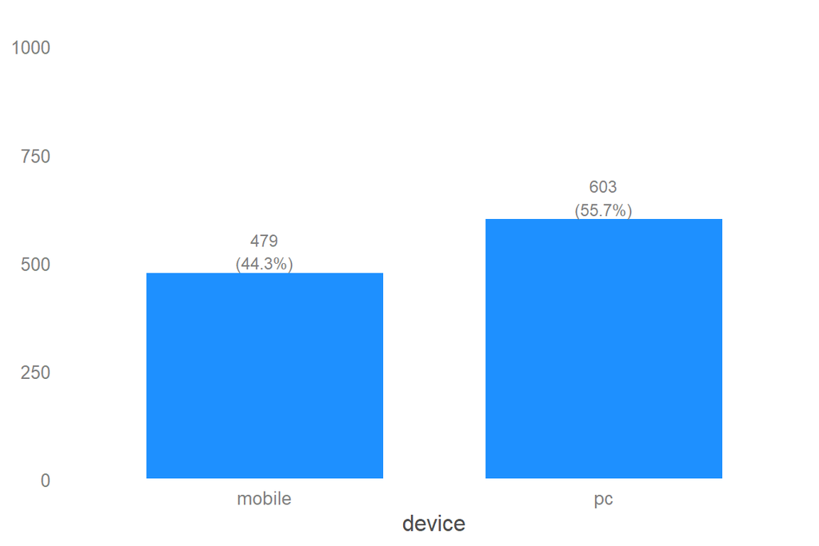

```r
df.def %>%
  plot_frq(device,
        ylim = c(0,nrow(df.def)),
        geom.colors = alpha("dodgerblue1",0.8))+
  theme_blank()
```

## 5.2 Distribution of perceived independence for mobile/pc

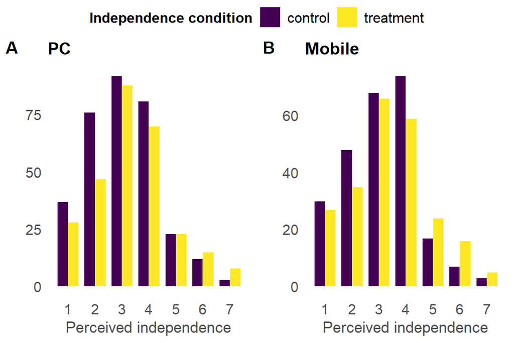

```r
p13 <- df.def %>%
  drop_na(perceived.independence.reversed) %>% filter(device == "pc") %>%
  ggplot(aes(x = perceived.independence.reversed, fill = experimental.group)) + labs(title = "PC") +
  geom_bar(width = 0.8, alpha = 1, position = position_dodge()) +
  scale_x_continuous(name="Perceived independence", breaks = 1:7) + scale_y_continuous(name="") + scale_fill_manual(name = "Independence condition", values = c("dodgerblue2","dodgerblue4")) +
theme(plot.title = element_text(face = "bold")) +  scale_fill_viridis_d(name = "Independence condition")

p14 <- df.def %>% filter(device == "mobile") %>%
  ggplot(aes(x = perceived.independence.reversed, fill = experimental.group)) + labs(title = "Mobile") +
  geom_bar(width = 0.8, alpha = 1, position = position_dodge())+
  scale_x_continuous(name="Perceived independence", breaks = 1:7) + scale_y_continuous(name="") + scale_fill_manual(name = "Independence condition", values = c("dodgerblue2","dodgerblue4")) +
theme(plot.title = element_text(face = "bold")) +  scale_fill_viridis_d(name = "Independence condition")

ggarrange(p13, p14,
          ncol = 2,nrow = 1, common.legend = TRUE, labels = "AUTO")
```

### 5.2.1 T-test

```r
tadaa_t.test(data = df.def, response = perceived.independence.reversed, group = device, print = "markdown")
```

Table 7: **Welch Two Sample t-test** with alternative hypothesis: $\mu_1 \neq \mu_2$

| Diff | $\mu_1$ mobile | $\mu_2$ pc | t | SE | df | $CI_{95\%}$ | p | Cohen's d |
| --- | --- | --- | --- | --- | --- | --- | --- | --- |
| 0.06 | 3.25 | 3.19 | 0.69 | 0.08 | 1018.18 | (-0.11 - 0.22) | .492 | 0.04 |

# 6 Descriptive statistics

## 6.1 Demography

**Age**

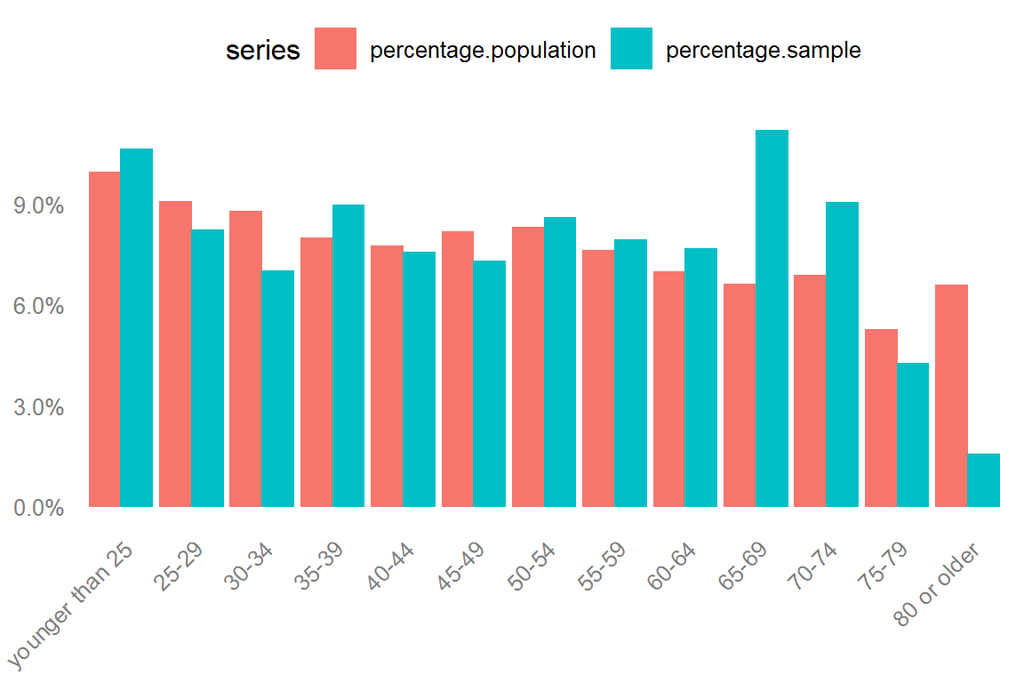

```r
age.population.5 <- read.csv("AGE_POPULATION_SEGMENTS_SE-22012021.csv")
age.total <- merge(age.population.5, age.sample, by.x = "age", by.y = ".")

age.total <- age.total %>%
  rename(age.category = age,
  count.population = count,
  count.sample = n,
  percentage.population = percentage.x,
  percentage.sample = percentage.y)

age.total$age.category <- factor(age.total$age.category, levels = c(
"younger than 25",
"25-29",           "30-34",           "35-39",
"40-44",           "45-49",           "50-54",
"55-59",           "60-64",           "65-69",
"70-74",           "75-79",           "80 or older"))

age.total %>% select(age.category, percentage.population, percentage.sample) %>% melt(id.vars = 'age.category', variable.name = 'series')  %>% ggplot(aes(age.category, value, colour = series, fill = series)) + geom_bar (stat="identity", width=0.9, position = position_dodge(width=0.9)) +
  theme_blank() + theme(legend.position="top", axis.text.x = element_text(angle = 45, hjust = 1), axis.title  = element_blank()) + scale_y_continuous(labels=scales::percent)
```

**Gender**

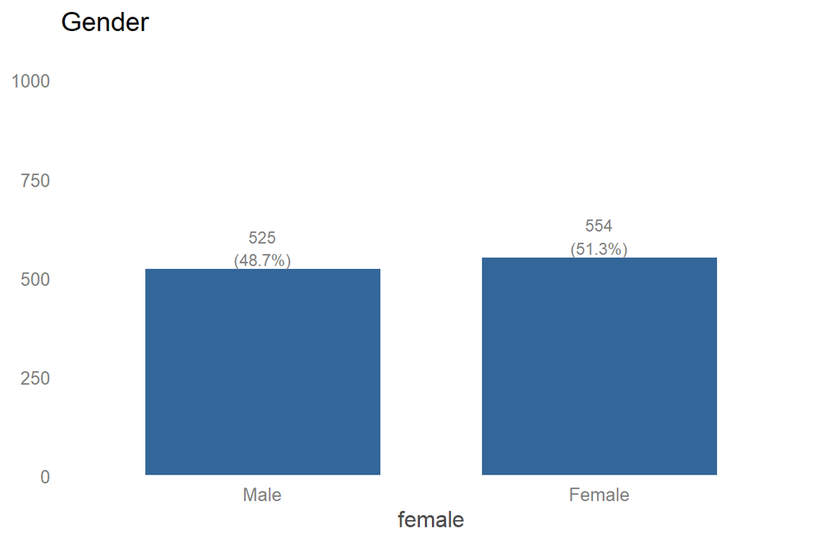

```r
df.def %>%
plot_frq(female,
                ylim = c(0,nrow(df.def)),
        axis.labels = c("Male","Female"),
        title = "Gender")+
  theme_blank()
```

**Education**

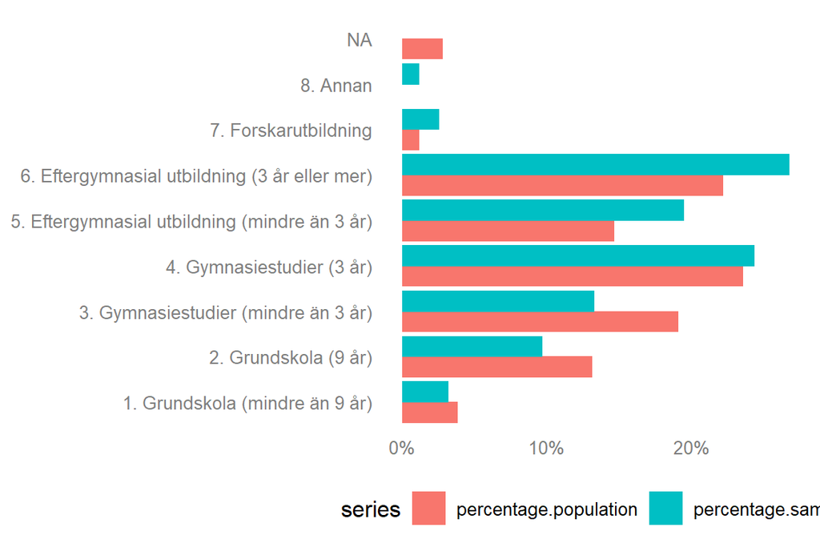

```r
education.population <- read.csv("EDUCATION_SE-25012021.csv")

education.sample <-  df.def %>% drop_na(education.recoded)  %>%  count(education.recoded) %>%
  mutate(percentage = n / sum(n))

education.total <- merge(education.population, education.sample, by.x = "level", by.y = "education.recoded", all = TRUE)

education.total <- education.total %>%
  rename(education.category = level,
  count.population = count,
  count.sample = n,
  percentage.population = percentage.x,
  percentage.sample = percentage.y)

education.total %>% select(education.category, percentage.population, percentage.sample) %>% melt(id.vars = 'education.category', variable.name = 'series')  %>% ggplot(aes(education.category, value, colour = series, fill = series)) + geom_bar (stat="identity", width=0.9, position = position_dodge(width=0.9)) +
  theme_blank() + theme(legend.position="bottom", axis.title  = element_blank()) + coord_flip() + scale_y_continuous(labels=scales::percent)
```

**Income**

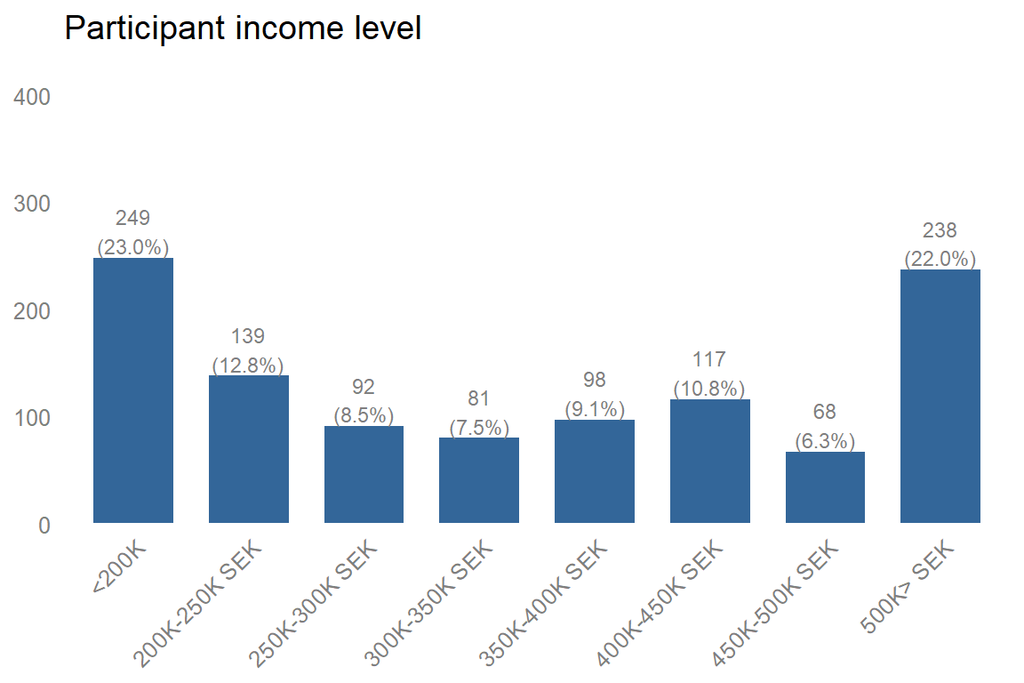

```r
df.def %>%
  filter(income!=0) %>%
  plot_frq(income,
        ylim = c(0,nrow(df.def)/2.5),
        title = "Participant income level") +
  theme_blank() + theme(axis.text.x = element_text(angle = 45, hjust = 1), axis.title  = element_blank())
```

**Province**

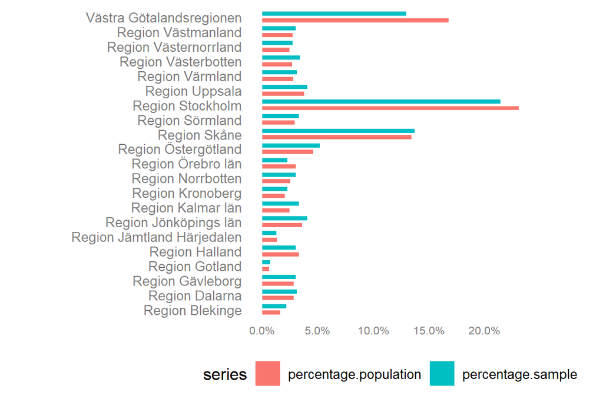

```r
provinces.population <- read.csv("PROVINCES_SE-22012021.csv")
provinces.sample <-  df.def %>% drop_na(province)  %>%  count(province) %>%
  mutate(percentage = n / sum(n))

provinces.total <- merge(provinces.sample, provinces.population, by = "province")

provinces.total <- provinces.total %>%
  rename(count.population = count,
  count.sample = n,
  percentage.sample = percentage.x,
  percentage.population = percentage.y)

provinces.total %>% select(province, percentage.population, percentage.sample) %>% melt(id.vars = 'province', variable.name = 'series')  %>% ggplot(aes(province, value, colour = series, fill = series)) + geom_bar (stat = "identity", width = 0.5, position = position_dodge(width = 0.9)) +
  theme_blank() + theme(legend.position="bottom", axis.title  = element_blank(), axis.text.x = element_text(size = 8), aspect.ratio = 1.1/1) + coord_flip() + scale_y_continuous(labels=scales::percent)
```

**Works in healthcare sector**

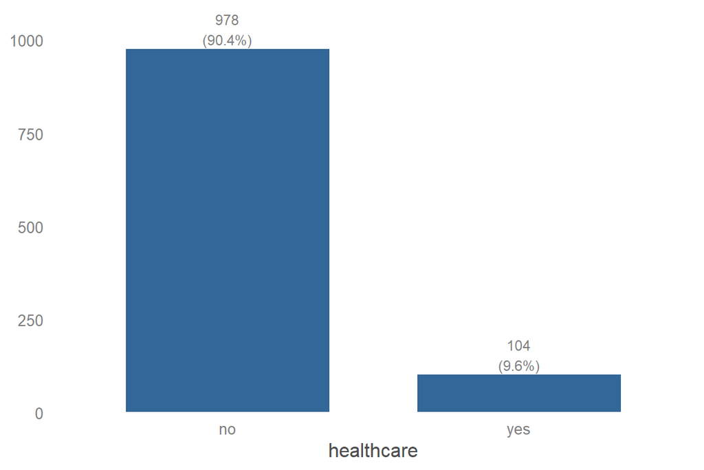

```r
df.def %>%
  plot_frq(healthcare,
        ylim = c(0,nrow(df.def)),
        title = "") +
  theme_blank()
```

## 6.2 Key variables

### 6.2.1 Statistics

```r
df.def %>% select(benefits.vaccines, intent.vaccine:importance.NRA, knowledge) %>%
sjmisc::descr(show = c("n", "NA.prc", "mean", "sd", "md", "iqr", "trimmed", "range", "skew")) %>%
  kbl(digits= 2) %>%
 kable_paper()
```

|  | var | n | NA.prc | mean | sd | md | trimmed | range | iqr | skew |
| --- | --- | --- | --- | --- | --- | --- | --- | --- | --- | --- |
| 1 | benefits.vaccines | 1082 | 0 | 5.49 | 1.54 | 6.00 | 5.71 | 6 (1-7) | 2.00 | -1.04 |
| 20 | intent.vaccine | 1082 | 0 | 3.07 | 1.00 | 3.00 | 3.21 | 3 (1-4) | 1.75 | -0.78 |
| 21 | intent.vaccine.recoded | 1082 | 0 | 0.75 | 0.43 | 1.00 | 0.81 | 1 (0-1) | 0.75 | -1.15 |
| 8 | credibility.item1 | 1082 | 0 | 4.86 | 1.52 | 5.00 | 4.95 | 6 (1-7) | 2.00 | -0.53 |
| 9 | credibility.item2.reversed | 1082 | 0 | 3.83 | 1.66 | 4.00 | 3.84 | 6 (1-7) | 2.00 | 0.08 |
| 10 | credibility.item3.reversed | 1082 | 0 | 4.05 | 1.71 | 4.00 | 4.06 | 6 (1-7) | 2.00 | -0.03 |
| 11 | credibility.item4 | 1082 | 0 | 5.13 | 1.43 | 5.00 | 5.25 | 6 (1-7) | 2.00 | -0.65 |
| 12 | credibility.item5 | 1082 | 0 | 5.11 | 1.37 | 5.00 | 5.21 | 6 (1-7) | 2.00 | -0.55 |
| 13 | credibility.item6 | 1082 | 0 | 5.31 | 1.36 | 5.00 | 5.40 | 6 (1-7) | 2.00 | -0.52 |
| 7 | credibility.index | 1082 | 0 | 4.72 | 1.13 | 4.67 | 4.71 | 6 (1-7) | 1.50 | -0.04 |
| 27 | trust.EC | 1082 | 0 | 4.12 | 1.37 | 4.00 | 4.18 | 6 (1-7) | 1.00 | -0.33 |
| 28 | trust.EP | 1082 | 0 | 4.11 | 1.46 | 4.00 | 4.16 | 6 (1-7) | 1.00 | -0.30 |
| 26 | trust.council | 1082 | 0 | 4.03 | 1.40 | 4.00 | 4.08 | 6 (1-7) | 1.00 | -0.31 |
| 31 | trust.scientist | 1082 | 0 | 5.25 | 1.30 | 5.00 | 5.35 | 6 (1-7) | 2.00 | -0.77 |
| 30 | trust.politicians | 1082 | 0 | 3.67 | 1.61 | 4.00 | 3.67 | 6 (1-7) | 3.00 | -0.06 |
| 25 | political.ideology | 1082 | 0 | 4.01 | 1.61 | 4.00 | 4.01 | 6 (1-7) | 2.00 | -0.03 |
| 14 | EU.integration | 1082 | 0 | 3.75 | 1.56 | 4.00 | 3.74 | 6 (1-7) | 2.00 | -0.06 |
| 22 | interpersonal.trust | 1082 | 0 | 3.65 | 1.66 | 4.00 | 3.64 | 6 (1-7) | 3.00 | -0.01 |
| 16 | familiarity.EMA | 1082 | 0 | 2.80 | 1.61 | 3.00 | 2.64 | 6 (1-7) | 3.00 | 0.66 |
| 15 | familiarity.advice | 1082 | 0 | 3.25 | 1.77 | 3.00 | 3.12 | 6 (1-7) | 2.00 | 0.36 |
| 4 | credibility.ECB | 1082 | 0 | 4.36 | 1.41 | 4.00 | 4.44 | 6 (1-7) | 1.00 | -0.39 |
| 6 | credibility.EMA | 1082 | 0 | 4.57 | 1.42 | 5.00 | 4.65 | 6 (1-7) | 2.00 | -0.49 |
| 5 | credibility.EFSA | 1082 | 0 | 4.43 | 1.44 | 4.00 | 4.50 | 6 (1-7) | 1.00 | -0.38 |
| 29 | trust.health.authorities | 1082 | 0 | 4.43 | 1.79 | 5.00 | 4.53 | 6 (1-7) | 3.00 | -0.43 |
| 24 | perceived.independence.reversed | 1082 | 0 | 3.22 | 1.37 | 3.00 | 3.17 | 6 (1-7) | 2.00 | 0.37 |
| 3 | consequences.health | 1082 | 0 | 4.87 | 1.77 | 5.00 | 5.03 | 6 (1-7) | 2.00 | -0.58 |
| 2 | consequences.economic | 1082 | 0 | 4.02 | 1.95 | 4.00 | 4.03 | 6 (1-7) | 4.00 | -0.04 |
| 17 | importance.EMA | 1082 | 0 | 2.92 | 0.98 | 3.00 | 3.02 | 3 (1-4) | 2.00 | -0.55 |
| 18 | importance.FDA | 1082 | 0 | 2.69 | 0.96 | 3.00 | 2.74 | 3 (1-4) | 1.00 | -0.30 |
| 19 | importance.NRA | 1082 | 0 | 3.12 | 0.97 | 3.00 | 3.27 | 3 (1-4) | 1.00 | -0.84 |
| 23 | knowledge | 1082 | 0 | 0.48 | 0.50 | 0.00 | 0.47 | 1 (0-1) | 1.00 | 0.10 |

### 6.2.2 Plots

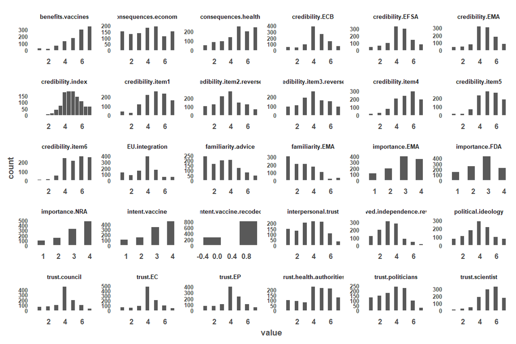

```r
df.def %>% select(benefits.vaccines, intent.vaccine:importance.NRA) %>%
  gather() %>%
  ggplot(aes(value)) +
    facet_wrap(~ key, scales = "free") +
    geom_histogram(boundary = 0.1, binwidth = 0.5) +
  theme(text = element_text(face = "bold",  size = 6), axis.text.y = element_text(size = 5))
```

# 7 Correlation matrix

```r
df.def %>%
  select(trust.EC:trust.politicians, trust.health.authorities, benefits.vaccines, credibility.index, credibility.EMA, familiarity.EMA, familiarity.advice, consequences.economic, consequences.health, age, perceived.independence.reversed, political.ideology, EU.integration, knowledge, interpersonal.trust, treatment, private.providers) %>%
  tab_corr(triangle="lower",
           remove.spaces=T,
           p.numeric = T,
           fade.ns = T,
           digits = 2,
           na.deletion="pairwise",
           title = "Correlation matrix")
```

Correlation matrix

|  | trust.EC | trust.EP | trust.council | trust.scientist | trust.politicians | trust.health.authorities | benefits.vaccines | credibility.index | credibility.EMA | familiarity.EMA | familiarity.advice | consequences.economic | consequences.health | age | perceived.independence.reversed | political.ideology | EU.integration | knowledge | interpersonal.trust | treatment | private.providers |
| --- | --- | --- | --- | --- | --- | --- | --- | --- | --- | --- | --- | --- | --- | --- | --- | --- | --- | --- | --- | --- | --- |
| trust.EC |  |  |  |  |  |  |  |  |  |  |  |  |  |  |  |  |  |  |  |  |  |
| trust.EP | 0.88 (<.001) |  |  |  |  |  |  |  |  |  |  |  |  |  |  |  |  |  |  |  |  |
| trust.council | 0.87 (<.001) | 0.88 (<.001) |  |  |  |  |  |  |  |  |  |  |  |  |  |  |  |  |  |  |  |
| trust.scientist | 0.52 (<.001) | 0.50 (<.001) | 0.52 (<.001) |  |  |  |  |  |  |  |  |  |  |  |  |  |  |  |  |  |  |
| trust.politicians | 0.53 (<.001) | 0.55 (<.001) | 0.53 (<.001) | 0.43 (<.001) |  |  |  |  |  |  |  |  |  |  |  |  |  |  |  |  |  |
| trust.health.authorities | 0.33 (<.001) | 0.36 (<.001) | 0.36 (<.001) | 0.31 (<.001) | 0.54 (<.001) |  |  |  |  |  |  |  |  |  |  |  |  |  |  |  |  |
| benefits.vaccines | 0.33 (<.001) | 0.31 (<.001) | 0.32 (<.001) | 0.44 (<.001) | 0.34 (<.001) | 0.39 (<.001) |  |  |  |  |  |  |  |  |  |  |  |  |  |  |  |
| credibility.index | 0.40 (<.001) | 0.39 (<.001) | 0.40 (<.001) | 0.46 (<.001) | 0.39 (<.001) | 0.38 (<.001) | 0.60 (<.001) |  |  |  |  |  |  |  |  |  |  |  |  |  |  |
| credibility.EMA | 0.64 (<.001) | 0.63 (<.001) | 0.64 (<.001) | 0.56 (<.001) | 0.47 (<.001) | 0.36 (<.001) | 0.49 (<.001) | 0.53 (<.001) |  |  |  |  |  |  |  |  |  |  |  |  |  |
| familiarity.EMA | 0.19 (<.001) | 0.19 (<.001) | 0.20 (<.001) | 0.13 (<.001) | 0.15 (<.001) | 0.09 (<.001) | 0.01 (.71) | 0.07 (.02) | 0.18 (<.001) |  |  |  |  |  |  |  |  |  |  |  |  |
| familiarity.advice | 0.17 (<.001) | 0.16 (<.001) | 0.18 (<.001) | 0.18 (<.001) | 0.14 (<.001) | 0.07 (.03) | 0.09 (<.001) | 0.17 (<.001) | 0.22 (<.001) | 0.77 (<.001) |  |  |  |  |  |  |  |  |  |  |  |
| consequences.economic | -0.04 (.16) | -0.05 (.13) | -0.04 (.19) | -0.10 (<.001) | -0.13 (<.001) | -0.06 (.04) | -0.10 (<.001) | -0.18 (<.001) | -0.08 (.01) | 0.03 (.28) | -0.03 (.36) |  |  |  |  |  |  |  |  |  |  |
| consequences.health | 0.07 (.02) | 0.05 (.08) | 0.07 (.03) | 0.06 (.04) | -0.01 (.84) | -0.02 (.46) | 0.11 (<.001) | 0.07 (.02) | 0.09 (<.001) | 0.02 (.49) | -0.01 (.64) | 0.48 (<.001) |  |  |  |  |  |  |  |  |  |
| age | -0.12 (<.001) | -0.12 (<.001) | -0.10 (<.001) | -0.09 (<.001) | -0.03 (.34) | 0.06 (.04) | 0.10 (<.001) | 0.14 (<.001) | -0.06 (.05) | -0.01 (.83) | 0.03 (.30) | -0.14 (<.001) | 0.02 (.47) |  |  |  |  |  |  |  |  |
| perceived.independence.reversed | -0.03 (.32) | -0.05 (.08) | -0.04 (.24) | -0.07 (.02) | -0.02 (.49) | 0.00 (.97) | -0.01 (.71) | 0.12 (<.001) | -0.04 (.23) | -0.07 (.03) | -0.04 (.25) | -0.05 (.10) | -0.08 (.01) | 0.04 (.16) |  |  |  |  |  |  |  |
| political.ideology | -0.05 (.13) | -0.06 (.06) | -0.05 (.08) | -0.08 (.01) | -0.22 (<.001) | -0.20 (<.001) | -0.15 (<.001) | -0.08 (.01) | -0.02 (.52) | 0.09 (<.001) | 0.07 (.02) | -0.01 (.86) | -0.04 (.16) | 0.02 (.43) | -0.05 (.11) |  |  |  |  |  |  |
| EU.integration | 0.48 (<.001) | 0.50 (<.001) | 0.51 (<.001) | 0.28 (<.001) | 0.30 (<.001) | 0.23 (<.001) | 0.21 (<.001) | 0.27 (<.001) | 0.38 (<.001) | 0.15 (<.001) | 0.14 (<.001) | 0.02 (.61) | 0.09 (<.001) | -0.14 (<.001) | -0.05 (.09) | -0.01 (.74) |  |  |  |  |  |
| knowledge | -0.02 (.60) | -0.01 (.84) | -0.00 (.94) | 0.02 (.50) | 0.06 (.06) | 0.02 (.46) | 0.10 (<.001) | 0.12 (<.001) | 0.05 (.08) | 0.02 (.60) | 0.07 (.02) | -0.03 (.37) | 0.05 (.14) | 0.18 (<.001) | 0.06 (.04) | -0.00 (.90) | -0.00 (.91) |  |  |  |  |
| interpersonal.trust | 0.27 (<.001) | 0.28 (<.001) | 0.28 (<.001) | 0.26 (<.001) | 0.36 (<.001) | 0.27 (<.001) | 0.22 (<.001) | 0.30 (<.001) | 0.30 (<.001) | 0.13 (<.001) | 0.15 (<.001) | -0.16 (<.001) | -0.12 (<.001) | 0.04 (.20) | 0.00 (.91) | -0.08 (.01) | 0.24 (<.001) | 0.02 (.54) |  |  |  |
| treatment | 0.03 (.41) | 0.00 (.88) | 0.02 (.48) | -0.02 (.59) | -0.01 (.84) | -0.00 (.93) | 0.01 (.65) | 0.03 (.26) | 0.02 (.58) | -0.00 (.91) | -0.02 (.50) | -0.04 (.22) | 0.00 (.98) | 0.03 (.26) | 0.09 (<.001) | 0.02 (.43) | 0.02 (.61) | 0.01 (.65) | 0.03 (.28) |  |  |
| private.providers | 0.06 (.04) | 0.06 (.05) | 0.06 (.06) | 0.00 (.89) | -0.09 (<.001) | -0.17 (<.001) | -0.10 (<.001) | -0.08 (.01) | 0.03 (.37) | 0.17 (<.001) | 0.12 (<.001) | 0.06 (.06) | -0.04 (.14) | -0.10 (<.001) | -0.08 (.01) | 0.44 (<.001) | 0.09 (<.001) | -0.03 (.34) | 0.03 (.32) | 0.06 (.05) |  |
| Computed correlation used pearson-method with pairwise-deletion. |  |  |  |  |  |  |  |  |  |  |  |  |  |  |  |  |  |  |  |  |  |

# 8 Regression

## 8.1 Perceived independence

```r
reg.perceived.independence1 <- lm(perceived.independence.reversed ~  trust.politicians + trust.scientist + trust.EC + trust.health.authorities + interpersonal.trust + benefits.vaccines + credibility.EMA + familiarity.EMA + familiarity.advice +  political.ideology + consequences.health + consequences.economic + EU.integration + private.providers + knowledge +  experimental.group + female + poly(age, 2) + healthcare + income,
                    data = df.def,
                    na.action = na.omit)

reg.perceived.independence2 <- lm(perceived.independence.reversed ~ credibility.index + trust.politicians + trust.scientist + trust.EC + trust.health.authorities + interpersonal.trust + benefits.vaccines + credibility.EMA + familiarity.EMA + familiarity.advice +  political.ideology + consequences.health + consequences.economic +  EU.integration + private.providers + knowledge +  experimental.group + female + poly(age, 2) + healthcare + income,
                    data = df.def,
                    na.action = na.omit)


tab_model(reg.perceived.independence1, reg.perceived.independence2,  show.ci = FALSE)
```

|  | perceived independence reversed |  | perceived independence reversed |  |
| --- | --- | --- | --- | --- |
| Predictors | Estimates | p | Estimates | p |
| (Intercept) | 3.95 | **<0.001** | 3.52 | **<0.001** |
| trust.politicians | -0.02 | 0.592 | -0.02 | 0.511 |
| trust.scientist | -0.09 | **0.041** | -0.11 | **0.007** |
| trust.EC | 0.05 | 0.292 | 0.04 | 0.369 |
| trust.health.authorities | 0.01 | 0.846 | -0.01 | 0.696 |
| interpersonal.trust | 0.01 | 0.663 | -0.00 | 0.881 |
| benefits.vaccines | 0.00 | 0.959 | -0.08 | **0.037** |
| credibility.EMA | 0.00 | 0.961 | -0.04 | 0.326 |
| familiarity.EMA | -0.06 | 0.168 | -0.04 | 0.385 |
| familiarity.advice | 0.03 | 0.368 | 0.01 | 0.766 |
| political.ideology | -0.02 | 0.564 | -0.02 | 0.426 |
| consequences.health | -0.06 | **0.037** | -0.07 | **0.011** |
| consequences.economic | -0.00 | 0.850 | 0.01 | 0.646 |
| EU.integration | -0.03 | 0.313 | -0.04 | 0.173 |
| private.providers | -0.05 | 0.058 | -0.05 | 0.087 |
| knowledge | 0.17 | **0.043** | 0.15 | 0.071 |
| experimental.group [treatment] | 0.25 | **0.003** | 0.23 | **0.005** |
| female | 0.11 | 0.212 | 0.13 | 0.153 |
| age [1st degree] | 0.40 | 0.787 | -0.74 | 0.615 |
| age [2nd degree] | -0.44 | 0.759 | -0.24 | 0.863 |
| healthcare [yes] | -0.14 | 0.340 | -0.11 | 0.423 |
| income200K-250K SEK | 0.01 | 0.966 | 0.04 | 0.792 |
| income250K-300K SEK | -0.06 | 0.743 | -0.04 | 0.819 |
| income300K-350K SEK | -0.06 | 0.746 | -0.05 | 0.773 |
| income350K-400K SEK | -0.03 | 0.864 | 0.01 | 0.941 |
| income400K-450K SEK | 0.05 | 0.766 | 0.06 | 0.708 |
| income450K-500K SEK | 0.05 | 0.813 | 0.06 | 0.759 |
| income [500K> SEK] | -0.01 | 0.958 | 0.01 | 0.959 |
| credibility.index |  |  | 0.30 | **<0.001** |
| Observations | 1079 |  | 1079 |  |
| R<sup>2</sup> / R<sup>2</sup> adjusted | 0.038 / 0.013 |  | 0.068 / 0.044 |  |

## 8.2 Vaccination intension

```r
reg.intent.vaccine1 <- glm(intent.vaccine.recoded ~ trust.politicians + trust.scientist + trust.EC + trust.health.authorities + interpersonal.trust + benefits.vaccines + credibility.EMA + familiarity.EMA + familiarity.advice +  political.ideology + consequences.health + consequences.economic + EU.integration + private.providers + knowledge +  experimental.group + female + age + healthcare + income,
                    data = df.def,
                    na.action = na.omit,
                    family = binomial(link = 'logit'))

reg.intent.vaccine2 <- glm(intent.vaccine.recoded ~ credibility.index + trust.politicians + trust.scientist + trust.EC + trust.health.authorities + interpersonal.trust + benefits.vaccines + credibility.EMA + familiarity.EMA + familiarity.advice +  political.ideology + consequences.health + consequences.economic + EU.integration + private.providers + knowledge +  experimental.group + female + age + healthcare + income,
                    data = df.def,
                    na.action = na.omit,
                    family = binomial(link = 'logit'))

reg.intent.vaccine3 <- glm(intent.vaccine.recoded ~ perceived.independence.reversed + trust.politicians + trust.scientist + trust.EC + trust.health.authorities + interpersonal.trust + benefits.vaccines + credibility.EMA + familiarity.EMA + familiarity.advice +  political.ideology + consequences.health + consequences.economic + EU.integration + private.providers + knowledge +  experimental.group + female + age + healthcare + income,
                    data = df.def,
                    na.action = na.omit,
                    family = binomial(link = 'logit'))

reg.intent.vaccine4 <- glm(intent.vaccine.recoded ~ credibility.index + perceived.independence.reversed + trust.politicians + trust.scientist + trust.EC + trust.health.authorities + interpersonal.trust + benefits.vaccines + credibility.EMA + familiarity.EMA + familiarity.advice +  political.ideology + consequences.health + consequences.economic + EU.integration + private.providers + knowledge +  experimental.group + female + age + healthcare + income,
                    data = df.def,
                    na.action = na.omit,
                    family = binomial(link = 'logit'))

tab_model(reg.intent.vaccine1, reg.intent.vaccine2, reg.intent.vaccine3, reg.intent.vaccine4, show.ci = FALSE)
```

|  | intent vaccine recoded |  | intent vaccine recoded |  | intent vaccine recoded |  | intent vaccine recoded |  |
| --- | --- | --- | --- | --- | --- | --- | --- | --- |
| Predictors | Odds Ratios | p | Odds Ratios | p | Odds Ratios | p | Odds Ratios | p |
| (Intercept) | 0.00 | **<0.001** | 0.00 | **<0.001** | 0.00 | **<0.001** | 0.00 | **<0.001** |
| trust.politicians | 0.97 | 0.710 | 0.95 | 0.522 | 0.97 | 0.715 | 0.95 | 0.498 |
| trust.scientist | 1.00 | 0.967 | 0.96 | 0.622 | 1.00 | 0.997 | 0.95 | 0.538 |
| trust.EC | 0.98 | 0.867 | 0.95 | 0.642 | 0.99 | 0.936 | 0.97 | 0.730 |
| trust.health.authorities | 1.20 | **0.005** | 1.14 | **0.047** | 1.20 | **0.004** | 1.14 | **0.044** |
| interpersonal.trust | 0.98 | 0.739 | 0.96 | 0.549 | 0.98 | 0.734 | 0.96 | 0.505 |
| benefits.vaccines | 2.19 | **<0.001** | 1.92 | **<0.001** | 2.19 | **<0.001** | 1.90 | **<0.001** |
| credibility.EMA | 1.10 | 0.287 | 1.02 | 0.810 | 1.10 | 0.310 | 1.01 | 0.890 |
| familiarity.EMA | 0.86 | 0.124 | 0.88 | 0.190 | 0.86 | 0.121 | 0.88 | 0.182 |
| familiarity.advice | 1.13 | 0.165 | 1.12 | 0.222 | 1.13 | 0.177 | 1.11 | 0.255 |
| political.ideology | 0.97 | 0.675 | 0.98 | 0.701 | 0.98 | 0.713 | 0.98 | 0.732 |
| consequences.health | 1.21 | **0.002** | 1.19 | **0.006** | 1.21 | **0.003** | 1.18 | **0.011** |
| consequences.economic | 0.92 | 0.121 | 0.94 | 0.304 | 0.92 | 0.115 | 0.94 | 0.300 |
| EU.integration | 1.22 | **0.004** | 1.18 | **0.016** | 1.21 | **0.005** | 1.18 | **0.020** |
| private.providers | 0.98 | 0.694 | 0.96 | 0.537 | 0.97 | 0.622 | 0.95 | 0.458 |
| knowledge | 1.09 | 0.656 | 1.04 | 0.816 | 1.10 | 0.603 | 1.08 | 0.687 |
| experimental.group [treatment] | 1.09 | 0.647 | 1.06 | 0.742 | 1.11 | 0.561 | 1.09 | 0.657 |
| female | 0.60 | **0.008** | 0.62 | **0.015** | 0.61 | **0.009** | 0.64 | **0.021** |
| age | 1.03 | **<0.001** | 1.02 | **<0.001** | 1.03 | **<0.001** | 1.02 | **<0.001** |
| healthcare [yes] | 1.71 | 0.090 | 1.74 | 0.085 | 1.67 | 0.103 | 1.66 | 0.113 |
| income200K-250K SEK | 0.89 | 0.717 | 0.98 | 0.947 | 0.90 | 0.729 | 0.99 | 0.979 |
| income250K-300K SEK | 1.23 | 0.570 | 1.24 | 0.560 | 1.23 | 0.566 | 1.22 | 0.587 |
| income300K-350K SEK | 1.18 | 0.653 | 1.24 | 0.565 | 1.16 | 0.686 | 1.21 | 0.620 |
| income350K-400K SEK | 1.07 | 0.849 | 1.24 | 0.543 | 1.06 | 0.872 | 1.23 | 0.561 |
| income400K-450K SEK | 1.19 | 0.602 | 1.16 | 0.661 | 1.18 | 0.620 | 1.14 | 0.705 |
| income450K-500K SEK | 1.68 | 0.228 | 1.73 | 0.198 | 1.70 | 0.220 | 1.76 | 0.189 |
| income [500K> SEK] | 1.09 | 0.742 | 1.12 | 0.693 | 1.08 | 0.771 | 1.10 | 0.738 |
| credibility.index |  |  | 2.06 | **<0.001** |  |  | 2.12 | **<0.001** |
| perceived.independence.reversed |  |  |  |  | 0.89 | 0.116 | 0.84 | **0.025** |
| Observations | 1079 |  | 1079 |  | 1079 |  | 1079 |  |
| R<sup>2</sup> Tjur | 0.366 |  | 0.393 |  | 0.369 |  | 0.398 |  |

## 8.3 Crebility of EMA’s decision

```r
reg.credibility1 <- lm(credibility.index  ~ trust.politicians + trust.scientist + trust.EC + trust.health.authorities + interpersonal.trust + benefits.vaccines + credibility.EMA + familiarity.EMA + familiarity.advice + political.ideology + consequences.health + consequences.economic + EU.integration + private.providers + knowledge +  experimental.group + female + poly(age, 2) + healthcare + income,
                    data = df.def,
                    na.action = na.omit)

reg.credibility2 <- lm(credibility.index  ~ perceived.independence.reversed + trust.politicians + trust.scientist + trust.EC + trust.health.authorities + interpersonal.trust + benefits.vaccines + credibility.EMA + familiarity.EMA + familiarity.advice +  political.ideology + consequences.health + consequences.economic + EU.integration + private.providers + knowledge +  experimental.group + female + poly(age, 2) + healthcare + income,
                    data = df.def,
                    na.action = na.omit)

reg.credibility3 <- lm(credibility.index  ~ perceived.independence.reversed + trust.politicians + trust.scientist + trust.EC + trust.health.authorities + interpersonal.trust + benefits.vaccines + credibility.EMA + familiarity.EMA +  + familiarity.advice +  political.ideology + consequences.health + consequences.economic + EU.integration + private.providers + knowledge +  experimental.group + female + poly(age, 2) + healthcare + income + perceived.independence.reversed:benefits.vaccines + benefits.vaccines:experimental.group,
                    data = df.def,
                    na.action = na.omit)

reg.credibility4 <- lm(credibility.index  ~ perceived.independence.reversed + trust.politicians + trust.scientist + trust.EC + trust.health.authorities + interpersonal.trust + benefits.vaccines + credibility.EMA + familiarity.EMA +  + familiarity.advice +  political.ideology + consequences.health + consequences.economic + EU.integration + private.providers + knowledge +  experimental.group + female + age.recoded + healthcare + income + perceived.independence.reversed:benefits.vaccines + benefits.vaccines:experimental.group,
                    data = df.def,
                    na.action = na.omit)


reg.credibility3.centered <- meanCenter(reg.credibility3, centerOnlyInteractors = TRUE, centerDV = FALSE)

reg.credibility4.centered <- meanCenter(reg.credibility4, centerOnlyInteractors = TRUE, centerDV = FALSE)

tab_model(reg.credibility1, reg.credibility2, reg.credibility3.centered, show.ci = FALSE)
```

|  | credibility index |  | credibility index |  | credibility index |  |
| --- | --- | --- | --- | --- | --- | --- |
| Predictors | Estimates | p | Estimates | p | Estimates | p |
| (Intercept) | 1.42 | **<0.001** | 1.01 | **<0.001** | 2.76 | **<0.001** |
| trust.politicians | 0.01 | 0.535 | 0.02 | 0.466 | 0.02 | 0.445 |
| trust.scientist | 0.09 | **<0.001** | 0.10 | **<0.001** | 0.09 | **<0.001** |
| trust.EC | 0.03 | 0.340 | 0.02 | 0.437 | 0.02 | 0.400 |
| trust.health.authorities | 0.06 | **0.001** | 0.06 | **0.001** | 0.06 | **0.001** |
| interpersonal.trust | 0.05 | **0.001** | 0.05 | **0.001** | 0.05 | **0.002** |
| benefits.vaccines | 0.26 | **<0.001** | 0.26 | **<0.001** |  |  |
| credibility.EMA | 0.15 | **<0.001** | 0.15 | **<0.001** | 0.15 | **<0.001** |
| familiarity.EMA | -0.07 | **0.004** | -0.07 | **0.007** | -0.06 | **0.007** |
| familiarity.advice | 0.08 | **0.001** | 0.07 | **0.001** | 0.07 | **0.001** |
| political.ideology | 0.02 | 0.246 | 0.02 | 0.200 | 0.02 | 0.203 |
| consequences.health | 0.04 | **0.017** | 0.05 | **0.005** | 0.05 | **0.004** |
| consequences.economic | -0.06 | **<0.001** | -0.05 | **<0.001** | -0.06 | **<0.001** |
| EU.integration | 0.03 | 0.061 | 0.04 | **0.037** | 0.04 | **0.038** |
| private.providers | -0.02 | 0.252 | -0.01 | 0.414 | -0.01 | 0.497 |
| knowledge | 0.07 | 0.163 | 0.05 | 0.296 | 0.05 | 0.301 |
| experimental.group [treatment] | 0.05 | 0.275 | 0.03 | 0.569 | 0.03 | 0.605 |
| female | -0.05 | 0.373 | -0.06 | 0.258 | -0.06 | 0.253 |
| age [1st degree] | 3.79 | **<0.001** | 3.75 | **<0.001** | 3.68 | **<0.001** |
| age [2nd degree] | -0.65 | 0.443 | -0.61 | 0.470 | -0.60 | 0.472 |
| healthcare [yes] | -0.08 | 0.356 | -0.06 | 0.445 | -0.07 | 0.388 |
| income200K-250K SEK | -0.11 | 0.223 | -0.11 | 0.213 | -0.10 | 0.222 |
| income250K-300K SEK | -0.06 | 0.566 | -0.05 | 0.600 | -0.05 | 0.596 |
| income300K-350K SEK | -0.02 | 0.825 | -0.02 | 0.868 | -0.02 | 0.849 |
| income350K-400K SEK | -0.13 | 0.173 | -0.13 | 0.176 | -0.13 | 0.162 |
| income400K-450K SEK | -0.04 | 0.693 | -0.04 | 0.649 | -0.05 | 0.563 |
| income450K-500K SEK | -0.04 | 0.719 | -0.05 | 0.682 | -0.04 | 0.687 |
| income [500K> SEK] | -0.04 | 0.561 | -0.04 | 0.562 | -0.05 | 0.508 |
| perceived.independence.reversed |  |  | 0.11 | **<0.001** |  |  |
| perceived.independence.reversedc |  |  |  |  | 0.10 | **<0.001** |
| benefits.vaccinesc |  |  |  |  | 0.23 | **<0.001** |
| perceived.independence.reversedc * benefits.vaccinesc |  |  |  |  | 0.01 | 0.272 |
| benefits.vaccinesc * experimental.group [treatment] |  |  |  |  | 0.06 | 0.067 |
| Observations | 1079 |  | 1079 |  | 1079 |  |
| R<sup>2</sup> / R<sup>2</sup> adjusted | 0.503 / 0.490 |  | 0.519 / 0.506 |  | 0.521 / 0.507 |  |

*Note: Interaction variables are centered in the third model*

### 8.3.1 Plots

*Interaction effect: perceived independence x benefits of vaccines*

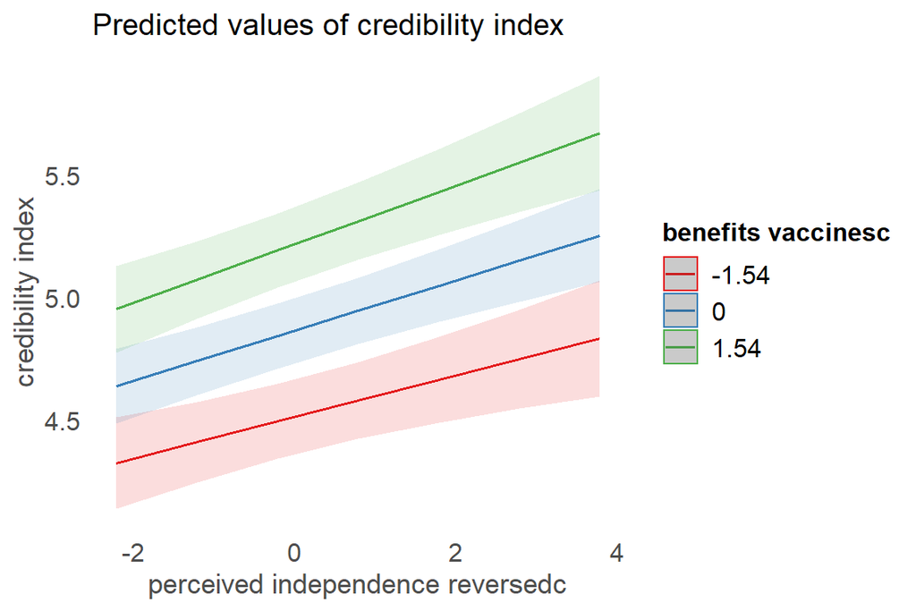

```r
plot_model(reg.credibility3.centered, type = "int", mdrt.values = "meansd")[[1]]
```

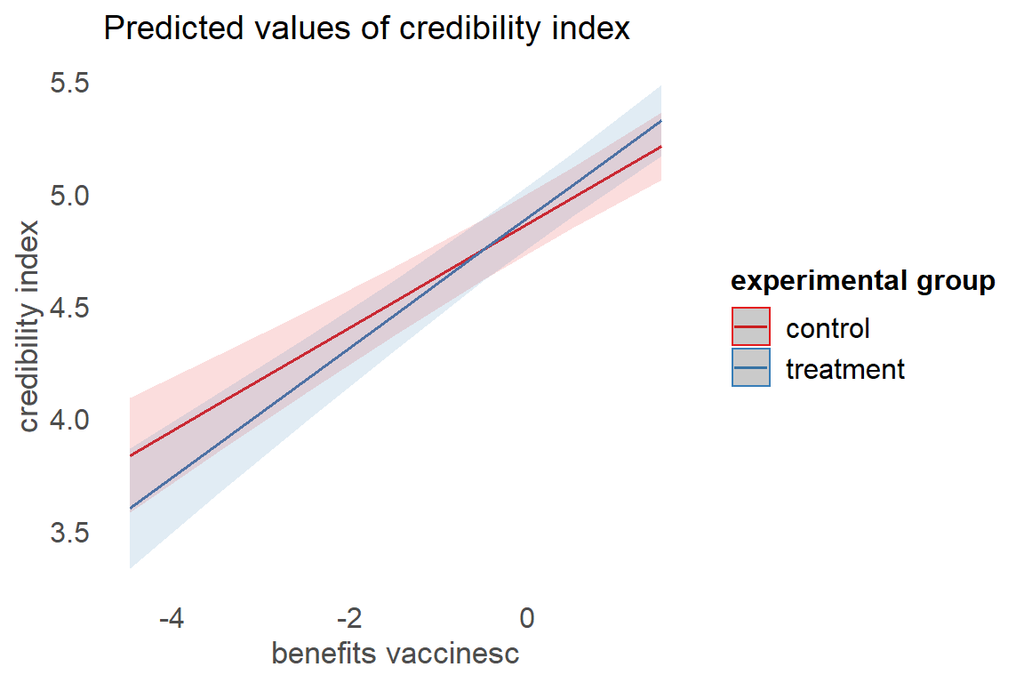

```r
plot_model(reg.credibility3.centered, type = "int", mdrt.values = "meansd")[[2]]
```

*marginal effects: Effect of perceived independence on credibility for different age groups*

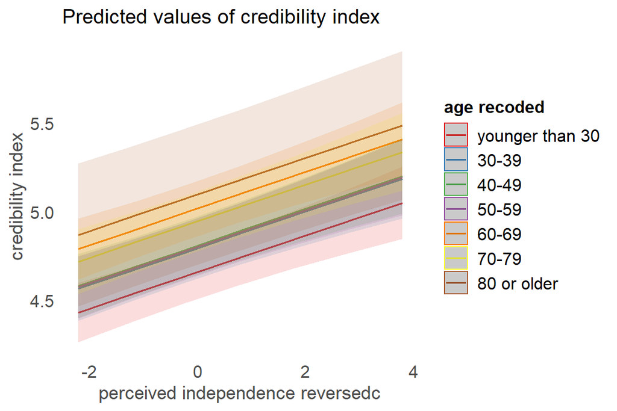

```r
plot_model(reg.credibility4.centered, type = "pred", terms = c("perceived.independence.reversedc", "age.recoded"))
```

## 8.4 Full models - filtered

### 8.4.1 Perceived independence

```r
reg.perceived.independence.30 <- lm(perceived.independence.reversed ~ credibility.index + trust.politicians + trust.scientist + trust.EC + trust.health.authorities + interpersonal.trust + benefits.vaccines + credibility.EMA + familiarity.EMA + familiarity.advice +  political.ideology + consequences.health + consequences.economic +  EU.integration + private.providers + knowledge +  experimental.group + female + poly(age, 2) + healthcare + income,
                    data = df.30,
                    na.action = na.omit)

reg.perceived.independence.check <- lm(perceived.independence.reversed ~ credibility.index + trust.politicians + trust.scientist + trust.EC + trust.health.authorities + interpersonal.trust + benefits.vaccines + credibility.EMA + familiarity.EMA + familiarity.advice +  political.ideology + consequences.health + consequences.economic +  EU.integration + private.providers + knowledge +  experimental.group + female + poly(age, 2) + healthcare + income,
                    data = df.check,
                    na.action = na.omit)

tab_model(reg.perceived.independence.30, reg.perceived.independence.check, dv.labels = c("Perceived independence (filter = page submission)", "Perceived independence (filter = manipulation check)"), show.ci = FALSE)
```

|  | Perceived independence (filter = page submission) |  | Perceived independence (filter = manipulation check) |  |
| --- | --- | --- | --- | --- |
| Predictors | Estimates | p | Estimates | p |
| (Intercept) | 2.22 | **<0.001** | 3.24 | **<0.001** |
| credibility.index | 0.46 | **<0.001** | 0.39 | **<0.001** |
| trust.politicians | -0.00 | 0.977 | -0.01 | 0.884 |
| trust.scientist | -0.05 | 0.514 | -0.15 | **0.007** |
| trust.EC | -0.05 | 0.598 | 0.03 | 0.605 |
| trust.health.authorities | -0.04 | 0.519 | -0.02 | 0.567 |
| interpersonal.trust | 0.09 | 0.083 | -0.00 | 0.926 |
| benefits.vaccines | -0.12 | 0.104 | -0.11 | **0.017** |
| credibility.EMA | 0.01 | 0.876 | -0.01 | 0.803 |
| familiarity.EMA | 0.07 | 0.368 | 0.00 | 0.999 |
| familiarity.advice | -0.05 | 0.420 | -0.02 | 0.607 |
| political.ideology | -0.05 | 0.389 | -0.03 | 0.413 |
| consequences.health | -0.13 | **0.012** | -0.06 | 0.086 |
| consequences.economic | 0.02 | 0.603 | 0.03 | 0.437 |
| EU.integration | 0.05 | 0.427 | -0.03 | 0.386 |
| private.providers | -0.02 | 0.756 | -0.04 | 0.218 |
| knowledge | 0.10 | 0.524 | 0.15 | 0.155 |
| experimental.group [treatment] | 0.43 | **0.006** | 0.33 | **0.003** |
| female | 0.06 | 0.720 | 0.05 | 0.683 |
| age [1st degree] | -0.83 | 0.606 | -0.89 | 0.569 |
| age [2nd degree] | -1.13 | 0.455 | 0.72 | 0.628 |
| healthcare [yes] | -0.14 | 0.609 | -0.03 | 0.891 |
| income200K-250K SEK | -0.00 | 1.000 | 0.16 | 0.393 |
| income250K-300K SEK | 0.34 | 0.262 | -0.02 | 0.913 |
| income300K-350K SEK | 0.16 | 0.637 | -0.04 | 0.849 |
| income350K-400K SEK | 0.16 | 0.580 | -0.05 | 0.797 |
| income400K-450K SEK | 0.35 | 0.205 | 0.10 | 0.617 |
| income450K-500K SEK | 0.25 | 0.518 | 0.03 | 0.897 |
| income [500K> SEK] | -0.09 | 0.695 | 0.06 | 0.716 |
| Observations | 382 |  | 727 |  |
| R<sup>2</sup> / R<sup>2</sup> adjusted | 0.153 / 0.086 |  | 0.090 / 0.054 |  |

### 8.4.2 Vaccination intention

```r
reg.intent.vaccine.30 <- glm(intent.vaccine.recoded ~ credibility.index + perceived.independence.reversed + trust.politicians + trust.scientist + trust.EC + trust.health.authorities + interpersonal.trust + benefits.vaccines + credibility.EMA + familiarity.EMA + familiarity.advice +  political.ideology + consequences.health + consequences.economic + EU.integration + private.providers + knowledge +  experimental.group + female + age + healthcare + income,
                    data = df.30,
                    na.action = na.omit,
                    family = binomial(link = 'logit'))

reg.intent.vaccine.check  <- glm(intent.vaccine.recoded ~ credibility.index + perceived.independence.reversed + trust.politicians + trust.scientist + trust.EC + trust.health.authorities + interpersonal.trust + benefits.vaccines + credibility.EMA + familiarity.EMA + familiarity.advice +  political.ideology + consequences.health + consequences.economic + EU.integration + private.providers + knowledge +  experimental.group + female + age + healthcare + income,
                    data = df.check,
                    na.action = na.omit,
                    family = binomial(link = 'logit'))

tab_model(reg.intent.vaccine.30, reg.intent.vaccine.check, dv.labels = c("Vaccination intention (filter = page submission)", "Vaccination intention (filter = manipulation check)"), show.ci = FALSE)
```

|  | Vaccination intention (filter = page submission) |  | Vaccination intention (filter = manipulation check) |  |
| --- | --- | --- | --- | --- |
| Predictors | Odds Ratios | p | Odds Ratios | p |
| (Intercept) | 0.00 | **<0.001** | 0.00 | **<0.001** |
| credibility.index | 2.63 | **<0.001** | 2.41 | **<0.001** |
| perceived.independence.reversed | 0.80 | 0.133 | 0.90 | 0.310 |
| trust.politicians | 0.87 | 0.373 | 1.00 | 0.985 |
| trust.scientist | 0.93 | 0.704 | 0.89 | 0.340 |
| trust.EC | 0.91 | 0.665 | 0.93 | 0.597 |
| trust.health.authorities | 1.06 | 0.693 | 1.13 | 0.143 |
| interpersonal.trust | 1.00 | 0.980 | 0.86 | 0.075 |
| benefits.vaccines | 2.22 | **<0.001** | 1.96 | **<0.001** |
| credibility.EMA | 0.95 | 0.793 | 1.02 | 0.849 |
| familiarity.EMA | 1.00 | 0.984 | 0.86 | 0.246 |
| familiarity.advice | 1.07 | 0.734 | 1.13 | 0.299 |
| political.ideology | 0.90 | 0.479 | 0.95 | 0.562 |
| consequences.health | 1.54 | **0.001** | 1.21 | **0.022** |
| consequences.economic | 0.82 | 0.076 | 1.00 | 0.999 |
| EU.integration | 1.23 | 0.165 | 1.20 | 0.051 |
| private.providers | 0.90 | 0.460 | 1.01 | 0.864 |
| knowledge | 1.34 | 0.438 | 1.02 | 0.925 |
| experimental.group [treatment] | 1.18 | 0.654 | 1.54 | 0.093 |
| female | 1.24 | 0.598 | 0.57 | **0.030** |
| age | 1.02 | 0.188 | 1.03 | **<0.001** |
| healthcare [yes] | 1.21 | 0.776 | 2.01 | 0.136 |
| income200K-250K SEK | 0.90 | 0.868 | 0.84 | 0.686 |
| income250K-300K SEK | 1.18 | 0.811 | 0.86 | 0.757 |
| income300K-350K SEK | 1.45 | 0.679 | 1.62 | 0.344 |
| income350K-400K SEK | 0.58 | 0.388 | 0.89 | 0.802 |
| income400K-450K SEK | 1.23 | 0.749 | 1.00 | 0.994 |
| income450K-500K SEK | 2.90 | 0.262 | 1.66 | 0.329 |
| income [500K> SEK] | 1.78 | 0.326 | 1.48 | 0.291 |
| Observations | 382 |  | 727 |  |
| R<sup>2</sup> Tjur | 0.439 |  | 0.437 |  |

### 8.4.3 Credibility index

```r
reg.credibility.30 <- lm(credibility.index  ~ perceived.independence.reversed + trust.politicians + trust.scientist + trust.EC + trust.health.authorities + interpersonal.trust + benefits.vaccines + credibility.EMA + familiarity.EMA +  + familiarity.advice +  political.ideology + consequences.health + consequences.economic + EU.integration + private.providers + knowledge +  experimental.group + female + poly(age, 2) + healthcare + income + perceived.independence.reversed:benefits.vaccines + benefits.vaccines:experimental.group,
                    data = df.30,
                    na.action = na.omit)

reg.credibility.check <- lm(credibility.index  ~ perceived.independence.reversed + trust.politicians + trust.scientist + trust.EC + trust.health.authorities + interpersonal.trust + benefits.vaccines + credibility.EMA + familiarity.EMA +  + familiarity.advice +  political.ideology + consequences.health + consequences.economic + EU.integration + private.providers + knowledge +  experimental.group + female + poly(age, 2) + healthcare + income + perceived.independence.reversed:benefits.vaccines + benefits.vaccines:experimental.group,
                    data = df.check,
                    na.action = na.omit)

tab_model(reg.credibility.30, reg.credibility.check, dv.labels = c("Credibility (filter = page submission)",  "Credibility (filter = manipulation check)"), show.ci = FALSE)
```

|  | Credibility (filter = page submission) |  | Credibility (filter = manipulation check) |  |
| --- | --- | --- | --- | --- |
| Predictors | Estimates | p | Estimates | p |
| (Intercept) | 0.53 | 0.310 | 1.22 | **<0.001** |
| perceived.independence.reversed | 0.20 | 0.082 | 0.05 | 0.476 |
| trust.politicians | 0.03 | 0.500 | 0.01 | 0.642 |
| trust.scientist | 0.14 | **0.002** | 0.09 | **0.002** |
| trust.EC | 0.07 | 0.184 | 0.04 | 0.267 |
| trust.health.authorities | 0.06 | 0.055 | 0.05 | **0.014** |
| interpersonal.trust | 0.01 | 0.600 | 0.05 | **0.020** |
| benefits.vaccines | 0.29 | **<0.001** | 0.20 | **<0.001** |
| credibility.EMA | 0.12 | **0.009** | 0.15 | **<0.001** |
| familiarity.EMA | -0.13 | **0.002** | -0.10 | **0.001** |
| familiarity.advice | 0.15 | **<0.001** | 0.11 | **<0.001** |
| political.ideology | 0.06 | 0.075 | 0.03 | 0.152 |
| consequences.health | 0.04 | 0.225 | 0.05 | **0.016** |
| consequences.economic | -0.06 | **0.029** | -0.06 | **0.001** |
| EU.integration | 0.00 | 0.899 | 0.05 | **0.021** |
| private.providers | -0.01 | 0.739 | -0.02 | 0.265 |
| knowledge | 0.08 | 0.384 | 0.02 | 0.690 |
| experimental.group [treatment] | -0.47 | 0.224 | -0.39 | 0.108 |
| female | -0.05 | 0.591 | -0.06 | 0.335 |
| age [1st degree] | 1.38 | 0.133 | 2.39 | **0.007** |
| age [2nd degree] | -0.84 | 0.329 | -0.99 | 0.243 |
| healthcare [yes] | -0.18 | 0.265 | -0.17 | 0.105 |
| income200K-250K SEK | 0.02 | 0.896 | -0.19 | 0.077 |
| income250K-300K SEK | 0.10 | 0.582 | -0.03 | 0.805 |
| income300K-350K SEK | -0.16 | 0.410 | -0.17 | 0.187 |
| income350K-400K SEK | -0.17 | 0.321 | -0.16 | 0.191 |
| income400K-450K SEK | -0.06 | 0.725 | -0.14 | 0.215 |
| income450K-500K SEK | 0.26 | 0.230 | -0.02 | 0.875 |
| income [500K> SEK] | -0.03 | 0.796 | -0.06 | 0.534 |
| perceived.independence.reversed * benefits.vaccines | -0.01 | 0.602 | 0.01 | 0.317 |
| benefits.vaccines * experimental.group [treatment] | 0.09 | 0.191 | 0.09 | **0.032** |
| Observations | 382 |  | 727 |  |
| R<sup>2</sup> / R<sup>2</sup> adjusted | 0.549 / 0.510 |  | 0.559 / 0.540 |  |

# 9 Familiarity

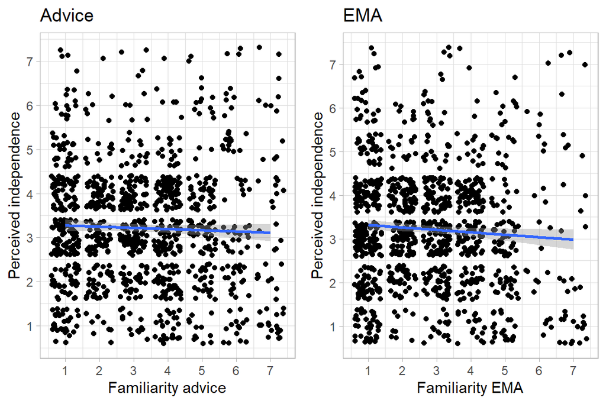

```r
p15 <-  df.def %>% ggplot(aes(familiarity.advice, perceived.independence.reversed)) + geom_jitter() + geom_smooth(method = "lm") + scale_x_continuous("Familiarity advice", breaks = 1:7) + scale_y_continuous("Perceived independence", breaks = 1:7) + labs(title = "Advice") + theme_light()

p16 <-  df.def %>% ggplot(aes(familiarity.EMA, perceived.independence.reversed)) + geom_jitter() + geom_smooth(method = "lm") + scale_x_continuous("Familiarity EMA", breaks = 1:7) + scale_y_continuous("Perceived independence", breaks = 1:7) + labs(title = "EMA") + theme_light()

ggarrange(p15, p16,
          ncol = 2,nrow = 1)
```

# 10 Remarks from participants

```r
df.total %>%
  filter(nchar(comments.general)>1) %>%
  select(comments.general) %>%
  kable() %>%
  kable_styling(bootstrap_options = "striped", full_width = F) %>%    scroll_box(height = "400px")
```

| comments.general |
| --- |
| Nej jag har inte finns några andra som har inte det är du har inte det jag har du ska inte finns någon |
| Inget speciellt |
| Nej |
| Nej tack |
| Nej |
| Intressant undersökning |
| Tack för en bra enkät! |
| Nej |
| Nej |
| Nej |
| Nej |
| Den var en bra undersökning. |
| Nej |
| Nej |
| nej |
| Nej, tack! |
| Nej |
| Nej |
| Nej |
| Jag tycker att det är konstigt att man hör så lite om modrrnas vaccin, det bara kom från ingenstans upplever jag. Inte hört nåt talas om det så mycket förutom att sverige skulle fördubbla kontraktet m… |
| Nej |
| Nej |
| Nej |
| Nej |
| Nej |
| En intressant och informativ undersökning. Tack |
| Nej |
| Bra enkät |
| Nej |
| Nej tack |

[output cut: 466 more lines]